# Adult WEBL provisioning behavior in heat

# Questions & Hypotheses

1. How do adult birds with active nests change their provisioning behavior during hot periods? We hypothesized that adult birds will
1. (H1) reduce their provisioning rates during hot periods because they must put more time and/or energy into thermoregulation to avoid hyperthermia and
2. (H2) maintain total provisioning visits by increasing visit rates during cooler hours of the day.
2. How does female body condition mediates provisioning We hypothesized that females in better condition (mass/tarsus) would be
1. (H1) less likely than females in worse condition to reduce their visits during hot periods because they are able to mobilize the energy required to engage in more energetically costly active thermoregulatory behaviors and
2. (H2) more likely than females in worse condition to maintain total provisioning visits by increasing visit rates during cooler hours of the day.
3. How does heat affect baseline and stress-induced? Elaborate Hp for baseline and stress-induced
1. H1: females that experienced heat over the prior day will be more likely to show elevated baseline corticosterone levels because they may upregulate their HPA axis in response to more challenging heat conditions
2. H2: females that experienced heat over the prior week will be more likely to show elevated stress-induced corticosterone levels because challenging environmental conditions are correlated with elevated stress-induced corticosterone levels.
4. Are provisioning rates affected by circulating CORT levels? We hypothesized that
1. (H1) females with elevated baseline corticosterone concentrations after a hot period would be more likely to maintain provisioning delivery to nestlings during following hot periods because they have the capacity to upregulate their HPA axis in response to environmental challenges (Mentesana and Hau 2022). Furthermore, we hypothesized that Look at this paper: https://besjournals.onlinelibrary.wiley.com/doi/full/10.1111/1365-2656.12843
2. Stress – induced levels? Please elaborate a Hp.
5. Does body condition mediate cort response?
1. (H1) females in better body condition would be more likely to show elevated baseline cort after a hot period because they have the energetic capacity to respond to stress
2. (H2) Females in better body condition would be less likely to show elevated stress-induced corticosterone after a hot period than females in worse body condition.

# Go through count model eval process

1. Fit poisson regression, check for overdispersion & zero-inflation

```r
m <- glmer(valid_detections ~ poly(mean_temp_scaled,2) + poly(tod_h_scaled,2) + mean_nestling_age_scaled + site + (1 | site:attempt_id) + year_fct,
           family = "poisson",
           data = dplyr::filter(p,!is.na(mean_temp),
                                  # !is.na(julian_date),
                                  !is.na(mean_nestling_age),
                                  !is.na(tod_h),
                                  !is.na(site),
                                  !is.na(attempt_id),
                                  !is.na(year),
                                  species == "WEBL"# ,
                                                # tod >= hms::as.hms('11:00:00', tz = "America/Los_Angeles"),
                                                # tod_end <= hms::as.hms('17:00:00',tz = "America/Los_Angeles"),
                                                # tod_end >= hms::as.hms('11:00:00', tz = "America/Los_Angeles")
                                                ) %>%
                        mutate(across(c(tod_h,mean_temp,julian_date,mean_nestling_age),
                                                    ~ scale(.x)[,1],
                                                    .names = "{.col}_scaled")),
           )
check_overdispersion(m)
```

```
## # Overdispersion test
##
##        dispersion ratio =    3.279
##   Pearson's Chi-Squared = 1000.001
##                 p-value =  < 0.001
```

```
## Overdispersion detected.
```

```r
check_zeroinflation(m)
```

```
## # Check for zero-inflation
##
##    Observed zeros: 45
##   Predicted zeros: 9
##             Ratio: 0.20
```

```
## Model is underfitting zeros (probable zero-inflation).
```

```r
m <- glmer(valid_detections ~ poly(mean_temp_scaled,2) + poly(tod_h_scaled,2) + mean_nestling_age_scaled + site + (1 | site:attempt_id) + year_fct,
           family = "poisson",
           data = dplyr::filter(p,!is.na(mean_temp),
                                  # !is.na(julian_date),
                                  !is.na(mean_nestling_age),
                                  !is.na(tod_h),
                                  !is.na(site),
                                  !is.na(attempt_id),
                                  !is.na(year),
                                  species == "TRES"# ,
                                                # tod >= hms::as.hms('11:00:00', tz = "America/Los_Angeles"),
                                                # tod_end <= hms::as.hms('17:00:00',tz = "America/Los_Angeles"),
                                                # tod_end >= hms::as.hms('11:00:00', tz = "America/Los_Angeles")
                                                ) %>%
                        mutate(across(c(tod_h,mean_temp,julian_date,mean_nestling_age),
                                                    ~ scale(.x)[,1],
                                                    .names = "{.col}_scaled")),
           )

check_overdispersion(m)
```

```
## # Overdispersion test
##
##        dispersion ratio =    6.345
##   Pearson's Chi-Squared = 1389.621
##                 p-value =  < 0.001
```

```
## Overdispersion detected.
```

```r
check_zeroinflation(m)
```

```
## # Check for zero-inflation
##
##    Observed zeros: 51
##   Predicted zeros: 11
##             Ratio: 0.22
```

```
## Model is underfitting zeros (probable zero-inflation).
```

2. There is both overdispersion & zero-inflation, so we need to use negative binomial model

```r
m <- glmmTMB(valid_detections ~ poly(mean_temp_scaled,2) + poly(tod_h_scaled,2) + mean_nestling_age_scaled + site + (1 | site:attempt_id) + year_fct,
           family = nbinom2(),
           data = dplyr::filter(p,!is.na(mean_temp),
                                  # !is.na(julian_date),
                                  !is.na(mean_nestling_age),
                                  !is.na(tod_h),
                                  !is.na(site),
                                  !is.na(attempt_id),
                                  !is.na(year),
                                  species == "WEBL"# ,
                                                # tod >= hms::as.hms('11:00:00', tz = "America/Los_Angeles"),
                                                # tod_end <= hms::as.hms('17:00:00',tz = "America/Los_Angeles"),
                                                # tod_end >= hms::as.hms('11:00:00', tz = "America/Los_Angeles")
                                                ) %>%
                        mutate(across(c(tod_h,mean_temp,julian_date,mean_nestling_age),
                                                    ~ scale(.x)[,1],
                                                    .names = "{.col}_scaled")),
           )

check_overdispersion(m)
```

```
## # Overdispersion test
##
##  dispersion ratio = 0.479
##           p-value =  0.32
```

```
## No overdispersion detected.
```

```r
check_zeroinflation(m)
```

```
## # Check for zero-inflation
##
##    Observed zeros: 45
##   Predicted zeros: 28
##             Ratio: 0.62
```

```
## Model is underfitting zeros (probable zero-inflation) (p = 0.048).
```

```r
m <- glmmTMB(valid_detections ~ poly(mean_temp_scaled,2) + poly(tod_h_scaled,2) + mean_nestling_age_scaled + site + (1 | site:attempt_id) + year_fct,
           family = nbinom2(),
           data = dplyr::filter(p,!is.na(mean_temp),
                                  # !is.na(julian_date),
                                  !is.na(mean_nestling_age),
                                  !is.na(tod_h),
                                  !is.na(site),
                                  !is.na(attempt_id),
                                  !is.na(year),
                                  species == "TRES"# ,
                                                # tod >= hms::as.hms('11:00:00', tz = "America/Los_Angeles"),
                                                # tod_end <= hms::as.hms('17:00:00',tz = "America/Los_Angeles"),
                                                # tod_end >= hms::as.hms('11:00:00', tz = "America/Los_Angeles")
                                                ) %>%
                        mutate(across(c(tod_h,mean_temp,julian_date,mean_nestling_age),
                                                    ~ scale(.x)[,1],
                                                    .names = "{.col}_scaled")),
           )

check_overdispersion(m)
```

```
## # Overdispersion test
##
##  dispersion ratio = 0.223
##           p-value = 0.104
```

```
## No overdispersion detected.
```

```r
check_zeroinflation(m)
```

```
## # Check for zero-inflation
##
##    Observed zeros: 51
##   Predicted zeros: 32
##             Ratio: 0.62
```

```
## Model is underfitting zeros (probable zero-inflation) (p = 0.032).
```

3. There is zero-inflation, so add zero-inflation factor to glmmTMB model

```r
m <- glmmTMB(valid_detections ~ poly(mean_temp_scaled,2) + poly(tod_h_scaled,2) + mean_nestling_age_scaled + site + (1|site:attempt_id) + year_fct,
           family = nbinom2(),
           ziformula = ~ attempt_id,
           data = dplyr::filter(p,!is.na(mean_temp),
                                  # !is.na(julian_date),
                                  !is.na(mean_nestling_age),
                                  !is.na(tod_h),
                                  !is.na(site),
                                  !is.na(attempt_id),
                                  !is.na(year),
                                  species == "WEBL"# ,
                                                # tod >= hms::as.hms('11:00:00', tz = "America/Los_Angeles"),
                                                # tod_end <= hms::as.hms('17:00:00',tz = "America/Los_Angeles"),
                                                # tod_end >= hms::as.hms('11:00:00', tz = "America/Los_Angeles")
                                                ) %>%
                        mutate(across(c(tod_h,mean_temp,julian_date,mean_nestling_age),
                                                    ~ scale(.x)[,1],
                                                    .names = "{.col}_scaled")),
           )

check_overdispersion(m)
```

```
## # Overdispersion test
##
##  dispersion ratio = 0.897
##           p-value = 0.736
```

```
## No overdispersion detected.
```

```r
check_zeroinflation(m)
```

```
## # Check for zero-inflation
##
##    Observed zeros: 45
##   Predicted zeros: 47
##             Ratio: 1.06
```

```
## Model seems ok, ratio of observed and predicted zeros is within the
##   tolerance range (p = 0.648).
```

```r
m <- glmmTMB(valid_detections ~ poly(mean_temp_scaled,2) + poly(tod_h_scaled,2) + mean_nestling_age_scaled + site + (1|site:attempt_id) + year_fct,
           family = nbinom2(),
           ziformula = ~ 1,
           data = dplyr::filter(p,!is.na(mean_temp),
                                  # !is.na(julian_date),
                                  !is.na(mean_nestling_age),
                                  !is.na(tod_h),
                                  !is.na(site),
                                  !is.na(attempt_id),
                                  !is.na(year),
                                  species == "TRES"# ,
                                                # tod >= hms::as.hms('11:00:00', tz = "America/Los_Angeles"),
                                                # tod_end <= hms::as.hms('17:00:00',tz = "America/Los_Angeles"),
                                                # tod_end >= hms::as.hms('11:00:00', tz = "America/Los_Angeles")
                                                ) %>%
                        mutate(across(c(tod_h,mean_temp,julian_date,mean_nestling_age),
                                                    ~ scale(.x)[,1],
                                                    .names = "{.col}_scaled")),
           )

check_overdispersion(m)
```

```
## # Overdispersion test
##
##  dispersion ratio = 0.512
##           p-value = 0.512
```

```
## No overdispersion detected.
```

```r
check_zeroinflation(m)
```

```
## # Check for zero-inflation
##
##    Observed zeros: 51
##   Predicted zeros: 49
##             Ratio: 0.96
```

```
## Model seems ok, ratio of observed and predicted zeros is within the
##   tolerance range (p = 0.840).
```

Conclusion: use glmmTMB, negative binomial, with zero-inflation factor attempt_id (assuming that some pairs are just more likely to not feed than other pairs)

# Question 1: How do adult birds with active nests change their provisioning behavior during hot periods?

## Hypothesis 1: We hypothesized that adults will reduce their provisioning rates during hot periods because they must put more time and/or energy into thermoregulation to avoid hyperthermia

Prediction: provis peaks at intermediate temp

### WEBL

```r
m_WEBL <- glmmTMB(valid_detections ~ poly(mean_temp_scaled,2) + poly(tod_h_scaled,2) + mean_nestling_age_scaled + brood_size_scaled + year_fct +  (1|site:attempt_id),
           family = nbinom2(),
           ziformula = ~ (1|site:attempt_id),
           data = dplyr::filter(p,!is.na(mean_temp),
                                  # !is.na(julian_date),
                                  !is.na(mean_nestling_age),
                                  !is.na(brood_size),
                                  !is.na(tod_h),
                                  !is.na(site),
                                  !is.na(attempt_id),
                                  !is.na(year_fct),
                                  species == "WEBL"# ,
                                                # tod >= hms::as.hms('11:00:00', tz = "America/Los_Angeles"),
                                                # tod_end <= hms::as.hms('17:00:00',tz = "America/Los_Angeles"),
                                                # tod_end >= hms::as.hms('11:00:00', tz = "America/Los_Angeles")
                                                ) %>%
                        mutate(across(c(tod_h,mean_temp,julian_date,mean_nestling_age,brood_size),
                                                    ~ scale(.x)[,1],
                                                    .names = "{.col}_scaled")),
           )

m_WEBL_notod <- glmmTMB(valid_detections ~ poly(mean_temp_scaled,2) + mean_nestling_age_scaled + brood_size_scaled + year_fct +  (1|site:attempt_id),
           family = nbinom2(),
           ziformula = ~ (1|site:attempt_id),
           data = dplyr::filter(p,!is.na(mean_temp),
                                  # !is.na(julian_date),
                                  !is.na(mean_nestling_age),
                                  !is.na(brood_size),
                                  !is.na(tod_h),
                                  !is.na(site),
                                  !is.na(attempt_id),
                                  !is.na(year_fct),
                                  species == "WEBL"# ,
                                                # tod >= hms::as.hms('11:00:00', tz = "America/Los_Angeles"),
                                                # tod_end <= hms::as.hms('17:00:00',tz = "America/Los_Angeles"),
                                                # tod_end >= hms::as.hms('11:00:00', tz = "America/Los_Angeles")
                                                ) %>%
                        mutate(across(c(tod_h,mean_temp,julian_date,mean_nestling_age,brood_size),
                                                    ~ scale(.x)[,1],
                                                    .names = "{.col}_scaled")),
           )

# m_WEBL_linint <- glmmTMB(valid_detections ~ mean_temp_scaled * habitat + poly(mean_temp_scaled,degree = 2) + poly(tod_h_scaled,2) + mean_nestling_age_scaled + brood_size_scaled + year_fct + (1|site:attempt_id),
#            family = nbinom2(),
#            ziformula = ~ (1|attempt_id),
#            data = dplyr::filter(p,!is.na(mean_temp),
#                                 # !is.na(julian_date),
#                                 !is.na(mean_nestling_age),
#                                 !is.na(brood_size),
#                                 !is.na(tod_h),
#                                 !is.na(site),
#                                 !is.na(attempt_id),
#                                 !is.na(year),
#                                 species == "WEBL"# ,
#                                               # tod >= hms::as.hms('11:00:00', tz = "America/Los_Angeles"),
#                                               # tod_end <= hms::as.hms('17:00:00',tz = "America/Los_Angeles"),
#                                               # tod_end >= hms::as.hms('11:00:00', tz = "America/Los_Angeles")
#                                               ) %>%
#                       mutate(across(c(tod_h,mean_temp,julian_date,mean_nestling_age,brood_size),
#                                                   ~ scale(.x)[,1],
#                                                   .names = "{.col}_scaled")),
#            )
#
# m_WEBL_noint <- glmmTMB(valid_detections ~ habitat + poly(mean_temp_scaled,degree = 2) + poly(tod_h_scaled,2) + mean_nestling_age_scaled + brood_size_scaled + year_fct + (1|site:attempt_id),
#            family = nbinom2(),
#            ziformula = ~ (1|attempt_id),
#            data = dplyr::filter(p,!is.na(mean_temp),
#                                 # !is.na(julian_date),
#                                 !is.na(mean_nestling_age),
#                                 !is.na(brood_size),
#                                 !is.na(tod_h),
#                                 !is.na(site),
#                                 !is.na(attempt_id),
#                                 !is.na(year),
#                                 species == "WEBL"# ,
#                                               # tod >= hms::as.hms('11:00:00', tz = "America/Los_Angeles"),
#                                               # tod_end <= hms::as.hms('17:00:00',tz = "America/Los_Angeles"),
#                                               # tod_end >= hms::as.hms('11:00:00', tz = "America/Los_Angeles")
#                                               ) %>%
#                       mutate(across(c(tod_h,mean_temp,julian_date,mean_nestling_age,brood_size),
#                                                   ~ scale(.x)[,1],
#                                                   .names = "{.col}_scaled")),
#            )




c <- anova(m_WEBL,m_WEBL_notod) %>% tibble() %>% mutate(Model = c("No time of day term","Squared time of day term"),.before = Df)

(tab <- c %>%
  as.tibble() %>%
  mutate(across(where(is.numeric),~round(.x,digits = 4)),
         P = `Pr(>Chisq)`) %>%
  dplyr::select(Model,AIC,Chisq,P) %>%
  mutate(across(c(AIC,Chisq), ~ round(.x, digits = 2)),
         P = if_else(P < 0.001,"<0.001",as.character(P))) %>% gt())
```

| Model | AIC | Chisq | P |
| --- | --- | --- | --- |
| No time of day term | 1857.66 | NA | NA |
| Squared time of day term | 1858.29 | 3.37 | 0.1856 |

```r
gtsave(tab,"../figures/int_tab_provis_ch3_webl.html")

summary(m_WEBL_notod)
```

```
##  Family: nbinom2  ( log )
## Formula:
## valid_detections ~ poly(mean_temp_scaled, 2) + mean_nestling_age_scaled +
##     brood_size_scaled + year_fct + (1 | site:attempt_id)
## Zero inflation:                    ~(1 | site:attempt_id)
## Data: dplyr::filter(p, !is.na(mean_temp), !is.na(mean_nestling_age),
##     !is.na(brood_size), !is.na(tod_h), !is.na(site), !is.na(attempt_id),
##     !is.na(year_fct), species == "WEBL") %>% mutate(across(c(tod_h,
##     mean_temp, julian_date, mean_nestling_age, brood_size), ~scale(.x)[,
##     1], .names = "{.col}_scaled"))
##
##      AIC      BIC   logLik deviance df.resid
##   1857.7   1899.0   -917.8   1835.7      306
##
## Random effects:
##
## Conditional model:
##  Groups          Name        Variance Std.Dev.
##  site:attempt_id (Intercept) 0.1781   0.422
## Number of obs: 317, groups:  site:attempt_id, 29
##
## Zero-inflation model:
##  Groups          Name        Variance Std.Dev.
##  site:attempt_id (Intercept) 4.826    2.197
## Number of obs: 317, groups:  site:attempt_id, 29
##
## Dispersion parameter for nbinom2 family (): 4.57
##
## Conditional model:
##                            Estimate Std. Error z value Pr(>|z|)
## (Intercept)                 2.39538    0.34065   7.032 2.04e-12 ***
## poly(mean_temp_scaled, 2)1 -1.76929    0.88460  -2.000   0.0455 *
## poly(mean_temp_scaled, 2)2 -0.13693    0.78543  -0.174   0.8616
## mean_nestling_age_scaled    0.21471    0.04693   4.575 4.76e-06 ***
## brood_size_scaled           0.14887    0.11171   1.333   0.1827
## year_fct2022               -0.36480    0.38199  -0.955   0.3396
## year_fct2023               -0.48220    0.37589  -1.283   0.1996
## ---
## Signif. codes:  0 '***' 0.001 '**' 0.01 '*' 0.05 '.' 0.1 ' ' 1
##
## Zero-inflation model:
##             Estimate Std. Error z value Pr(>|z|)
## (Intercept)  -3.0958     0.6914  -4.478 7.55e-06 ***
## ---
## Signif. codes:  0 '***' 0.001 '**' 0.01 '*' 0.05 '.' 0.1 ' ' 1
```

```r
m_webl_q1h1 <- m_WEBL_notod

check_zeroinflation(m_WEBL_notod)
```

```
## # Check for zero-inflation
##
##    Observed zeros: 45
##   Predicted zeros: 50
##             Ratio: 1.10
```

[output not shown]

```r
# (t <- emtrends(m_webl_q1h1,specs = ~ habitat, var = c("mean_temp_scaled"),max.degree = 1) %>% test() %>%
#    mutate(across(where(is.numeric), ~ round(.x, digits = 3)),
#           df = round(df),
#           p.value = if_else(p.value == 0.000,"<0.001",as.character(p.value))) %>%
#    rename(Habitat = "habitat", `Max temp trend` = "mean_temp_scaled.trend",Df = "df", `Z-ratio` = "z.ratio", P = "p.value") %>%
#    #group_by(degree) %>%
#    gt())

ss_year_webl_provis <- m_webl_q1h1$frame %>%
  group_by(year_fct) %>%
  summarize(count_ind = n(),count_attempt = n_distinct(attempt_id)) %>%
  rowwise() %>%
  mutate(count = tibble(count_ind,count_attempt)) %>%
  dplyr::select(-c(count_ind, count_attempt)) %>%
  pivot_wider(values_from = count,names_from = year_fct) %>%
  as.tibble() %>% # rename(Habitat = 'habitat') %>%
  ungroup() %>%
  mutate(`2021` = replace_na(`2021`,list(count_ind = 0,count_attempt = 0))) %>%
  mutate(Total = `2021` + `2022` + `2023`) %>%
  rowwise() %>%
  mutate(`2021` = paste0(`2021`$count_ind,", ",`2021`$count_attempt),
         `2022` = paste0(`2022`$count_ind,", ",`2022`$count_attempt),
         `2023` = paste0(`2023`$count_ind,", ",`2023`$count_attempt),
         Total = paste0(Total$count_ind,", ",Total$count_attempt)
  )

(t_ss_year_webl_provis <- ss_year_webl_provis %>% gt() %>%
    grand_summary_rows(fns = list(id = "Total") ~ {
      t <- str_split(.,", ",simplify = TRUE)
      t[,1] %>% as.numeric() %>% sum(na.rm = TRUE) %>% paste(t[,2] %>% as.numeric() %>% sum(na.rm = TRUE),sep = ", ")
    })
)
```

|  | 2021 | 2022 | 2023 | Total |
| --- | --- | --- | --- | --- |
|  | 21, 3 | 153, 12 | 143, 14 | 317, 29 |
| Total | 21, 3 | 153, 12 | 143, 14 | 317, 29 |

```r
t_ss_year_webl_provis %>% gtsave("../figures/ss_year_webl_provis_ch3.html")

samp <- m_webl_q1h1$frame %>% summarize(count = n())
samp %>% gt() %>% gtsave("../figures/ss_webl_provis_ch3.html")


dat_text_webl_q1h1 <- data.frame(
  label = paste("N =",samp$count)# ,
  #group   = factor(c("Forest","Orchard","Grassland","Row crop"))
)

## num nestboxes
m_webl_q1h1$frame %>% pull(attempt_id) %>% unique() %>% length()
```

```
## [1] 29
```

```
## You are calculating adjusted predictions on the population-level (i.e.
##   `type = "fixed"`) for a *generalized* linear mixed model.
##   This may produce biased estimates due to Jensen's inequality. Consider
##   setting `bias_correction = TRUE` to correct for this bias.
##   See also the documentation of the `bias_correction` argument.
```

```
## Data points may overlap. Use the `jitter` argument to add some amount of
##   random variation to the location of data points and avoid overplotting.
```

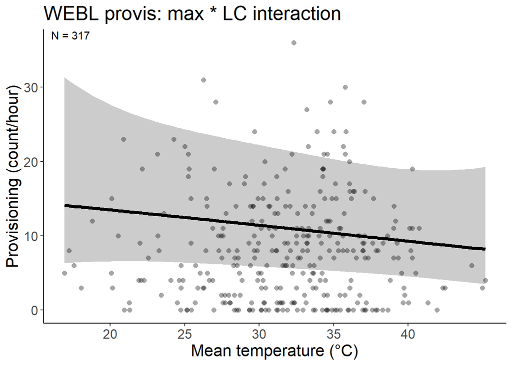

```r
data_webl_q1h1 = dplyr::filter(p,!is.na(mean_temp),
                                  # !is.na(julian_date),
                                  !is.na(mean_nestling_age),
                                  !is.na(brood_size),
                                  !is.na(tod_h),
                                  !is.na(site),
                                  !is.na(attempt_id),
                                  !is.na(year),
                                  species == "WEBL"# ,
                                                # tod >= hms::as.hms('11:00:00', tz = "America/Los_Angeles"),
                                                # tod_end <= hms::as.hms('17:00:00',tz = "America/Los_Angeles"),
                                                # tod_end >= hms::as.hms('11:00:00', tz = "America/Los_Angeles")
                                                ) %>%
                        mutate(across(c(tod_h,mean_temp,julian_date,mean_nestling_age,brood_size),
                                                    ~ scale(.x)[,1],
                                                    .names = "{.col}_scaled"))


mean_temp_webl_q1h1 <- mean(data_webl_q1h1 %>% pull(mean_temp))
sd_temp_webl_q1h1 <- sd(data_webl_q1h1 %>% pull(mean_temp))


temp_trans_webl_q1h1 <- trans_new("temp_trans_webl_q1h1",
                             transform = function(x){(x * sd_temp_webl_q1h1) + mean_temp_webl_q1h1},
                             inverse = function(x){x})

(figq1h1_webl <- predict_response(m_webl_q1h1,terms = c("mean_temp_scaled [all]")) %>%
    plot(line_size = 1.5,alpha = .2,show_data = TRUE,limit_range = TRUE) +
    aes(linetype = .data[["group"]]) +
    theme_classic() +
    # facet_wrap(~ group, ncol = 2) +
    xlab("Mean temperature (\u00b0C)") +
    ylab("Provisioning (count/hour)") +
    scale_fill_viridis(discrete = TRUE) +
    scale_color_viridis(discrete = TRUE) +
    theme(text = element_text(size = 16)) +
    labs(title =  "WEBL provis: max * LC interaction") +
    scale_x_continuous(trans = temp_trans_webl_q1h1,
                       breaks = c((20-mean_temp_webl_q1h1)/sd_temp_webl_q1h1,
                                  (25-mean_temp_webl_q1h1)/sd_temp_webl_q1h1,
                                  (30-mean_temp_webl_q1h1)/sd_temp_webl_q1h1,
                                  (35-mean_temp_webl_q1h1)/sd_temp_webl_q1h1,
                                  (40-mean_temp_webl_q1h1)/sd_temp_webl_q1h1),
                       # breaks = c(20,30,40,50),
                       # labels = c("20","30","40","50"),
                       # limits = c((15-mean(g$meanmaxtempI,na.rm = TRUE))/sd(g$meanmaxtempI,na.rm = TRUE),
                       #            (55-mean(g$meanmaxtempI,na.rm = TRUE))/sd(g$meanmaxtempI,na.rm = TRUE))
                       # limits = c(18,5)
    ) +
    scale_linetype_manual(values = "solid") +
    #ylim(-5,5) +
    geom_text(data = dat_text_webl_q1h1, mapping = aes(x = -Inf, y = Inf,label = label),hjust = -.2, vjust = 1.2,inherit.aes = FALSE) +
    theme(legend.position = "none")
)
```

```r
ggsave("../figures/provisbymaxtempxhab_WEBL_q1h1.png",plot =  figq1h1_webl, width = 10, height = 6.6)
```

Another question out of this is, are the adults responding to their own physiological state or are they responding to nestlings’ condition? The tough part is that I could imagine that they’re responding to nestlings’ begging behavior. Does begging behavior peak at some intermediate condition (i.e. when nestlings are really hungry but not yet weakened by it), or is it strongest when nestlings are fed well?

From the reading, it looks like what we should expect is that in resource-poor environments (i.e. agriculture), provisioning should respond to quality of nestlings, whereas in resource-poor environments, provisioning should respond to need of nestlings. But also, in the short term, nestling begging rate is driven by hunger, and generally reduced in small nestlings in large broods.

### TRES

```r
m_TRES <- glmmTMB(valid_detections ~ poly(mean_temp_scaled,2) + poly(tod_h_scaled,2) + mean_nestling_age_scaled + brood_size_scaled + year_fct +  (1|site:attempt_id),
           family = nbinom2(),
           ziformula = ~ (1|site:attempt_id),
           data = dplyr::filter(p,!is.na(mean_temp),
                                  # !is.na(julian_date),
                                  !is.na(mean_nestling_age),
                                  !is.na(brood_size),
                                  !is.na(tod_h),
                                  !is.na(site),
                                  !is.na(attempt_id),
                                  !is.na(year_fct),
                                  species == "TRES"# ,
                                                # tod >= hms::as.hms('11:00:00', tz = "America/Los_Angeles"),
                                                # tod_end <= hms::as.hms('17:00:00',tz = "America/Los_Angeles"),
                                                # tod_end >= hms::as.hms('11:00:00', tz = "America/Los_Angeles")
                                                ) %>%
                        mutate(across(c(tod_h,mean_temp,julian_date,mean_nestling_age,brood_size),
                                                    ~ scale(.x)[,1],
                                                    .names = "{.col}_scaled")),
           )

m_TRES_notod <- glmmTMB(valid_detections ~ poly(mean_temp_scaled,2) + mean_nestling_age_scaled + brood_size_scaled + year_fct +  (1|site:attempt_id),
           family = nbinom2(),
           ziformula = ~ (1|site:attempt_id),
           data = dplyr::filter(p,!is.na(mean_temp),
                                  # !is.na(julian_date),
                                  !is.na(mean_nestling_age),
                                  !is.na(brood_size),
                                  !is.na(tod_h),
                                  !is.na(site),
                                  !is.na(attempt_id),
                                  !is.na(year_fct),
                                  species == "TRES"# ,
                                                # tod >= hms::as.hms('11:00:00', tz = "America/Los_Angeles"),
                                                # tod_end <= hms::as.hms('17:00:00',tz = "America/Los_Angeles"),
                                                # tod_end >= hms::as.hms('11:00:00', tz = "America/Los_Angeles")
                                                ) %>%
                        mutate(across(c(tod_h,mean_temp,julian_date,mean_nestling_age,brood_size),
                                                    ~ scale(.x)[,1],
                                                    .names = "{.col}_scaled")),
           )

# m_TRES_linint <- glmmTMB(valid_detections ~ mean_temp_scaled * habitat + poly(mean_temp_scaled,degree = 2) + poly(tod_h_scaled,2) + mean_nestling_age_scaled + brood_size_scaled + year_fct + (1|site:attempt_id),
#            family = nbinom2(),
#            ziformula = ~ (1|attempt_id),
#            data = dplyr::filter(p,!is.na(mean_temp),
#                                 # !is.na(julian_date),
#                                 !is.na(mean_nestling_age),
#                                 !is.na(brood_size),
#                                 !is.na(tod_h),
#                                 !is.na(site),
#                                 !is.na(attempt_id),
#                                 !is.na(year),
#                                 species == "TRES"# ,
#                                               # tod >= hms::as.hms('11:00:00', tz = "America/Los_Angeles"),
#                                               # tod_end <= hms::as.hms('17:00:00',tz = "America/Los_Angeles"),
#                                               # tod_end >= hms::as.hms('11:00:00', tz = "America/Los_Angeles")
#                                               ) %>%
#                       mutate(across(c(tod_h,mean_temp,julian_date,mean_nestling_age,brood_size),
#                                                   ~ scale(.x)[,1],
#                                                   .names = "{.col}_scaled")),
#            )
#
# m_TRES_noint <- glmmTMB(valid_detections ~ habitat + poly(mean_temp_scaled,degree = 2) + poly(tod_h_scaled,2) + mean_nestling_age_scaled + brood_size_scaled + year_fct + (1|site:attempt_id),
#            family = nbinom2(),
#            ziformula = ~ (1|attempt_id),
#            data = dplyr::filter(p,!is.na(mean_temp),
#                                 # !is.na(julian_date),
#                                 !is.na(mean_nestling_age),
#                                 !is.na(brood_size),
#                                 !is.na(tod_h),
#                                 !is.na(site),
#                                 !is.na(attempt_id),
#                                 !is.na(year),
#                                 species == "TRES"# ,
#                                               # tod >= hms::as.hms('11:00:00', tz = "America/Los_Angeles"),
#                                               # tod_end <= hms::as.hms('17:00:00',tz = "America/Los_Angeles"),
#                                               # tod_end >= hms::as.hms('11:00:00', tz = "America/Los_Angeles")
#                                               ) %>%
#                       mutate(across(c(tod_h,mean_temp,julian_date,mean_nestling_age,brood_size),
#                                                   ~ scale(.x)[,1],
#                                                   .names = "{.col}_scaled")),
#            )




c <- anova(m_TRES,m_TRES_notod) %>% tibble() %>% mutate(Model = c("No time of day term","Squared time of day term"),.before = Df)

(tab <- c %>%
  as.tibble() %>%
  mutate(across(where(is.numeric),~round(.x,digits = 4)),
         P = `Pr(>Chisq)`) %>%
  dplyr::select(Model,AIC,Chisq,P) %>%
  mutate(across(c(AIC,Chisq), ~ round(.x, digits = 2)),
         P = if_else(P < 0.001,"<0.001",as.character(P))) %>% gt())
```

| Model | AIC | Chisq | P |
| --- | --- | --- | --- |
| No time of day term | 1502.87 | NA | NA |
| Squared time of day term | 1499.71 | 7.15 | 0.028 |

```r
gtsave(tab,"../figures/int_tab_provis_ch3_tres.html")

summary(m_TRES)
```

```
##  Family: nbinom2  ( log )
## Formula:
## valid_detections ~ poly(mean_temp_scaled, 2) + poly(tod_h_scaled,
##     2) + mean_nestling_age_scaled + brood_size_scaled + year_fct +
##     (1 | site:attempt_id)
## Zero inflation:                    ~(1 | site:attempt_id)
## Data: dplyr::filter(p, !is.na(mean_temp), !is.na(mean_nestling_age),
##     !is.na(brood_size), !is.na(tod_h), !is.na(site), !is.na(attempt_id),
##     !is.na(year_fct), species == "TRES") %>% mutate(across(c(tod_h,
##     mean_temp, julian_date, mean_nestling_age, brood_size), ~scale(.x)[,
##     1], .names = "{.col}_scaled"))
##
##      AIC      BIC   logLik deviance df.resid
##   1499.7   1544.5   -736.9   1473.7      218
##
## Random effects:
##
## Conditional model:
##  Groups          Name        Variance Std.Dev.
##  site:attempt_id (Intercept) 0.2058   0.4537
## Number of obs: 231, groups:  site:attempt_id, 23
##
## Zero-inflation model:
##  Groups          Name        Variance Std.Dev.
##  site:attempt_id (Intercept) 3.985    1.996
## Number of obs: 231, groups:  site:attempt_id, 23
##
## Dispersion parameter for nbinom2 family (): 3.37
##
## Conditional model:
##                            Estimate Std. Error z value Pr(>|z|)
## (Intercept)                 2.62996    0.23365  11.256  < 2e-16 ***
## poly(mean_temp_scaled, 2)1  5.93888    1.66099   3.575  0.00035 ***
## poly(mean_temp_scaled, 2)2 -1.77555    0.91846  -1.933  0.05321 .
## poly(tod_h_scaled, 2)1      0.98665    0.80486   1.226  0.22025
## poly(tod_h_scaled, 2)2      2.39314    1.15884   2.065  0.03891 *
## mean_nestling_age_scaled   -0.01391    0.07273  -0.191  0.84829
## brood_size_scaled           0.29801    0.15060   1.979  0.04784 *
## year_fct2022                0.10218    0.37370   0.273  0.78453
## year_fct2023               -0.32976    0.30153  -1.094  0.27412
## ---
## Signif. codes:  0 '***' 0.001 '**' 0.01 '*' 0.05 '.' 0.1 ' ' 1
##
## Zero-inflation model:
##             Estimate Std. Error z value Pr(>|z|)
## (Intercept)  -2.2349     0.6162  -3.627 0.000287 ***
## ---
## Signif. codes:  0 '***' 0.001 '**' 0.01 '*' 0.05 '.' 0.1 ' ' 1
```

```r
m_tres_q1h1 <- m_TRES

check_zeroinflation(m_TRES)
```

```
## # Check for zero-inflation
##
##    Observed zeros: 51
##   Predicted zeros: 51
##             Ratio: 1.00
```

```
## Model seems ok, ratio of observed and predicted zeros is within the
##   tolerance range (p = 0.904).
```

```r
# (t <- emtrends(m_tres_q1h1,specs = ~ habitat, var = c("mean_temp_scaled"),max.degree = 1) %>% test() %>%
#    mutate(across(where(is.numeric), ~ round(.x, digits = 3)),
#           df = round(df),
#           p.value = if_else(p.value == 0.000,"<0.001",as.character(p.value))) %>%
#    rename(Habitat = "habitat", `Max temp trend` = "mean_temp_scaled.trend",Df = "df", `Z-ratio` = "z.ratio", P = "p.value") %>%
#    #group_by(degree) %>%
#    gt())

ss_year_tres_provis <- m_tres_q1h1$frame %>%
  group_by(year_fct) %>%
  summarize(count_ind = n(),count_attempt = n_distinct(attempt_id)) %>%
  rowwise() %>%
  mutate(count = tibble(count_ind,count_attempt)) %>%
  dplyr::select(-c(count_ind, count_attempt)) %>%
  pivot_wider(values_from = count,names_from = year_fct) %>%
  as.tibble() %>% # rename(Habitat = 'habitat') %>%
  ungroup() %>%
  mutate(`2021` = replace_na(`2021`,list(count_ind = 0,count_attempt = 0))) %>%
  mutate(Total = `2021` + `2022` + `2023`) %>%
  rowwise() %>%
  mutate(`2021` = paste0(`2021`$count_ind,", ",`2021`$count_attempt),
         `2022` = paste0(`2022`$count_ind,", ",`2022`$count_attempt),
         `2023` = paste0(`2023`$count_ind,", ",`2023`$count_attempt),
         Total = paste0(Total$count_ind,", ",Total$count_attempt)
  )

(t_ss_year_tres_provis <- ss_year_tres_provis %>% gt() %>%
    grand_summary_rows(fns = list(id = "Total") ~ {
      t <- str_split(.,", ",simplify = TRUE)
      t[,1] %>% as.numeric() %>% sum(na.rm = TRUE) %>% paste(t[,2] %>% as.numeric() %>% sum(na.rm = TRUE),sep = ", ")
    })
)
```

|  | 2021 | 2022 | 2023 | Total |
| --- | --- | --- | --- | --- |
|  | 64, 7 | 75, 7 | 92, 9 | 231, 23 |
| Total | 64, 7 | 75, 7 | 92, 9 | 231, 23 |

```r
t_ss_year_tres_provis %>% gtsave("../figures/ss_year_tres_provis_ch3.html")

samp <- m_tres_q1h1$frame %>% summarize(count = n())
samp %>% gt() %>% gtsave("../figures/ss_tres_provis_ch3.html")


dat_text_tres_q1h1 <- data.frame(
  label = paste("N =",samp$count)# ,
  #group   = factor(c("Forest","Orchard","Grassland","Row crop"))
)

## num nestboxes
m_tres_q1h1$frame %>% pull(attempt_id) %>% unique() %>% length()
```

```
## [1] 23
```

```
## Data points may overlap. Use the `jitter` argument to add some amount of
##   random variation to the location of data points and avoid overplotting.
```

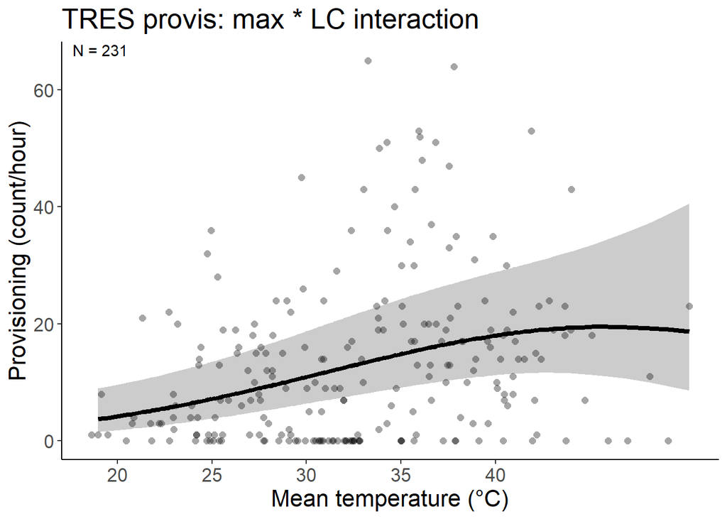

```r
data_tres_q1h1 = dplyr::filter(p,!is.na(mean_temp),
                                  # !is.na(julian_date),
                                  !is.na(mean_nestling_age),
                                  !is.na(brood_size),
                                  !is.na(tod_h),
                                  !is.na(site),
                                  !is.na(attempt_id),
                                  !is.na(year),
                                  species == "TRES"# ,
                                                # tod >= hms::as.hms('11:00:00', tz = "America/Los_Angeles"),
                                                # tod_end <= hms::as.hms('17:00:00',tz = "America/Los_Angeles"),
                                                # tod_end >= hms::as.hms('11:00:00', tz = "America/Los_Angeles")
                                                ) %>%
                        mutate(across(c(tod_h,mean_temp,julian_date,mean_nestling_age,brood_size),
                                                    ~ scale(.x)[,1],
                                                    .names = "{.col}_scaled"))


mean_temp_tres_q1h1 <- mean(data_tres_q1h1 %>% pull(mean_temp))
sd_temp_tres_q1h1 <- sd(data_tres_q1h1 %>% pull(mean_temp))


temp_trans_tres_q1h1 <- trans_new("temp_trans_tres_q1h1",
                             transform = function(x){(x * sd_temp_tres_q1h1) + mean_temp_tres_q1h1},
                             inverse = function(x){x})

(figq1h1_tres <- predict_response(m_tres_q1h1,terms = c("mean_temp_scaled [all]")) %>%
    plot(line_size = 1.5,alpha = .2,show_data = TRUE,limit_range = TRUE) +
    aes(linetype = .data[["group"]]) +
    theme_classic() +
    # facet_wrap(~ group, ncol = 2) +
    xlab("Mean temperature (\u00b0C)") +
    ylab("Provisioning (count/hour)") +
    scale_fill_viridis(discrete = TRUE) +
    scale_color_viridis(discrete = TRUE) +
    theme(text = element_text(size = 16)) +
    labs(title =  "TRES provis: max * LC interaction") +
    scale_x_continuous(trans = temp_trans_tres_q1h1,
                       breaks = c((20-mean_temp_tres_q1h1)/sd_temp_tres_q1h1,
                                  (25-mean_temp_tres_q1h1)/sd_temp_tres_q1h1,
                                  (30-mean_temp_tres_q1h1)/sd_temp_tres_q1h1,
                                  (35-mean_temp_tres_q1h1)/sd_temp_tres_q1h1,
                                  (40-mean_temp_tres_q1h1)/sd_temp_tres_q1h1),
                       # breaks = c(20,30,40,50),
                       # labels = c("20","30","40","50"),
                       # limits = c((15-mean(g$meanmaxtempI,na.rm = TRUE))/sd(g$meanmaxtempI,na.rm = TRUE),
                       #            (55-mean(g$meanmaxtempI,na.rm = TRUE))/sd(g$meanmaxtempI,na.rm = TRUE))
                       # limits = c(18,5)
    ) +
    scale_linetype_manual(values = "solid") +
    #ylim(-5,5) +
    geom_text(data = dat_text_tres_q1h1, mapping = aes(x = -Inf, y = Inf,label = label),hjust = -.2, vjust = 1.2,inherit.aes = FALSE) +
    theme(legend.position = "none")
)
```

```r
ggsave("../figures/provisbymaxtempxhab_TRES_q1h1.png",plot =  figq1h1_tres, width = 10, height = 6.6)
```

So WEBL decrease provis with temp and TRES increase provis with temp.

## Q1H2

How do adult birds with active nests change their provisioning behavior during hot periods? We hypothesized that adult birds will

2. (H2) I’d expect provisioning to be “peakier” during the present day (more focused on ideal temps) if the prior day had more ideal temps provis ~ priordaytempgoodness + tnow^2

```r
p <- read_rds("../data/provis_manytempmeasures.rds")
```

## WEBL

```r
m_WEBL <- glmmTMB(valid_detections ~ poly(mean_temp_scaled,2) * deghours_diff_35C_priorday_scaled + poly(tod_h_scaled,2) + mean_nestling_age_scaled + brood_size_scaled + year_fct +  (1|site:attempt_id),
           family = nbinom2(),
           ziformula = ~ attempt_id,
           data = dplyr::filter(p,!is.na(mean_temp),
                                  # !is.na(julian_date),
                                  !is.na(mean_nestling_age),
                                  !is.na(deghours_diff_35C_priorday),
                                  !is.na(brood_size),
                                  !is.na(tod_h),
                                  !is.na(site),
                                  !is.na(attempt_id),
                                  !is.na(year_fct),
                                  species == "WEBL"# ,
                                                # tod >= hms::as.hms('11:00:00', tz = "America/Los_Angeles"),
                                                # tod_end <= hms::as.hms('17:00:00',tz = "America/Los_Angeles"),
                                                # tod_end >= hms::as.hms('11:00:00', tz = "America/Los_Angeles")
                                                ) %>%
                        mutate(across(c(tod_h,mean_temp,deghours_diff_35C_priorday,julian_date,mean_nestling_age,brood_size),
                                                    ~ scale(.x)[,1],
                                                    .names = "{.col}_scaled")),
           )

summary(m_WEBL)
```

```
##  Family: nbinom2  ( log )
## Formula:
## valid_detections ~ poly(mean_temp_scaled, 2) * deghours_diff_35C_priorday_scaled +
##     poly(tod_h_scaled, 2) + mean_nestling_age_scaled + brood_size_scaled +
##     year_fct + (1 | site:attempt_id)
## Zero inflation:                    ~attempt_id
## Data: dplyr::filter(p, !is.na(mean_temp), !is.na(mean_nestling_age),
##     !is.na(deghours_diff_35C_priorday), !is.na(brood_size), !is.na(tod_h),
##     !is.na(site), !is.na(attempt_id), !is.na(year_fct), species ==
##         "WEBL") %>% mutate(across(c(tod_h, mean_temp, deghours_diff_35C_priorday,
##     julian_date, mean_nestling_age, brood_size), ~scale(.x)[,
##     1], .names = "{.col}_scaled"))
##
##      AIC      BIC   logLik deviance df.resid
##   1857.8   2019.4   -885.9   1771.8      274
##
## Random effects:
##
## Conditional model:
##  Groups          Name        Variance Std.Dev.
##  site:attempt_id (Intercept) 0.1816   0.4261
## Number of obs: 317, groups:  site:attempt_id, 29
##
## Dispersion parameter for nbinom2 family ():  5.1
##
## Conditional model:
##                                                              Estimate
## (Intercept)                                                   2.35749
## poly(mean_temp_scaled, 2)1                                   -0.30461
## poly(mean_temp_scaled, 2)2                                   -1.24787
## deghours_diff_35C_priorday_scaled                            -0.04831
## poly(tod_h_scaled, 2)1                                        0.02754
## poly(tod_h_scaled, 2)2                                        1.74933
## mean_nestling_age_scaled                                      0.19466
## brood_size_scaled                                             0.12949
## year_fct2022                                                 -0.36366
## year_fct2023                                                 -0.46872
## poly(mean_temp_scaled, 2)1:deghours_diff_35C_priorday_scaled -2.21005
## poly(mean_temp_scaled, 2)2:deghours_diff_35C_priorday_scaled  0.23732
##                                                              Std. Error z value
```

[output cut: 46 more lines]

```
## attempt_id2023_BRO6_1   -2.914e-01  1.538e+00  -0.189  0.84977
## attempt_id2023_MBNG14_1 -1.873e+01  1.010e+04  -0.002  0.99852
## attempt_id2023_PCC8_1   -2.100e+01  1.047e+04  -0.002  0.99840
## attempt_id2023_PCC8_2    2.580e-01  1.427e+00   0.181  0.85655
## attempt_id2023_PCC9_1   -7.088e-01  7.890e-01  -0.898  0.36900
## attempt_id2023_PICG7_1  -2.995e+00  1.639e+00  -1.827  0.06776 .
## attempt_id2023_PICO1_2  -2.150e+01  1.169e+04  -0.002  0.99853
## attempt_id2023_PICO13_1 -2.067e+00  1.016e+00  -2.034  0.04192 *
## attempt_id2023_PICO4_1  -1.873e+01  1.010e+04  -0.002  0.99852
## attempt_id2023_PICR10_1 -1.839e+01  6.030e+03  -0.003  0.99757
## attempt_id2023_RRRR3_1  -2.661e+00  9.637e-01  -2.761  0.00577 **
## attempt_id2023_RRRR8_1  -2.136e+01  1.136e+04  -0.002  0.99850
## attempt_id2023_RRRR8_2  -2.119e+01  1.095e+04  -0.002  0.99846
## ---
## Signif. codes:  0 '***' 0.001 '**' 0.01 '*' 0.05 '.' 0.1 ' ' 1
```

```r
m_webl_q1h2 <- m_WEBL

check_zeroinflation(m_WEBL)
```

```
## # Check for zero-inflation
##
##    Observed zeros: 45
##   Predicted zeros: 48
##             Ratio: 1.07
```

```
## Model seems ok, ratio of observed and predicted zeros is within the
##   tolerance range (p = 0.600).
```

```r
# (t <- emtrends(m_webl_q1h1,specs = ~ habitat, var = c("mean_temp_scaled"),max.degree = 1) %>% test() %>%
#    mutate(across(where(is.numeric), ~ round(.x, digits = 3)),
#           df = round(df),
#           p.value = if_else(p.value == 0.000,"<0.001",as.character(p.value))) %>%
#    rename(Habitat = "habitat", `Max temp trend` = "mean_temp_scaled.trend",Df = "df", `Z-ratio` = "z.ratio", P = "p.value") %>%
#    #group_by(degree) %>%
#    gt())

ss_year_webl_provis_q1h2 <- m_webl_q1h2$frame %>%
  group_by(year_fct) %>%
  summarize(count_ind = n(),count_attempt = n_distinct(attempt_id)) %>%
  rowwise() %>%
  mutate(count = tibble(count_ind,count_attempt)) %>%
  dplyr::select(-c(count_ind, count_attempt)) %>%
  pivot_wider(values_from = count,names_from = year_fct) %>%
  as.tibble() %>% # rename(Habitat = 'habitat') %>%
  ungroup() %>%
  mutate(`2021` = replace_na(`2021`,list(count_ind = 0,count_attempt = 0))) %>%
  mutate(Total = `2021` + `2022` + `2023`) %>%
  rowwise() %>%
  mutate(`2021` = paste0(`2021`$count_ind,", ",`2021`$count_attempt),
         `2022` = paste0(`2022`$count_ind,", ",`2022`$count_attempt),
         `2023` = paste0(`2023`$count_ind,", ",`2023`$count_attempt),
         Total = paste0(Total$count_ind,", ",Total$count_attempt)
  )

(t_ss_year_webl_provis_q1h2 <- ss_year_webl_provis_q1h2 %>% gt() %>%
    grand_summary_rows(fns = list(id = "Total") ~ {
      t <- str_split(.,", ",simplify = TRUE)
      t[,1] %>% as.numeric() %>% sum(na.rm = TRUE) %>% paste(t[,2] %>% as.numeric() %>% sum(na.rm = TRUE),sep = ", ")
    })
)
```

|  | 2021 | 2022 | 2023 | Total |
| --- | --- | --- | --- | --- |
|  | 21, 3 | 153, 12 | 143, 14 | 317, 29 |
| Total | 21, 3 | 153, 12 | 143, 14 | 317, 29 |

```r
t_ss_year_webl_provis_q1h2 %>% gtsave("../figures/ss_year_webl_provis_ch3_q1h2.html")

samp_q1h2 <- m_webl_q1h2$frame %>% summarize(count = n())
samp_q1h2 %>% gt() %>% gtsave("../figures/ss_webl_provis_ch3_q1h2.html")


dat_text_webl_q1h2 <- data.frame(
  label = paste("N =",samp_q1h2$count)# ,
  #group   = factor(c("Forest","Orchard","Grassland","Row crop"))
)

## num nestboxes
m_webl_q1h2$frame %>% pull(attempt_id) %>% unique() %>% length()
```

```
## [1] 29
```

```
## Data points may overlap. Use the `jitter` argument to add some amount of
##   random variation to the location of data points and avoid overplotting.
```

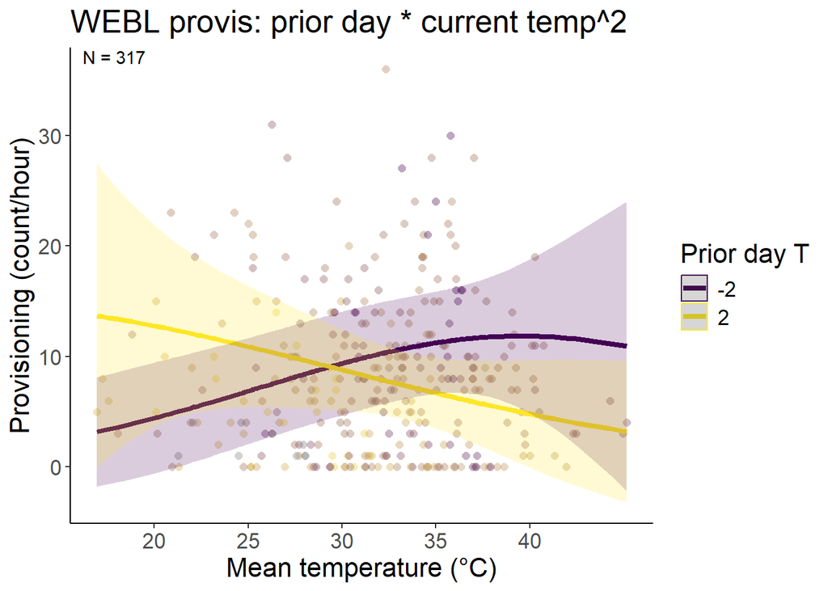

```r
data_webl_q1h2 = dplyr::filter(p,!is.na(mean_temp),
                                  # !is.na(julian_date),
                                  !is.na(mean_nestling_age),
                                  !is.na(deghours_diff_35C_priorday),
                                  !is.na(brood_size),
                                  !is.na(tod_h),
                                  !is.na(site),
                                  !is.na(attempt_id),
                                  !is.na(year_fct),
                                  species == "WEBL"# ,
                                                # tod >= hms::as.hms('11:00:00', tz = "America/Los_Angeles"),
                                                # tod_end <= hms::as.hms('17:00:00',tz = "America/Los_Angeles"),
                                                # tod_end >= hms::as.hms('11:00:00', tz = "America/Los_Angeles")
                                                ) %>%
                        mutate(across(c(tod_h,mean_temp,deghours_diff_35C_priorday,julian_date,mean_nestling_age,brood_size),
                                                    ~ scale(.x)[,1],
                                                    .names = "{.col}_scaled"))


mean_temp_webl_q1h2 <- mean(data_webl_q1h2 %>% pull(mean_temp))
sd_temp_webl_q1h2 <- sd(data_webl_q1h2 %>% pull(mean_temp))


temp_trans_webl_q1h2 <- trans_new("temp_trans_webl_q1h2",
                             transform = function(x){(x * sd_temp_webl_q1h2) + mean_temp_webl_q1h2},
                             inverse = function(x){x})

(figq1h2_webl <- predict_response(m_webl_q1h2,terms = c("mean_temp_scaled [all]","deghours_diff_35C_priorday_scaled [-2,2]"),margin = "empirical") %>%
    plot(line_size = 1.5,alpha = .2,limit_range = TRUE,show_data = TRUE,colors = "viridis") +
    # scale_color_hue(labels = c("Low","High")) +
    # aes(linetype = .data[["group"]]) +
    theme_classic() +
    # facet_wrap(~ group, ncol = 2) +
    xlab("Mean temperature (\u00b0C)") +
    ylab("Provisioning (count/hour)") +
    # scale_fill_viridis(discrete = TRUE) +
    # scale_color_viridis(discrete = TRUE) +
    theme(text = element_text(size = 16)) +
    labs(title =  "WEBL provis: prior day * current temp^2", color = "Prior day T", fill = "Prior day T") +
    scale_x_continuous(trans = temp_trans_webl_q1h2,
                       breaks = c((20-mean_temp_webl_q1h2)/sd_temp_webl_q1h2,
                                  (25-mean_temp_webl_q1h2)/sd_temp_webl_q1h2,
                                  (30-mean_temp_webl_q1h2)/sd_temp_webl_q1h2,
                                  (35-mean_temp_webl_q1h2)/sd_temp_webl_q1h2,
                                  (40-mean_temp_webl_q1h2)/sd_temp_webl_q1h2),
                       # breaks = c(20,30,40,50),
                       # labels = c("20","30","40","50"),
                       # limits = c((15-mean(g$meanmaxtempI,na.rm = TRUE))/sd(g$meanmaxtempI,na.rm = TRUE),
                       #            (55-mean(g$meanmaxtempI,na.rm = TRUE))/sd(g$meanmaxtempI,na.rm = TRUE))
                       # limits = c(18,5)
    ) +
    # scale_linetype_manual(values = "solid") +
    #ylim(-5,5) +
    geom_text(data = dat_text_webl_q1h2, mapping = aes(x = -Inf, y = Inf,label = label),hjust = -.2, vjust = 1.2,inherit.aes = FALSE) # +
    #theme(legend.position = "none")
)
```

```r
ggsave("../figures/provisbymaxtempxhab_WEBL_q1h2.png",plot =  figq1h2_webl, width = 10, height = 6.6)
```

## TRES

```r
m_TRES <- glmmTMB(valid_detections ~ poly(mean_temp_scaled,2) * deghours_diff_35C_priorday_scaled + poly(tod_h_scaled,2) + mean_nestling_age_scaled + brood_size_scaled + year_fct +  (1|site:attempt_id),
           family = nbinom2(),
           ziformula = ~ (1|site:attempt_id),
           data = dplyr::filter(p,!is.na(mean_temp),
                                  # !is.na(julian_date),
                                  !is.na(mean_nestling_age),
                                  !is.na(deghours_diff_35C_priorday),
                                  !is.na(brood_size),
                                  !is.na(tod_h),
                                  !is.na(site),
                                  !is.na(attempt_id),
                                  !is.na(year_fct),
                                  species == "TRES"# ,
                                                # tod >= hms::as.hms('11:00:00', tz = "America/Los_Angeles"),
                                                # tod_end <= hms::as.hms('17:00:00',tz = "America/Los_Angeles"),
                                                # tod_end >= hms::as.hms('11:00:00', tz = "America/Los_Angeles")
                                                ) %>%
                        mutate(across(c(tod_h,mean_temp,deghours_diff_35C_priorday,julian_date,mean_nestling_age,brood_size),
                                                    ~ scale(.x)[,1],
                                                    .names = "{.col}_scaled")),
           )

summary(m_TRES)
```

```
##  Family: nbinom2  ( log )
## Formula:
## valid_detections ~ poly(mean_temp_scaled, 2) * deghours_diff_35C_priorday_scaled +
##     poly(tod_h_scaled, 2) + mean_nestling_age_scaled + brood_size_scaled +
##     year_fct + (1 | site:attempt_id)
## Zero inflation:                    ~(1 | site:attempt_id)
## Data: dplyr::filter(p, !is.na(mean_temp), !is.na(mean_nestling_age),
##     !is.na(deghours_diff_35C_priorday), !is.na(brood_size), !is.na(tod_h),
##     !is.na(site), !is.na(attempt_id), !is.na(year_fct), species ==
##         "TRES") %>% mutate(across(c(tod_h, mean_temp, deghours_diff_35C_priorday,
##     julian_date, mean_nestling_age, brood_size), ~scale(.x)[,
##     1], .names = "{.col}_scaled"))
##
##      AIC      BIC   logLik deviance df.resid
##   1499.7   1554.8   -733.9   1467.7      215
##
## Random effects:
##
## Conditional model:
##  Groups          Name        Variance Std.Dev.
##  site:attempt_id (Intercept) 0.2042   0.4519
## Number of obs: 231, groups:  site:attempt_id, 23
##
## Zero-inflation model:
##  Groups          Name        Variance Std.Dev.
##  site:attempt_id (Intercept) 3.966    1.991
## Number of obs: 231, groups:  site:attempt_id, 23
##
## Dispersion parameter for nbinom2 family (): 3.51
##
## Conditional model:
##                                                               Estimate
## (Intercept)                                                   2.664194
## poly(mean_temp_scaled, 2)1                                    6.687453
## poly(mean_temp_scaled, 2)2                                   -1.253721
## deghours_diff_35C_priorday_scaled                             0.009217
## poly(tod_h_scaled, 2)1                                        1.161967
## poly(tod_h_scaled, 2)2                                        2.030518
## mean_nestling_age_scaled                                     -0.022320
## brood_size_scaled                                             0.289367
```

[output cut: 23 more lines]

```
## poly(tod_h_scaled, 2)2                                       0.112640
## mean_nestling_age_scaled                                     0.763981
## brood_size_scaled                                            0.056315 .
## year_fct2022                                                 0.947648
## year_fct2023                                                 0.213407
## poly(mean_temp_scaled, 2)1:deghours_diff_35C_priorday_scaled 0.795724
## poly(mean_temp_scaled, 2)2:deghours_diff_35C_priorday_scaled 0.027407 *
## ---
## Signif. codes:  0 '***' 0.001 '**' 0.01 '*' 0.05 '.' 0.1 ' ' 1
##
## Zero-inflation model:
##             Estimate Std. Error z value Pr(>|z|)
## (Intercept)  -2.2168     0.6002  -3.693 0.000221 ***
## ---
## Signif. codes:  0 '***' 0.001 '**' 0.01 '*' 0.05 '.' 0.1 ' ' 1
```

```r
m_TRES_q1h2 <- m_TRES

check_zeroinflation(m_TRES)
```

```
## # Check for zero-inflation
##
##    Observed zeros: 51
##   Predicted zeros: 50
##             Ratio: 0.98
```

```
## Model seems ok, ratio of observed and predicted zeros is within the
##   tolerance range (p = 0.896).
```

```r
# (t <- emtrends(m_TRES_q1h1,specs = ~ habitat, var = c("mean_temp_scaled"),max.degree = 1) %>% test() %>%
#    mutate(across(where(is.numeric), ~ round(.x, digits = 3)),
#           df = round(df),
#           p.value = if_else(p.value == 0.000,"<0.001",as.character(p.value))) %>%
#    rename(Habitat = "habitat", `Max temp trend` = "mean_temp_scaled.trend",Df = "df", `Z-ratio` = "z.ratio", P = "p.value") %>%
#    #group_by(degree) %>%
#    gt())

ss_year_TRES_provis_q1h2 <- m_TRES_q1h2$frame %>%
  group_by(year_fct) %>%
  summarize(count_ind = n(),count_attempt = n_distinct(attempt_id)) %>%
  rowwise() %>%
  mutate(count = tibble(count_ind,count_attempt)) %>%
  dplyr::select(-c(count_ind, count_attempt)) %>%
  pivot_wider(values_from = count,names_from = year_fct) %>%
  as.tibble() %>% # rename(Habitat = 'habitat') %>%
  ungroup() %>%
  mutate(`2021` = replace_na(`2021`,list(count_ind = 0,count_attempt = 0))) %>%
  mutate(Total = `2021` + `2022` + `2023`) %>%
  rowwise() %>%
  mutate(`2021` = paste0(`2021`$count_ind,", ",`2021`$count_attempt),
         `2022` = paste0(`2022`$count_ind,", ",`2022`$count_attempt),
         `2023` = paste0(`2023`$count_ind,", ",`2023`$count_attempt),
         Total = paste0(Total$count_ind,", ",Total$count_attempt)
  )

(t_ss_year_TRES_provis_q1h2 <- ss_year_TRES_provis_q1h2 %>% gt() %>%
    grand_summary_rows(fns = list(id = "Total") ~ {
      t <- str_split(.,", ",simplify = TRUE)
      t[,1] %>% as.numeric() %>% sum(na.rm = TRUE) %>% paste(t[,2] %>% as.numeric() %>% sum(na.rm = TRUE),sep = ", ")
    })
)
```

|  | 2021 | 2022 | 2023 | Total |
| --- | --- | --- | --- | --- |
|  | 64, 7 | 75, 7 | 92, 9 | 231, 23 |
| Total | 64, 7 | 75, 7 | 92, 9 | 231, 23 |

```r
t_ss_year_TRES_provis_q1h2 %>% gtsave("../figures/ss_year_TRES_provis_ch3_q1h2.html")

samp_q1h2 <- m_TRES_q1h2$frame %>% summarize(count = n())
samp_q1h2 %>% gt() %>% gtsave("../figures/ss_TRES_provis_ch3_q1h2.html")


dat_text_TRES_q1h2 <- data.frame(
  label = paste("N =",samp_q1h2$count)# ,
  #group   = factor(c("Forest","Orchard","Grassland","Row crop"))
)

## num nestboxes
m_TRES_q1h2$frame %>% pull(attempt_id) %>% unique() %>% length()
```

```
## [1] 23
```

```
## Data points may overlap. Use the `jitter` argument to add some amount of
##   random variation to the location of data points and avoid overplotting.
```

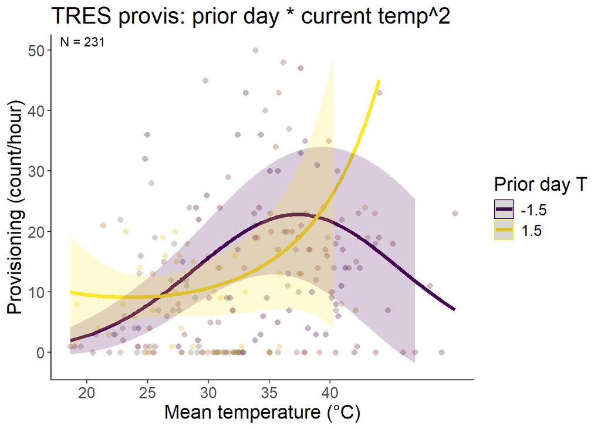

```r
data_TRES_q1h2 = dplyr::filter(p,!is.na(mean_temp),
                                  # !is.na(julian_date),
                                  !is.na(mean_nestling_age),
                                  !is.na(deghours_diff_35C_priorday),
                                  !is.na(brood_size),
                                  !is.na(tod_h),
                                  !is.na(site),
                                  !is.na(attempt_id),
                                  !is.na(year_fct),
                                  species == "TRES"# ,
                                                # tod >= hms::as.hms('11:00:00', tz = "America/Los_Angeles"),
                                                # tod_end <= hms::as.hms('17:00:00',tz = "America/Los_Angeles"),
                                                # tod_end >= hms::as.hms('11:00:00', tz = "America/Los_Angeles")
                                                ) %>%
                        mutate(across(c(tod_h,mean_temp,deghours_diff_35C_priorday,julian_date,mean_nestling_age,brood_size),
                                                    ~ scale(.x)[,1],
                                                    .names = "{.col}_scaled"))


mean_temp_TRES_q1h2 <- mean(data_TRES_q1h2 %>% pull(mean_temp))
sd_temp_TRES_q1h2 <- sd(data_TRES_q1h2 %>% pull(mean_temp))


temp_trans_TRES_q1h2 <- trans_new("temp_trans_TRES_q1h2",
                             transform = function(x){(x * sd_temp_TRES_q1h2) + mean_temp_TRES_q1h2},
                             inverse = function(x){x})

(figq1h2_TRES <- predict_response(m_TRES_q1h2,terms = c("mean_temp_scaled [all]","deghours_diff_35C_priorday_scaled [-1.5,1.5]"),margin = "empirical") %>%
    plot(line_size = 1.5,alpha = .2,limit_range = TRUE,show_data = TRUE,colors = "viridis") +
    # scale_color_hue(labels = c("Low","High")) +
    # aes(linetype = .data[["group"]]) +
    theme_classic() +
    # facet_wrap(~ group, ncol = 2) +
    xlab("Mean temperature (\u00b0C)") +
    ylab("Provisioning (count/hour)") +
    # scale_fill_viridis(discrete = TRUE) +
    # scale_color_viridis(discrete = TRUE) +
    theme(text = element_text(size = 16)) +
    labs(title =  "TRES provis: prior day * current temp^2", color = "Prior day T", fill = "Prior day T") +
    scale_x_continuous(trans = temp_trans_TRES_q1h2,
                       breaks = c((20-mean_temp_TRES_q1h2)/sd_temp_TRES_q1h2,
                                  (25-mean_temp_TRES_q1h2)/sd_temp_TRES_q1h2,
                                  (30-mean_temp_TRES_q1h2)/sd_temp_TRES_q1h2,
                                  (35-mean_temp_TRES_q1h2)/sd_temp_TRES_q1h2,
                                  (40-mean_temp_TRES_q1h2)/sd_temp_TRES_q1h2),
                       # breaks = c(20,30,40,50),
                       # labels = c("20","30","40","50"),
                       # limits = c((15-mean(g$meanmaxtempI,na.rm = TRUE))/sd(g$meanmaxtempI,na.rm = TRUE),
                       #            (55-mean(g$meanmaxtempI,na.rm = TRUE))/sd(g$meanmaxtempI,na.rm = TRUE))
                       # limits = c(18,5)
    ) +
    # scale_linetype_manual(values = "solid") +
    ylim(-2,50) +
    geom_text(data = dat_text_TRES_q1h2, mapping = aes(x = -Inf, y = Inf,label = label),hjust = -.2, vjust = 1.2,inherit.aes = FALSE) # +
    #theme(legend.position = "none")
)
```

```r
ggsave("../figures/provisbymaxtempxhab_TRES_q1h2.png",plot =  figq1h2_TRES, width = 10, height = 6.6)
```

## Q2H1

2. How does female body condition mediates provisioning We hypothesized that females in better condition (mass/tarsus) would be
1. (H1) less likely than females in worse condition to reduce their visits during hot periods because they are able to mobilize the energy required to engage in more energetically costly active thermoregulatory behaviors

This implies an interaction between condition and temperature. I’m going to drop the habitat term from Q1H1

### WEBL

```r
m_WEBL <- glmmTMB(valid_detections ~ poly(mean_temp_scaled,2) * female_condition_scaled + poly(tod_h_scaled,2) + mean_nestling_age_scaled + brood_size_scaled + year_fct + (1|site:attempt_id),
           family = nbinom2(),
           ziformula = ~ 1,
           data = dplyr::filter(p,!is.na(mean_temp),
                                !is.na(female_condition),
                                  # !is.na(julian_date),
                                  !is.na(mean_nestling_age),
                                  !is.na(brood_size),
                                  !is.na(tod_h),
                                  !is.na(site),
                                  !is.na(attempt_id),
                                  !is.na(year),
                                  species == "WEBL"# ,
                                                # tod >= hms::as.hms('11:00:00', tz = "America/Los_Angeles"),
                                                # tod_end <= hms::as.hms('17:00:00',tz = "America/Los_Angeles"),
                                                # tod_end >= hms::as.hms('11:00:00', tz = "America/Los_Angeles")
                                                ) %>%
                        mutate(across(c(tod_h,mean_temp,female_condition,julian_date,mean_nestling_age,brood_size),
                                                    ~ scale(.x)[,1],
                                                    .names = "{.col}_scaled")),
           )

m_WEBL_linint <- glmmTMB(valid_detections ~ mean_temp_scaled * female_condition_scaled + poly(mean_temp_scaled,degree = 2) + poly(tod_h_scaled,2) + mean_nestling_age_scaled + brood_size_scaled + year_fct + (1|site:attempt_id),
           family = nbinom2(),
           ziformula = ~ 1,
           data = dplyr::filter(p,!is.na(mean_temp),
                                !is.na(female_condition),
                                  # !is.na(julian_date),
                                  !is.na(mean_nestling_age),
                                  !is.na(brood_size),
                                  !is.na(tod_h),
                                  !is.na(site),
                                  !is.na(attempt_id),
                                  !is.na(year),
                                  species == "WEBL"# ,
                                                # tod >= hms::as.hms('11:00:00', tz = "America/Los_Angeles"),
                                                # tod_end <= hms::as.hms('17:00:00',tz = "America/Los_Angeles"),
                                                # tod_end >= hms::as.hms('11:00:00', tz = "America/Los_Angeles")
                                                ) %>%
                        mutate(across(c(tod_h,mean_temp,female_condition,julian_date,mean_nestling_age,brood_size),
                                                    ~ scale(.x)[,1],
                                                    .names = "{.col}_scaled")),
           )
```

```
## dropping columns from rank-deficient conditional model: poly(mean_temp_scaled, degree = 2)1
```

```r
m_WEBL_noint <- glmmTMB(valid_detections ~ female_condition_scaled + poly(mean_temp_scaled,degree = 2) + poly(tod_h_scaled,2) + mean_nestling_age_scaled + brood_size_scaled + year_fct + (1|site:attempt_id),
           family = nbinom2(),
           ziformula = ~ 1,
           data = dplyr::filter(p,!is.na(mean_temp),
                                !is.na(female_condition),
                                  # !is.na(julian_date),
                                  !is.na(mean_nestling_age),
                                  !is.na(brood_size),
                                  !is.na(tod_h),
                                  !is.na(site),
                                  !is.na(attempt_id),
                                  !is.na(year),
                                  species == "WEBL"# ,
                                                # tod >= hms::as.hms('11:00:00', tz = "America/Los_Angeles"),
                                                # tod_end <= hms::as.hms('17:00:00',tz = "America/Los_Angeles"),
                                                # tod_end >= hms::as.hms('11:00:00', tz = "America/Los_Angeles")
                                                ) %>%
                        mutate(across(c(tod_h,mean_temp,female_condition,julian_date,mean_nestling_age,brood_size),
                                                    ~ scale(.x)[,1],
                                                    .names = "{.col}_scaled")),
           )




c <- anova(m_WEBL,m_WEBL_linint,m_WEBL_noint) %>% tibble() %>% mutate(Model = c("No temp * LC interaction","Linear temp * LC interaction","Squared temp * LC interaction"),.before = Df)

(tab <- c %>%
  as.tibble() %>%
  mutate(across(where(is.numeric),~round(.x,digits = 4)),
         P = `Pr(>Chisq)`) %>%
  dplyr::select(Model,AIC,Chisq,P) %>%
  mutate(across(c(AIC,Chisq), ~ round(.x, digits = 2)),
         P = if_else(P < 0.001,"<0.001",as.character(P))) %>% gt())
```

| Model | AIC | Chisq | P |
| --- | --- | --- | --- |
| No temp * LC interaction | 876.26 | NA | NA |
| Linear temp * LC interaction | 873.59 | 4.67 | 0.0307 |
| Squared temp * LC interaction | 875.49 | 0.10 | 0.7569 |

```r
gtsave(tab,"../figures/int_tab_provis_ch3_q2h1_webl.html")

summary(m_WEBL_linint)
```

```
##  Family: nbinom2  ( log )
## Formula:
## valid_detections ~ mean_temp_scaled * female_condition_scaled +
##     poly(mean_temp_scaled, degree = 2) + poly(tod_h_scaled, 2) +
##     mean_nestling_age_scaled + brood_size_scaled + year_fct +
##     (1 | site:attempt_id)
## Zero inflation:                    ~1
## Data: dplyr::filter(p, !is.na(mean_temp), !is.na(female_condition),
##     !is.na(mean_nestling_age), !is.na(brood_size), !is.na(tod_h),
##     !is.na(site), !is.na(attempt_id), !is.na(year), species ==
##         "WEBL") %>% mutate(across(c(tod_h, mean_temp, female_condition,
##     julian_date, mean_nestling_age, brood_size), ~scale(.x)[,
##     1], .names = "{.col}_scaled"))
##
##      AIC      BIC   logLik deviance df.resid
##    873.6    913.2   -423.8    847.6      142
##
## Random effects:
##
## Conditional model:
##  Groups          Name        Variance Std.Dev.
##  site:attempt_id (Intercept) 0.4757   0.6897
## Number of obs: 155, groups:  site:attempt_id, 14
##
## Dispersion parameter for nbinom2 family (): 5.81
##
## Conditional model:
##                                          Estimate Std. Error z value Pr(>|z|)
## (Intercept)                               1.95928    0.32151   6.094 1.10e-09
## mean_temp_scaled                         -0.49344    0.10154  -4.859 1.18e-06
## female_condition_scaled                  -0.11452    0.19008  -0.602  0.54686
## poly(mean_temp_scaled, degree = 2)1            NA         NA      NA       NA
## poly(mean_temp_scaled, degree = 2)2      -1.19858    0.84914  -1.412  0.15809
## poly(tod_h_scaled, 2)1                   -1.45894    0.59201  -2.464  0.01373
## poly(tod_h_scaled, 2)2                   -1.01990    0.88722  -1.150  0.25033
## mean_nestling_age_scaled                  0.09839    0.07220   1.363  0.17295
## brood_size_scaled                         0.47593    0.16684   2.853  0.00434
## year_fct2023                             -0.80079    0.43071  -1.859  0.06299
## mean_temp_scaled:female_condition_scaled -0.15207    0.07044  -2.159  0.03087
##
## (Intercept)                              ***
## mean_temp_scaled                         ***
## female_condition_scaled
## poly(mean_temp_scaled, degree = 2)1
## poly(mean_temp_scaled, degree = 2)2
## poly(tod_h_scaled, 2)1                   *
## poly(tod_h_scaled, 2)2
## mean_nestling_age_scaled
## brood_size_scaled                        **
## year_fct2023                             .
## mean_temp_scaled:female_condition_scaled *
## ---
## Signif. codes:  0 '***' 0.001 '**' 0.01 '*' 0.05 '.' 0.1 ' ' 1
##
## Zero-inflation model:
##             Estimate Std. Error z value Pr(>|z|)
## (Intercept)   -20.05    4569.78  -0.004    0.996
```

```r
summary(m_WEBL_noint)
```

```
##  Family: nbinom2  ( log )
## Formula:
## valid_detections ~ female_condition_scaled + poly(mean_temp_scaled,
##     degree = 2) + poly(tod_h_scaled, 2) + mean_nestling_age_scaled +
##     brood_size_scaled + year_fct + (1 | site:attempt_id)
## Zero inflation:                    ~1
## Data: dplyr::filter(p, !is.na(mean_temp), !is.na(female_condition),
##     !is.na(mean_nestling_age), !is.na(brood_size), !is.na(tod_h),
##     !is.na(site), !is.na(attempt_id), !is.na(year), species ==
##         "WEBL") %>% mutate(across(c(tod_h, mean_temp, female_condition,
##     julian_date, mean_nestling_age, brood_size), ~scale(.x)[,
##     1], .names = "{.col}_scaled"))
##
##      AIC      BIC   logLik deviance df.resid
##    876.3    912.8   -426.1    852.3      143
##
## Random effects:
##
## Conditional model:
##  Groups          Name        Variance Std.Dev.
##  site:attempt_id (Intercept) 0.5192   0.7206
## Number of obs: 155, groups:  site:attempt_id, 14
##
## Dispersion parameter for nbinom2 family (): 5.63
##
## Conditional model:
##                                     Estimate Std. Error z value Pr(>|z|)
## (Intercept)                          1.99789    0.33465   5.970 2.37e-09 ***
## female_condition_scaled             -0.05723    0.19561  -0.293  0.76986
## poly(mean_temp_scaled, degree = 2)1 -5.74758    1.25329  -4.586 4.52e-06 ***
## poly(mean_temp_scaled, degree = 2)2 -0.32832    0.75134  -0.437  0.66212
## poly(tod_h_scaled, 2)1              -1.34664    0.59377  -2.268  0.02333 *
## poly(tod_h_scaled, 2)2              -1.07345    0.89382  -1.201  0.22976
## mean_nestling_age_scaled             0.10747    0.07222   1.488  0.13673
## brood_size_scaled                    0.44524    0.16941   2.628  0.00858 **
## year_fct2023                        -0.74866    0.44622  -1.678  0.09339 .
## ---
## Signif. codes:  0 '***' 0.001 '**' 0.01 '*' 0.05 '.' 0.1 ' ' 1
##
## Zero-inflation model:
##             Estimate Std. Error z value Pr(>|z|)
## (Intercept)   -19.26    4358.99  -0.004    0.996
```

```r
m_webl_q2h1 <- m_WEBL_linint

check_zeroinflation(m_WEBL_linint)
```

```
## # Check for zero-inflation
##
##    Observed zeros: 17
##   Predicted zeros: 12
##             Ratio: 0.73
```

```
## Model is underfitting zeros (probable zero-inflation) (p = 0.352).
```

```r
(t <- emtrends(m_webl_q2h1,specs = ~ female_condition_scaled, var = c("mean_temp_scaled"),max.degree = 1) %>% test() %>%
   mutate(across(where(is.numeric), ~ round(.x, digits = 3)),
          df = round(df),
          p.value = if_else(p.value == 0.000,"<0.001",as.character(p.value))) %>%
   rename(`Female condition` = "female_condition_scaled", `Max temp trend` = "mean_temp_scaled.trend",Df = "df", `Z-ratio` = "z.ratio", P = "p.value") %>%
   #group_by(degree) %>%
   gt())
```

| Female condition | Max temp trend | SE | Df | Z-ratio | P |
| --- | --- | --- | --- | --- | --- |
| 0 | -0.492 | 0.101 | Inf | -4.85 | <0.001 |

```r
joint_tests(m_webl_q2h1)
```

|  | model term | df1 | df2 | F.ratio | Chisq | p.value |
| --- | --- | --- | --- | --- | --- | --- |
| 1 | mean_temp_scaled | 1 | Inf | 23.502 | 23.502 | 1.247939e-06 |
| 3 | female_condition_scaled | 1 | Inf | 0.363 | 0.363 | 5.468570e-01 |
| 4 | tod_h_scaled | 1 | Inf | 5.213 | 5.213 | 2.242063e-02 |
| 5 | mean_nestling_age_scaled | 1 | Inf | 1.857 | 1.857 | 1.729457e-01 |
| 6 | brood_size_scaled | 1 | Inf | 8.137 | 8.137 | 4.336517e-03 |
| 7 | year_fct | 1 | Inf | 3.457 | 3.457 | 6.299246e-02 |
| 2 | mean_temp_scaled:female_condition_scaled | 1 | Inf | 4.660 | 4.660 | 3.086834e-02 |

```r
# gtsave(t,"../figures/weblprovistrend_ch3_q2h1.html")


ss_year_webl_provis <- m_webl_q2h1$frame %>%
  group_by(year_fct) %>%
  summarize(count_ind = n(),count_attempt = n_distinct(attempt_id)) %>%
  rowwise() %>%
  mutate(count = tibble(count_ind,count_attempt)) %>%
  dplyr::select(-c(count_ind, count_attempt)) %>%
  pivot_wider(values_from = count,names_from = year_fct) %>%
  as.tibble() %>%
  ungroup() %>%
  # mutate(`2021` = replace_na(`2021`,list(count_ind = 0,count_attempt = 0))) %>%
  mutate(Total = `2022` + `2023`) %>%
  rowwise() %>%
  mutate(`2022` = paste0(`2022`$count_ind,", ",`2022`$count_attempt),
         `2023` = paste0(`2023`$count_ind,", ",`2023`$count_attempt),
         Total = paste0(Total$count_ind,", ",Total$count_attempt)
  )

(t_ss_year_webl_provis <- ss_year_webl_provis %>% gt() %>%
    grand_summary_rows(fns = list(id = "Total") ~ {
      t <- str_split(.,", ",simplify = TRUE)
      t[,1] %>% as.numeric() %>% sum(na.rm = TRUE) %>% paste(t[,2] %>% as.numeric() %>% sum(na.rm = TRUE),sep = ", ")
    })
)
```

|  | 2022 | 2023 | Total |
| --- | --- | --- | --- |
|  | 88, 5 | 67, 9 | 155, 14 |
| Total | 88, 5 | 67, 9 | 155, 14 |

```r
t_ss_year_webl_provis %>% gtsave("../figures/ss_year_webl_provis_ch3.html")

samp <- m_webl_q2h1$frame %>% summarize(count = n())
samp %>% gt() %>% gtsave("../figures/ss_webl_provis_ch3.html")


dat_text_webl_q2h1 <- data.frame(
  label = paste("N =",samp$count),
  group   = factor(c("Forest","Orchard","Grassland","Row crop"))
)

## num nestboxes
m_webl_q2h1$frame %>% pull(attempt_id) %>% unique() %>% length()
```

```
## [1] 14
```

```
## Data points may overlap. Use the `jitter` argument to add some amount of
##   random variation to the location of data points and avoid overplotting.
```

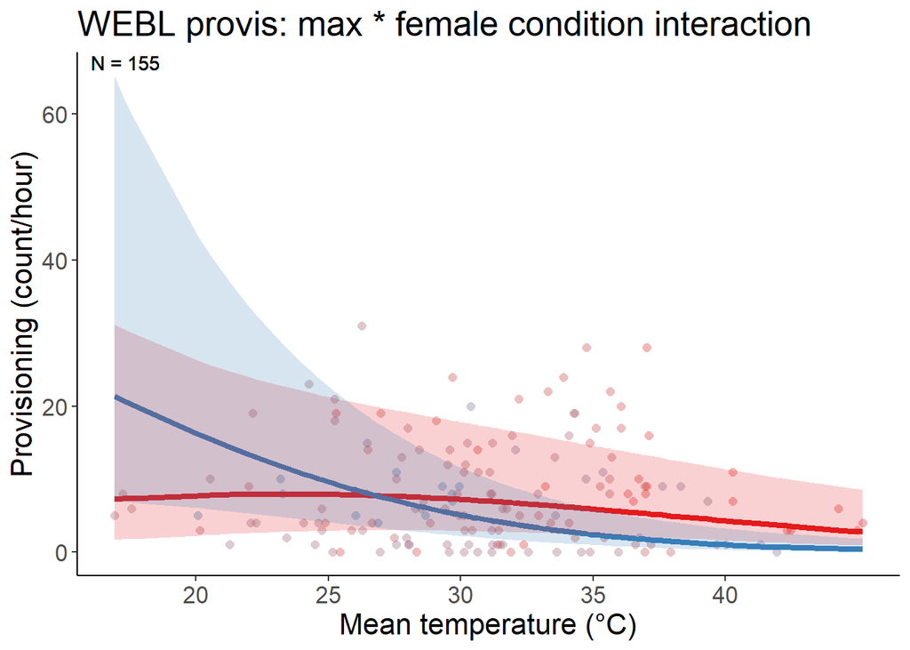

```r
data_webl_q2h1 = dplyr::filter(p,!is.na(mean_temp),
                               !is.na(female_condition),
                                  # !is.na(julian_date),
                                  !is.na(mean_nestling_age),
                                  !is.na(brood_size),
                                  !is.na(tod_h),
                                  !is.na(site),
                                  !is.na(attempt_id),
                                  !is.na(year),
                                  species == "WEBL"# ,
                                                # tod >= hms::as.hms('11:00:00', tz = "America/Los_Angeles"),
                                                # tod_end <= hms::as.hms('17:00:00',tz = "America/Los_Angeles"),
                                                # tod_end >= hms::as.hms('11:00:00', tz = "America/Los_Angeles")
                                                ) %>%
                        mutate(across(c(tod_h,mean_temp,female_condition,julian_date,mean_nestling_age,brood_size),
                                                    ~ scale(.x)[,1],
                                                    .names = "{.col}_scaled"))


mean_temp_webl_q2h1 <- mean(data_webl_q2h1 %>% pull(mean_temp))
sd_temp_webl_q2h1 <- sd(data_webl_q2h1 %>% pull(mean_temp))


temp_trans_webl_q2h1 <- trans_new("temp_trans_webl_q2h1",
                             transform = function(x){(x * sd_temp_webl_q2h1) + mean_temp_webl_q2h1},
                             inverse = function(x){x})

(figq2h1_webl <- predict_response(m_webl_q2h1,terms = c("mean_temp_scaled [all]","female_condition_scaled [-2,2]"),margin = "marginalmeans") %>%
    plot(line_size = 1.5,alpha = .2,show_data = TRUE,limit_range = TRUE) +
    # aes(linetype = .data[["group"]]) +
    theme_classic() +
    # facet_wrap(~ group, ncol = 2) +
    xlab("Mean temperature (\u00b0C)") +
    ylab("Provisioning (count/hour)") +
    # scale_fill_viridis(discrete = TRUE) +
    # scale_color_viridis(discrete = TRUE) +
    theme(text = element_text(size = 16)) +
    labs(title =  "WEBL provis: max * female condition interaction") +
    scale_x_continuous(trans = temp_trans_webl_q2h1,
                       breaks = c((20-mean_temp_webl_q2h1)/sd_temp_webl_q2h1,
                                  (25-mean_temp_webl_q2h1)/sd_temp_webl_q2h1,
                                  (30-mean_temp_webl_q2h1)/sd_temp_webl_q2h1,
                                  (35-mean_temp_webl_q2h1)/sd_temp_webl_q2h1,
                                  (40-mean_temp_webl_q2h1)/sd_temp_webl_q2h1),
                       # breaks = c(20,30,40,50),
                       # labels = c("20","30","40","50"),
                       # limits = c((15-mean(g$meanmaxtempI,na.rm = TRUE))/sd(g$meanmaxtempI,na.rm = TRUE),
                       #            (55-mean(g$meanmaxtempI,na.rm = TRUE))/sd(g$meanmaxtempI,na.rm = TRUE))
                       # limits = c(18,5)
    ) +
    # scale_linetype_manual(values = c("Forest" = "solid","Orchard" = "dashed","Grassland" = "solid","Row crop" = "dotted")) +
    #ylim(-5,5) +
    geom_text(data = dat_text_webl_q2h1, mapping = aes(x = -Inf, y = Inf,label = label),hjust = -.2, vjust = 1.2,inherit.aes = FALSE) +
    theme(legend.position = "none")
)
```

```r
ggsave("../figures/provisbymaxtempxhab_WEBL_q2h1.png",plot =  figq2h1_webl, width = 10, height = 6.6)
```

When it’s hot, females in better condition provision less. Maybe they have the capacity to compensate?

### TRES

```r
m_TRES <- glmmTMB(valid_detections ~ poly(mean_temp_scaled,2) * female_condition_scaled + poly(tod_h_scaled,2) + mean_nestling_age_scaled + brood_size_scaled + year_fct + (1|site:attempt_id),
           family = nbinom2(),
           ziformula = ~ 1,
           data = dplyr::filter(p,!is.na(mean_temp),
                                !is.na(female_condition),
                                  # !is.na(julian_date),
                                  !is.na(mean_nestling_age),
                                  !is.na(brood_size),
                                  !is.na(tod_h),
                                  !is.na(site),
                                  !is.na(attempt_id),
                                  !is.na(year),
                                  species == "TRES"# ,
                                                # tod >= hms::as.hms('11:00:00', tz = "America/Los_Angeles"),
                                                # tod_end <= hms::as.hms('17:00:00',tz = "America/Los_Angeles"),
                                                # tod_end >= hms::as.hms('11:00:00', tz = "America/Los_Angeles")
                                                ) %>%
                        mutate(across(c(tod_h,mean_temp,female_condition,julian_date,mean_nestling_age,brood_size),
                                                    ~ scale(.x)[,1],
                                                    .names = "{.col}_scaled")),
           )

m_TRES_linint <- glmmTMB(valid_detections ~ mean_temp_scaled * female_condition_scaled + poly(mean_temp_scaled,degree = 2) + poly(tod_h_scaled,2) + mean_nestling_age_scaled + brood_size_scaled + year_fct + (1|site:attempt_id),
           family = nbinom2(),
           ziformula = ~ 1,
           data = dplyr::filter(p,!is.na(mean_temp),
                                !is.na(female_condition),
                                  # !is.na(julian_date),
                                  !is.na(mean_nestling_age),
                                  !is.na(brood_size),
                                  !is.na(tod_h),
                                  !is.na(site),
                                  !is.na(attempt_id),
                                  !is.na(year),
                                  species == "TRES"# ,
                                                # tod >= hms::as.hms('11:00:00', tz = "America/Los_Angeles"),
                                                # tod_end <= hms::as.hms('17:00:00',tz = "America/Los_Angeles"),
                                                # tod_end >= hms::as.hms('11:00:00', tz = "America/Los_Angeles")
                                                ) %>%
                        mutate(across(c(tod_h,mean_temp,female_condition,julian_date,mean_nestling_age,brood_size),
                                                    ~ scale(.x)[,1],
                                                    .names = "{.col}_scaled")),
           )
```

```
## dropping columns from rank-deficient conditional model: poly(mean_temp_scaled, degree = 2)1
```

```r
m_TRES_noint <- glmmTMB(valid_detections ~ female_condition_scaled + poly(mean_temp_scaled,degree = 2) + poly(tod_h_scaled,2) + mean_nestling_age_scaled + brood_size_scaled + year_fct + (1|site:attempt_id),
           family = nbinom2(),
           ziformula = ~ 1,
           data = dplyr::filter(p,!is.na(mean_temp),
                                !is.na(female_condition),
                                  # !is.na(julian_date),
                                  !is.na(mean_nestling_age),
                                  !is.na(brood_size),
                                  !is.na(tod_h),
                                  !is.na(site),
                                  !is.na(attempt_id),
                                  !is.na(year),
                                  species == "TRES"# ,
                                                # tod >= hms::as.hms('11:00:00', tz = "America/Los_Angeles"),
                                                # tod_end <= hms::as.hms('17:00:00',tz = "America/Los_Angeles"),
                                                # tod_end >= hms::as.hms('11:00:00', tz = "America/Los_Angeles")
                                                ) %>%
                        mutate(across(c(tod_h,mean_temp,female_condition,julian_date,mean_nestling_age,brood_size),
                                                    ~ scale(.x)[,1],
                                                    .names = "{.col}_scaled")),
           )




c <- anova(m_TRES,m_TRES_linint,m_TRES_noint) %>% tibble() %>% mutate(Model = c("No temp * LC interaction","Linear temp * LC interaction","Squared temp * LC interaction"),.before = Df)

(tab <- c %>%
  as.tibble() %>%
  mutate(across(where(is.numeric),~round(.x,digits = 4)),
         P = `Pr(>Chisq)`) %>%
  dplyr::select(Model,AIC,Chisq,P) %>%
  mutate(across(c(AIC,Chisq), ~ round(.x, digits = 2)),
         P = if_else(P < 0.001,"<0.001",as.character(P))) %>% gt())
```

| Model | AIC | Chisq | P |
| --- | --- | --- | --- |
| No temp * LC interaction | 1046.62 | NA | NA |
| Linear temp * LC interaction | 1048.55 | 0.07 | 0.7981 |
| Squared temp * LC interaction | 1050.50 | 0.06 | 0.8101 |

```r
gtsave(tab,"../figures/int_tab_provis_ch3_q2h1_tres.html")

summary(m_TRES_linint)
```

```
##  Family: nbinom2  ( log )
## Formula:
## valid_detections ~ mean_temp_scaled * female_condition_scaled +
##     poly(mean_temp_scaled, degree = 2) + poly(tod_h_scaled, 2) +
##     mean_nestling_age_scaled + brood_size_scaled + year_fct +
##     (1 | site:attempt_id)
## Zero inflation:                    ~1
## Data: dplyr::filter(p, !is.na(mean_temp), !is.na(female_condition),
##     !is.na(mean_nestling_age), !is.na(brood_size), !is.na(tod_h),
##     !is.na(site), !is.na(attempt_id), !is.na(year), species ==
##         "TRES") %>% mutate(across(c(tod_h, mean_temp, female_condition,
##     julian_date, mean_nestling_age, brood_size), ~scale(.x)[,
##     1], .names = "{.col}_scaled"))
##
##      AIC      BIC   logLik deviance df.resid
##   1048.6   1088.2   -511.3   1022.6      143
##
## Random effects:
##
## Conditional model:
##  Groups          Name        Variance Std.Dev.
##  site:attempt_id (Intercept) 0.8308   0.9115
## Number of obs: 156, groups:  site:attempt_id, 14
##
## Dispersion parameter for nbinom2 family (): 2.87
##
## Conditional model:
##                                          Estimate Std. Error z value Pr(>|z|)
## (Intercept)                               2.70791    0.50444   5.368 7.95e-08
## mean_temp_scaled                          0.53263    0.18678   2.852  0.00435
## female_condition_scaled                   0.64644    0.32268   2.003  0.04514
## poly(mean_temp_scaled, degree = 2)1            NA         NA      NA       NA
## poly(mean_temp_scaled, degree = 2)2      -1.01704    0.98240  -1.035  0.30055
## poly(tod_h_scaled, 2)1                   -0.46210    0.86813  -0.532  0.59452
## poly(tod_h_scaled, 2)2                    3.11433    1.46649   2.124  0.03370
## mean_nestling_age_scaled                 -0.01919    0.10128  -0.189  0.84972
## brood_size_scaled                         0.61321    0.38074   1.611  0.10727
## year_fct2023                             -0.92232    0.75130  -1.228  0.21959
## mean_temp_scaled:female_condition_scaled -0.02745    0.10707  -0.256  0.79765
##
## (Intercept)                              ***
## mean_temp_scaled                         **
## female_condition_scaled                  *
## poly(mean_temp_scaled, degree = 2)1
## poly(mean_temp_scaled, degree = 2)2
## poly(tod_h_scaled, 2)1
## poly(tod_h_scaled, 2)2                   *
## mean_nestling_age_scaled
## brood_size_scaled
## year_fct2023
## mean_temp_scaled:female_condition_scaled
## ---
## Signif. codes:  0 '***' 0.001 '**' 0.01 '*' 0.05 '.' 0.1 ' ' 1
##
## Zero-inflation model:
##             Estimate Std. Error z value Pr(>|z|)
## (Intercept)  -2.1114     0.3061  -6.898 5.28e-12 ***
## ---
## Signif. codes:  0 '***' 0.001 '**' 0.01 '*' 0.05 '.' 0.1 ' ' 1
```

```r
summary(m_TRES_noint)
```

```
##  Family: nbinom2  ( log )
## Formula:
## valid_detections ~ female_condition_scaled + poly(mean_temp_scaled,
##     degree = 2) + poly(tod_h_scaled, 2) + mean_nestling_age_scaled +
##     brood_size_scaled + year_fct + (1 | site:attempt_id)
## Zero inflation:                    ~1
## Data: dplyr::filter(p, !is.na(mean_temp), !is.na(female_condition),
##     !is.na(mean_nestling_age), !is.na(brood_size), !is.na(tod_h),
##     !is.na(site), !is.na(attempt_id), !is.na(year), species ==
##         "TRES") %>% mutate(across(c(tod_h, mean_temp, female_condition,
##     julian_date, mean_nestling_age, brood_size), ~scale(.x)[,
##     1], .names = "{.col}_scaled"))
##
##      AIC      BIC   logLik deviance df.resid
##   1046.6   1083.2   -511.3   1022.6      144
##
## Random effects:
##
## Conditional model:
##  Groups          Name        Variance Std.Dev.
##  site:attempt_id (Intercept) 0.8181   0.9045
## Number of obs: 156, groups:  site:attempt_id, 14
##
## Dispersion parameter for nbinom2 family (): 2.84
##
## Conditional model:
##                                     Estimate Std. Error z value Pr(>|z|)
## (Intercept)                          2.71217    0.50072   5.416 6.08e-08 ***
## female_condition_scaled              0.65048    0.32018   2.032  0.04219 *
## poly(mean_temp_scaled, degree = 2)1  6.59523    2.32565   2.836  0.00457 **
## poly(mean_temp_scaled, degree = 2)2 -0.97897    0.97630  -1.003  0.31599
## poly(tod_h_scaled, 2)1              -0.44642    0.86791  -0.514  0.60700
## poly(tod_h_scaled, 2)2               3.15481    1.46367   2.155  0.03113 *
## mean_nestling_age_scaled            -0.02132    0.10137  -0.210  0.83342
## brood_size_scaled                    0.61023    0.37808   1.614  0.10652
## year_fct2023                        -0.92834    0.74643  -1.244  0.21361
## ---
## Signif. codes:  0 '***' 0.001 '**' 0.01 '*' 0.05 '.' 0.1 ' ' 1
##
## Zero-inflation model:
##             Estimate Std. Error z value Pr(>|z|)
## (Intercept)   -2.118      0.307  -6.899 5.25e-12 ***
## ---
## Signif. codes:  0 '***' 0.001 '**' 0.01 '*' 0.05 '.' 0.1 ' ' 1
```

```r
m_tres_q2h1 <- m_TRES_noint

check_zeroinflation(m_TRES_noint)
```

```
## # Check for zero-inflation
##
##    Observed zeros: 29
##   Predicted zeros: 26
##             Ratio: 0.91
```

```
## Model seems ok, ratio of observed and predicted zeros is within the
##   tolerance range (p = 0.608).
```

```r
(t <- emtrends(m_tres_q2h1,specs = ~ female_condition_scaled, var = c("mean_temp_scaled"),max.degree = 1) %>% test() %>%
   mutate(across(where(is.numeric), ~ round(.x, digits = 3)),
          df = round(df),
          p.value = if_else(p.value == 0.000,"<0.001",as.character(p.value))) %>%
   rename(`Female condition` = "female_condition_scaled", `Max temp trend` = "mean_temp_scaled.trend",Df = "df", `Z-ratio` = "z.ratio", P = "p.value") %>%
   #group_by(degree) %>%
   gt())
```

| Female condition | Max temp trend | SE | Df | Z-ratio | P |
| --- | --- | --- | --- | --- | --- |
| 0 | 0.523 | 0.185 | Inf | 2.821 | 0.005 |

```r
joint_tests(m_tres_q2h1)
```

|  | model term | df1 | df2 | F.ratio | Chisq | p.value |
| --- | --- | --- | --- | --- | --- | --- |
| 1 | female_condition_scaled | 1 | Inf | 4.127 | 4.127 | 0.042192875 |
| 2 | mean_temp_scaled | 1 | Inf | 7.964 | 7.964 | 0.004772756 |
| 3 | tod_h_scaled | 1 | Inf | 1.198 | 1.198 | 0.273735294 |
| 4 | mean_nestling_age_scaled | 1 | Inf | 0.044 | 0.044 | 0.833419886 |
| 5 | brood_size_scaled | 1 | Inf | 2.605 | 2.605 | 0.106516328 |
| 6 | year_fct | 1 | Inf | 1.547 | 1.547 | 0.213610297 |

```r
# gtsave(t,"../figures/tresprovistrend_ch3_q2h1.html")


ss_year_tres_provis <- m_tres_q2h1$frame %>%
  group_by(year_fct) %>%
  summarize(count_ind = n(),count_attempt = n_distinct(attempt_id)) %>%
  rowwise() %>%
  mutate(count = tibble(count_ind,count_attempt)) %>%
  dplyr::select(-c(count_ind, count_attempt)) %>%
  pivot_wider(values_from = count,names_from = year_fct) %>%
  as.tibble() %>%
  ungroup() %>%
  # mutate(`2021` = replace_na(`2021`,list(count_ind = 0,count_attempt = 0))) %>%
  mutate(Total = `2022` + `2023`) %>%
  rowwise() %>%
  mutate(`2022` = paste0(`2022`$count_ind,", ",`2022`$count_attempt),
         `2023` = paste0(`2023`$count_ind,", ",`2023`$count_attempt),
         Total = paste0(Total$count_ind,", ",Total$count_attempt)
  )

(t_ss_year_tres_provis <- ss_year_tres_provis %>% gt() %>%
    grand_summary_rows(fns = list(id = "Total") ~ {
      t <- str_split(.,", ",simplify = TRUE)
      t[,1] %>% as.numeric() %>% sum(na.rm = TRUE) %>% paste(t[,2] %>% as.numeric() %>% sum(na.rm = TRUE),sep = ", ")
    })
)
```

|  | 2022 | 2023 | Total |
| --- | --- | --- | --- |
|  | 68, 6 | 88, 8 | 156, 14 |
| Total | 68, 6 | 88, 8 | 156, 14 |

```r
t_ss_year_tres_provis %>% gtsave("../figures/ss_year_tres_provis_ch3.html")

samp <- m_tres_q2h1$frame %>% summarize(count = n())
samp %>% gt() %>% gtsave("../figures/ss_tres_provis_ch3.html")


dat_text_tres_q2h1 <- data.frame(
  label = paste("N =",samp$count),
  group   = factor(c("Forest","Orchard","Grassland","Row crop"))
)

## num nestboxes
m_tres_q2h1$frame %>% pull(attempt_id) %>% unique() %>% length()
```

```
## [1] 14
```

```
## Data points may overlap. Use the `jitter` argument to add some amount of
##   random variation to the location of data points and avoid overplotting.
```

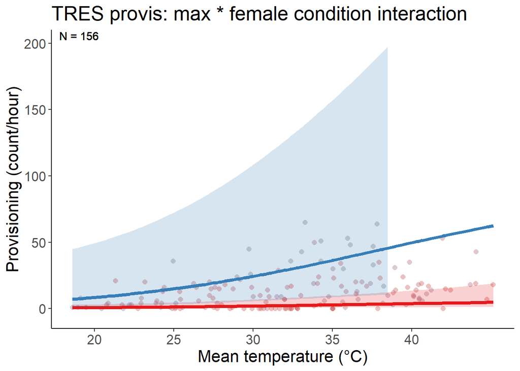

```r
data_tres_q2h1 = dplyr::filter(p,!is.na(mean_temp),
                               !is.na(female_condition),
                                  # !is.na(julian_date),
                                  !is.na(mean_nestling_age),
                                  !is.na(brood_size),
                                  !is.na(tod_h),
                                  !is.na(site),
                                  !is.na(attempt_id),
                                  !is.na(year),
                                  species == "TRES"# ,
                                                # tod >= hms::as.hms('11:00:00', tz = "America/Los_Angeles"),
                                                # tod_end <= hms::as.hms('17:00:00',tz = "America/Los_Angeles"),
                                                # tod_end >= hms::as.hms('11:00:00', tz = "America/Los_Angeles")
                                                ) %>%
                        mutate(across(c(tod_h,mean_temp,female_condition,julian_date,mean_nestling_age,brood_size),
                                                    ~ scale(.x)[,1],
                                                    .names = "{.col}_scaled"))


mean_temp_tres_q2h1 <- mean(data_tres_q2h1 %>% pull(mean_temp))
sd_temp_tres_q2h1 <- sd(data_tres_q2h1 %>% pull(mean_temp))


temp_trans_tres_q2h1 <- trans_new("temp_trans_tres_q2h1",
                             transform = function(x){(x * sd_temp_tres_q2h1) + mean_temp_tres_q2h1},
                             inverse = function(x){x})

(figq2h1_tres <- predict_response(m_tres_q2h1,terms = c("mean_temp_scaled [all]","female_condition_scaled [-2,2]"),margin = "marginalmeans") %>%
    plot(line_size = 1.5,alpha = .2,show_data = TRUE,limit_range = TRUE) +
    # aes(linetype = .data[["group"]]) +
    theme_classic() +
    # facet_wrap(~ group, ncol = 2) +
    xlab("Mean temperature (\u00b0C)") +
    ylab("Provisioning (count/hour)") +
    # scale_fill_viridis(discrete = TRUE) +
    # scale_color_viridis(discrete = TRUE) +
    theme(text = element_text(size = 16)) +
    labs(title =  "TRES provis: max * female condition interaction") +
    scale_x_continuous(trans = temp_trans_tres_q2h1,
                       breaks = c((20-mean_temp_tres_q2h1)/sd_temp_tres_q2h1,
                                  (25-mean_temp_tres_q2h1)/sd_temp_tres_q2h1,
                                  (30-mean_temp_tres_q2h1)/sd_temp_tres_q2h1,
                                  (35-mean_temp_tres_q2h1)/sd_temp_tres_q2h1,
                                  (40-mean_temp_tres_q2h1)/sd_temp_tres_q2h1),
                       # breaks = c(20,30,40,50),
                       # labels = c("20","30","40","50"),
                       # limits = c((15-mean(g$meanmaxtempI,na.rm = TRUE))/sd(g$meanmaxtempI,na.rm = TRUE),
                       #            (55-mean(g$meanmaxtempI,na.rm = TRUE))/sd(g$meanmaxtempI,na.rm = TRUE))
                       # limits = c(18,5)
    ) +
    # scale_linetype_manual(values = c("Forest" = "solid","Orchard" = "dashed","Grassland" = "solid","Row crop" = "dotted")) +
    ylim(-5,200) +
    geom_text(data = dat_text_tres_q2h1, mapping = aes(x = -Inf, y = Inf,label = label),hjust = -.2, vjust = 1.2,inherit.aes = FALSE) +
    theme(legend.position = "none")
)
```

```r
ggsave("../figures/provisbymaxtempxhab_TRES_q2h1.png",plot =  figq2h1_tres, width = 10, height = 6.6)
```

So for TRES, when females are in better body condition, there’s more provisioning, and when it’s hot, there’s also more provisioning. But no interaction between the two.

## Q2H2

2. How does female body condition mediates provisioning We hypothesized that females in better condition (mass/tarsus) would be
1. (H1) less likely than females in worse condition to reduce their visits during hot periods because they are able to mobilize the energy required to engage in more energetically costly active thermoregulatory behaviors and
2. (H2) more likely than females in worse condition to maintain total provisioning visits by increasing visit rates during cooler hours of the day.

### WEBL

```r
m_WEBL <- glmmTMB(valid_detections ~ poly(mean_temp_scaled,2) * deghours_diff_35C_priorday_scaled * female_condition_scaled + mean_nestling_age_scaled + brood_size_scaled + year_fct +  (1|site:attempt_id),
           family = nbinom2(),
           ziformula = ~ 1,
           data = dplyr::filter(p,!is.na(mean_temp),
                                  # !is.na(julian_date),
                                  !is.na(mean_nestling_age),
                                  !is.na(deghours_diff_35C_priorday),
                                  !is.na(female_condition),
                                  !is.na(brood_size),
                                  !is.na(tod_h),
                                  !is.na(site),
                                  !is.na(attempt_id),
                                  !is.na(year_fct),
                                  species == "WEBL"# ,
                                                # tod >= hms::as.hms('11:00:00', tz = "America/Los_Angeles"),
                                                # tod_end <= hms::as.hms('17:00:00',tz = "America/Los_Angeles"),
                                                # tod_end >= hms::as.hms('11:00:00', tz = "America/Los_Angeles")
                                                ) %>%
                        mutate(across(c(tod_h,mean_temp,deghours_diff_35C_priorday,female_condition,julian_date,mean_nestling_age,brood_size),
                                                    ~ scale(.x)[,1],
                                                    .names = "{.col}_scaled")),
           )

m_WEBL_deghxfc <- glmmTMB(valid_detections ~ poly(mean_temp_scaled,2) + deghours_diff_35C_priorday_scaled * female_condition_scaled + mean_nestling_age_scaled + brood_size_scaled + year_fct +  (1|site:attempt_id),
           family = nbinom2(),
           ziformula = ~ 1,
           data = dplyr::filter(p,!is.na(mean_temp),
                                  # !is.na(julian_date),
                                  !is.na(mean_nestling_age),
                                  !is.na(deghours_diff_35C_priorday),
                                  !is.na(female_condition),
                                  !is.na(brood_size),
                                  !is.na(tod_h),
                                  !is.na(site),
                                  !is.na(attempt_id),
                                  !is.na(year_fct),
                                  species == "WEBL"# ,
                                                # tod >= hms::as.hms('11:00:00', tz = "America/Los_Angeles"),
                                                # tod_end <= hms::as.hms('17:00:00',tz = "America/Los_Angeles"),
                                                # tod_end >= hms::as.hms('11:00:00', tz = "America/Los_Angeles")
                                                ) %>%
                        mutate(across(c(tod_h,mean_temp,deghours_diff_35C_priorday,female_condition,julian_date,mean_nestling_age,brood_size),
                                                    ~ scale(.x)[,1],
                                                    .names = "{.col}_scaled")),
           )

m_WEBL_mtxdegh <- glmmTMB(valid_detections ~ poly(mean_temp_scaled,2) * deghours_diff_35C_priorday_scaled + female_condition_scaled + mean_nestling_age_scaled + brood_size_scaled + year_fct +  (1|site:attempt_id),
           family = nbinom2(),
           ziformula = ~ 1,
           data = dplyr::filter(p,!is.na(mean_temp),
                                  # !is.na(julian_date),
                                  !is.na(mean_nestling_age),
                                  !is.na(deghours_diff_35C_priorday),
                                  !is.na(female_condition),
                                  !is.na(brood_size),
                                  !is.na(tod_h),
                                  !is.na(site),
                                  !is.na(attempt_id),
                                  !is.na(year_fct),
                                  species == "WEBL"# ,
                                                # tod >= hms::as.hms('11:00:00', tz = "America/Los_Angeles"),
                                                # tod_end <= hms::as.hms('17:00:00',tz = "America/Los_Angeles"),
                                                # tod_end >= hms::as.hms('11:00:00', tz = "America/Los_Angeles")
                                                ) %>%
                        mutate(across(c(tod_h,mean_temp,deghours_diff_35C_priorday,female_condition,julian_date,mean_nestling_age,brood_size),
                                                    ~ scale(.x)[,1],
                                                    .names = "{.col}_scaled")),
           )

m_WEBL_mtxfc <- glmmTMB(valid_detections ~ poly(mean_temp_scaled,2) * female_condition_scaled + deghours_diff_35C_priorday_scaled + mean_nestling_age_scaled + brood_size_scaled + year_fct +  (1|site:attempt_id),
           family = nbinom2(),
           ziformula = ~ 1,
           data = dplyr::filter(p,!is.na(mean_temp),
                                  # !is.na(julian_date),
                                  !is.na(mean_nestling_age),
                                  !is.na(deghours_diff_35C_priorday),
                                  !is.na(female_condition),
                                  !is.na(brood_size),
                                  !is.na(tod_h),
                                  !is.na(site),
                                  !is.na(attempt_id),
                                  !is.na(year_fct),
                                  species == "WEBL"# ,
                                                # tod >= hms::as.hms('11:00:00', tz = "America/Los_Angeles"),
                                                # tod_end <= hms::as.hms('17:00:00',tz = "America/Los_Angeles"),
                                                # tod_end >= hms::as.hms('11:00:00', tz = "America/Los_Angeles")
                                                ) %>%
                        mutate(across(c(tod_h,mean_temp,deghours_diff_35C_priorday,female_condition,julian_date,mean_nestling_age,brood_size),
                                                    ~ scale(.x)[,1],
                                                    .names = "{.col}_scaled")),
           )

m_WEBL_noint <- glmmTMB(valid_detections ~ poly(mean_temp_scaled,2) + deghours_diff_35C_priorday_scaled + female_condition_scaled + mean_nestling_age_scaled + brood_size_scaled + year_fct +  (1|site:attempt_id),
           family = nbinom2(),
           ziformula = ~ 1,
           data = dplyr::filter(p,!is.na(mean_temp),
                                  # !is.na(julian_date),
                                  !is.na(mean_nestling_age),
                                  !is.na(deghours_diff_35C_priorday),
                                  !is.na(female_condition),
                                  !is.na(brood_size),
                                  !is.na(tod_h),
                                  !is.na(site),
                                  !is.na(attempt_id),
                                  !is.na(year_fct),
                                  species == "WEBL"# ,
                                                # tod >= hms::as.hms('11:00:00', tz = "America/Los_Angeles"),
                                                # tod_end <= hms::as.hms('17:00:00',tz = "America/Los_Angeles"),
                                                # tod_end >= hms::as.hms('11:00:00', tz = "America/Los_Angeles")
                                                ) %>%
                        mutate(across(c(tod_h,mean_temp,deghours_diff_35C_priorday,female_condition,julian_date,mean_nestling_age,brood_size),
                                                    ~ scale(.x)[,1],
                                                    .names = "{.col}_scaled")),
           )

c <- anova(m_WEBL,m_WEBL_mtxdegh,m_WEBL_deghxfc,m_WEBL_mtxfc) %>% tibble() %>% mutate(Model = c("Degree-hour * female condition","Mean temp * Degree-hour","Mean temp * female condition","Triple interaction"),.before = Df)

(tab <- c %>%
  as.tibble() %>%
  mutate(across(where(is.numeric),~round(.x,digits = 4)),
         P = `Pr(>Chisq)`) %>%
  dplyr::select(Model,AIC,Chisq,P) %>%
  mutate(across(c(AIC,Chisq), ~ round(.x, digits = 2)),
         P = if_else(P < 0.001,"<0.001",as.character(P))) %>% gt())
```

| Model | AIC | Chisq | P |
| --- | --- | --- | --- |
| Degree-hour * female condition | 882.06 | NA | NA |
| Mean temp * Degree-hour | 872.11 | 11.95 | <0.001 |
| Mean temp * female condition | 880.58 | 0.00 | 1 |
| Triple interaction | 861.68 | 28.89 | <0.001 |

```r
gtsave(tab,"../figures/int_tab_provis_ch3_q2h2_webl_1.html")

c <- anova(m_WEBL,m_WEBL_mtxdegh) %>% tibble() %>% mutate(Model = c("Mean temp * Degree-hour","Triple interaction"),.before = Df)

(tab <- c %>%
  as.tibble() %>%
  mutate(across(where(is.numeric),~round(.x,digits = 4)),
         P = `Pr(>Chisq)`) %>%
  dplyr::select(Model,AIC,Chisq,P) %>%
  mutate(across(c(AIC,Chisq), ~ round(.x, digits = 2)),
         P = if_else(P < 0.001,"<0.001",as.character(P))) %>% gt())
```

| Model | AIC | Chisq | P |
| --- | --- | --- | --- |
| Mean temp * Degree-hour | 872.11 | NA | NA |
| Triple interaction | 861.68 | 20.43 | 0.001 |

```r
gtsave(tab,"../figures/int_tab_provis_ch3_q2h2_webl_2.html")

summary(m_WEBL)
```

```
##  Family: nbinom2  ( log )
## Formula:
## valid_detections ~ poly(mean_temp_scaled, 2) * deghours_diff_35C_priorday_scaled *
##     female_condition_scaled + mean_nestling_age_scaled + brood_size_scaled +
##     year_fct + (1 | site:attempt_id)
## Zero inflation:                    ~1
## Data: dplyr::filter(p, !is.na(mean_temp), !is.na(mean_nestling_age),
##     !is.na(deghours_diff_35C_priorday), !is.na(female_condition),
##     !is.na(brood_size), !is.na(tod_h), !is.na(site), !is.na(attempt_id),
##     !is.na(year_fct), species == "WEBL") %>% mutate(across(c(tod_h,
##     mean_temp, deghours_diff_35C_priorday, female_condition,
##     julian_date, mean_nestling_age, brood_size), ~scale(.x)[,
##     1], .names = "{.col}_scaled"))
##
##      AIC      BIC   logLik deviance df.resid
##    861.7    916.5   -412.8    825.7      137
##
## Random effects:
##
## Conditional model:
##  Groups          Name        Variance Std.Dev.
##  site:attempt_id (Intercept) 0.6227   0.7891
## Number of obs: 155, groups:  site:attempt_id, 14
##
## Dispersion parameter for nbinom2 family ():   11
##
## Conditional model:
##                                                                                      Estimate
## (Intercept)                                                                           1.99654
## poly(mean_temp_scaled, 2)1                                                           -5.50233
## poly(mean_temp_scaled, 2)2                                                            0.05039
## deghours_diff_35C_priorday_scaled                                                    -0.06122
## female_condition_scaled                                                              -0.02727
## mean_nestling_age_scaled                                                              0.08429
## brood_size_scaled                                                                     0.43205
## year_fct2023                                                                         -0.83990
## poly(mean_temp_scaled, 2)1:deghours_diff_35C_priorday_scaled                         -5.68476
## poly(mean_temp_scaled, 2)2:deghours_diff_35C_priorday_scaled                         -0.59190
## poly(mean_temp_scaled, 2)1:female_condition_scaled                                   -2.89239
## poly(mean_temp_scaled, 2)2:female_condition_scaled                                   -1.49519
```

[output cut: 60 more lines]

```
## poly(mean_temp_scaled, 2)1:deghours_diff_35C_priorday_scaled                         ***
## poly(mean_temp_scaled, 2)2:deghours_diff_35C_priorday_scaled
## poly(mean_temp_scaled, 2)1:female_condition_scaled                                   **
## poly(mean_temp_scaled, 2)2:female_condition_scaled
## deghours_diff_35C_priorday_scaled:female_condition_scaled                            *
## poly(mean_temp_scaled, 2)1:deghours_diff_35C_priorday_scaled:female_condition_scaled
## poly(mean_temp_scaled, 2)2:deghours_diff_35C_priorday_scaled:female_condition_scaled ***
## ---
## Signif. codes:  0 '***' 0.001 '**' 0.01 '*' 0.05 '.' 0.1 ' ' 1
##
## Zero-inflation model:
##             Estimate Std. Error z value Pr(>|z|)
## (Intercept)  -3.6742     0.7754  -4.739 2.15e-06 ***
## ---
## Signif. codes:  0 '***' 0.001 '**' 0.01 '*' 0.05 '.' 0.1 ' ' 1
```

```r
m_webl_q2h2 <- m_WEBL

check_zeroinflation(m_WEBL)
```

```
## # Check for zero-inflation
##
##    Observed zeros: 17
##   Predicted zeros: 16
##             Ratio: 0.95
```

```
## Model seems ok, ratio of observed and predicted zeros is within the
##   tolerance range (p = 0.856).
```

```r
# (t <- emtrends(m_webl_q1h1,specs = ~ habitat, var = c("mean_temp_scaled"),max.degree = 1) %>% test() %>%
#    mutate(across(where(is.numeric), ~ round(.x, digits = 3)),
#           df = round(df),
#           p.value = if_else(p.value == 0.000,"<0.001",as.character(p.value))) %>%
#    rename(Habitat = "habitat", `Max temp trend` = "mean_temp_scaled.trend",Df = "df", `Z-ratio` = "z.ratio", P = "p.value") %>%
#    #group_by(degree) %>%
#    gt())

ss_year_webl_provis_q2h2 <- m_webl_q2h2$frame %>%
  group_by(year_fct) %>%
  summarize(count_ind = n(),count_attempt = n_distinct(attempt_id)) %>%
  rowwise() %>%
  mutate(count = tibble(count_ind,count_attempt)) %>%
  dplyr::select(-c(count_ind, count_attempt)) %>%
  pivot_wider(values_from = count,names_from = year_fct) %>%
  as.tibble() %>% # rename(Habitat = 'habitat') %>%
  ungroup() %>%
  # mutate(`2021` = replace_na(`2021`,list(count_ind = 0,count_attempt = 0))) %>%
  mutate(Total = `2022` + `2023`) %>%
  rowwise() %>%
  mutate(`2022` = paste0(`2022`$count_ind,", ",`2022`$count_attempt),
         `2023` = paste0(`2023`$count_ind,", ",`2023`$count_attempt),
         Total = paste0(Total$count_ind,", ",Total$count_attempt)
  )

(t_ss_year_webl_provis_q2h2 <- ss_year_webl_provis_q2h2 %>% gt() %>%
    grand_summary_rows(fns = list(id = "Total") ~ {
      t <- str_split(.,", ",simplify = TRUE)
      t[,1] %>% as.numeric() %>% sum(na.rm = TRUE) %>% paste(t[,2] %>% as.numeric() %>% sum(na.rm = TRUE),sep = ", ")
    })
)
```

|  | 2022 | 2023 | Total |
| --- | --- | --- | --- |
|  | 88, 5 | 67, 9 | 155, 14 |
| Total | 88, 5 | 67, 9 | 155, 14 |

```r
t_ss_year_webl_provis_q2h2 %>% gtsave("../figures/ss_year_webl_provis_ch3_q2h2.html")

samp_q2h2 <- m_webl_q2h2$frame %>% summarize(count = n())
samp_q2h2 %>% gt() %>% gtsave("../figures/ss_webl_provis_ch3_q2h2.html")


dat_text_webl_q2h2 <- data.frame(
  label = paste("N =",samp_q2h2$count)# ,
  #group   = factor(c("Forest","Orchard","Grassland","Row crop"))
)

## num nestboxes
m_webl_q2h2$frame %>% pull(attempt_id) %>% unique() %>% length()
```

```
## [1] 14
```

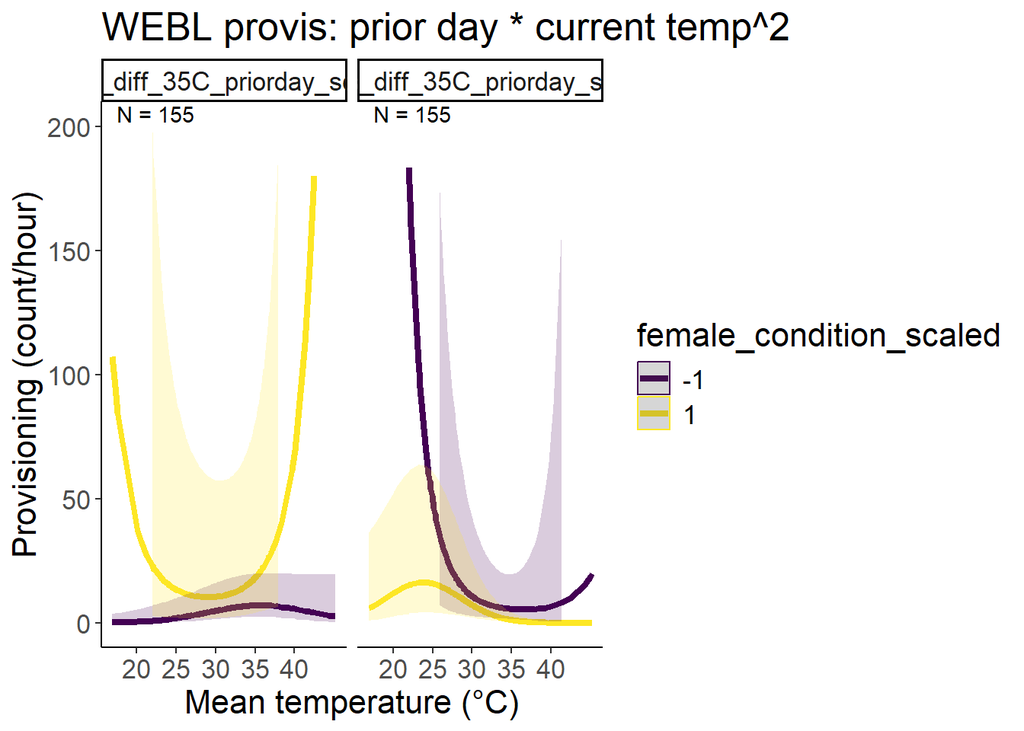

```r
data_webl_q2h2 = dplyr::filter(p,!is.na(mean_temp),
                                  # !is.na(julian_date),
                                  !is.na(mean_nestling_age),
                                  !is.na(deghours_diff_35C_priorday),
                                  !is.na(female_condition),
                                  !is.na(brood_size),
                                  !is.na(tod_h),
                                  !is.na(site),
                                  !is.na(attempt_id),
                                  !is.na(year_fct),
                                  species == "WEBL"# ,
                                                # tod >= hms::as.hms('11:00:00', tz = "America/Los_Angeles"),
                                                # tod_end <= hms::as.hms('17:00:00',tz = "America/Los_Angeles"),
                                                # tod_end >= hms::as.hms('11:00:00', tz = "America/Los_Angeles")
                                                ) %>%
                        mutate(across(c(tod_h,mean_temp,deghours_diff_35C_priorday,female_condition,julian_date,mean_nestling_age,brood_size),
                                                    ~ scale(.x)[,1],
                                                    .names = "{.col}_scaled"))


mean_temp_webl_q2h2 <- mean(data_webl_q2h2 %>% pull(mean_temp))
sd_temp_webl_q2h2 <- sd(data_webl_q2h2 %>% pull(mean_temp))


temp_trans_webl_q2h2 <- trans_new("temp_trans_webl_q2h2",
                             transform = function(x){(x * sd_temp_webl_q2h2) + mean_temp_webl_q2h2},
                             inverse = function(x){x})

(figq2h2_webl <- predict_response(m_webl_q2h2,terms = c("mean_temp_scaled [all]","female_condition_scaled [-1,1]","deghours_diff_35C_priorday_scaled [-2,2]")) %>%
    plot(line_size = 1.5,alpha = .2,limit_range = TRUE,colors = "viridis") +
    # scale_color_hue(labels = c("Low","High")) +
    # aes(linetype = .data[["group"]]) +
    theme_classic() +
    # facet_wrap(~ group, ncol = 2) +
    xlab("Mean temperature (\u00b0C)") +
    ylab("Provisioning (count/hour)") +
    # scale_fill_viridis(discrete = TRUE) +
    # scale_color_viridis(discrete = TRUE) +
    theme(text = element_text(size = 16)) +
    labs(title =  "WEBL provis: prior day * current temp^2") +
    scale_x_continuous(trans = temp_trans_webl_q2h2,
                       breaks = c((20-mean_temp_webl_q2h2)/sd_temp_webl_q2h2,
                                  (25-mean_temp_webl_q2h2)/sd_temp_webl_q2h2,
                                  (30-mean_temp_webl_q2h2)/sd_temp_webl_q2h2,
                                  (35-mean_temp_webl_q2h2)/sd_temp_webl_q2h2,
                                  (40-mean_temp_webl_q2h2)/sd_temp_webl_q2h2),
                       # breaks = c(20,30,40,50),
                       # labels = c("20","30","40","50"),
                       # limits = c((15-mean(g$meanmaxtempI,na.rm = TRUE))/sd(g$meanmaxtempI,na.rm = TRUE),
                       #            (55-mean(g$meanmaxtempI,na.rm = TRUE))/sd(g$meanmaxtempI,na.rm = TRUE))
                       # limits = c(18,5)
    ) +
    # scale_linetype_manual(values = "solid") +
    ylim(0,200) +
    geom_text(data = dat_text_webl_q2h2, mapping = aes(x = -Inf, y = Inf,label = label),hjust = -.2, vjust = 1.2,inherit.aes = FALSE) # +
    #theme(legend.position = "none")
)
```

```r
ggsave("../figures/provisbymaxtempxhab_WEBL_q2h2.png",plot =  figq2h2_webl, width = 10, height = 6.6)
```

### TRES

```r
m_TRES <- glmmTMB(valid_detections ~ poly(mean_temp_scaled,2) * deghours_diff_35C_priorday_scaled * female_condition_scaled + mean_nestling_age_scaled + brood_size_scaled + year_fct +  (1|site:attempt_id),
           family = nbinom2(),
           ziformula = ~ 1,
           data = dplyr::filter(p,!is.na(mean_temp),
                                  # !is.na(julian_date),
                                  !is.na(mean_nestling_age),
                                  !is.na(deghours_diff_35C_priorday),
                                  !is.na(female_condition),
                                  !is.na(brood_size),
                                  !is.na(tod_h),
                                  !is.na(site),
                                  !is.na(attempt_id),
                                  !is.na(year_fct),
                                  species == "TRES"# ,
                                                # tod >= hms::as.hms('11:00:00', tz = "America/Los_Angeles"),
                                                # tod_end <= hms::as.hms('17:00:00',tz = "America/Los_Angeles"),
                                                # tod_end >= hms::as.hms('11:00:00', tz = "America/Los_Angeles")
                                                ) %>%
                        mutate(across(c(tod_h,mean_temp,deghours_diff_35C_priorday,female_condition,julian_date,mean_nestling_age,brood_size),
                                                    ~ scale(.x)[,1],
                                                    .names = "{.col}_scaled")),
           )

m_TRES_deghxfc <- glmmTMB(valid_detections ~ poly(mean_temp_scaled,2) + deghours_diff_35C_priorday_scaled * female_condition_scaled + mean_nestling_age_scaled + brood_size_scaled + year_fct +  (1|site:attempt_id),
           family = nbinom2(),
           ziformula = ~ 1,
           data = dplyr::filter(p,!is.na(mean_temp),
                                  # !is.na(julian_date),
                                  !is.na(mean_nestling_age),
                                  !is.na(deghours_diff_35C_priorday),
                                  !is.na(female_condition),
                                  !is.na(brood_size),
                                  !is.na(tod_h),
                                  !is.na(site),
                                  !is.na(attempt_id),
                                  !is.na(year_fct),
                                  species == "TRES"# ,
                                                # tod >= hms::as.hms('11:00:00', tz = "America/Los_Angeles"),
                                                # tod_end <= hms::as.hms('17:00:00',tz = "America/Los_Angeles"),
                                                # tod_end >= hms::as.hms('11:00:00', tz = "America/Los_Angeles")
                                                ) %>%
                        mutate(across(c(tod_h,mean_temp,deghours_diff_35C_priorday,female_condition,julian_date,mean_nestling_age,brood_size),
                                                    ~ scale(.x)[,1],
                                                    .names = "{.col}_scaled")),
           )

m_TRES_mtxdegh <- glmmTMB(valid_detections ~ poly(mean_temp_scaled,2) * deghours_diff_35C_priorday_scaled + female_condition_scaled + mean_nestling_age_scaled + brood_size_scaled + year_fct +  (1|site:attempt_id),
           family = nbinom2(),
           ziformula = ~ 1,
           data = dplyr::filter(p,!is.na(mean_temp),
                                  # !is.na(julian_date),
                                  !is.na(mean_nestling_age),
                                  !is.na(deghours_diff_35C_priorday),
                                  !is.na(female_condition),
                                  !is.na(brood_size),
                                  !is.na(tod_h),
                                  !is.na(site),
                                  !is.na(attempt_id),
                                  !is.na(year_fct),
                                  species == "TRES"# ,
                                                # tod >= hms::as.hms('11:00:00', tz = "America/Los_Angeles"),
                                                # tod_end <= hms::as.hms('17:00:00',tz = "America/Los_Angeles"),
                                                # tod_end >= hms::as.hms('11:00:00', tz = "America/Los_Angeles")
                                                ) %>%
                        mutate(across(c(tod_h,mean_temp,deghours_diff_35C_priorday,female_condition,julian_date,mean_nestling_age,brood_size),
                                                    ~ scale(.x)[,1],
                                                    .names = "{.col}_scaled")),
           )

m_TRES_mtxfc <- glmmTMB(valid_detections ~ poly(mean_temp_scaled,2) * female_condition_scaled + deghours_diff_35C_priorday_scaled + mean_nestling_age_scaled + brood_size_scaled + year_fct +  (1|site:attempt_id),
           family = nbinom2(),
           ziformula = ~ 1,
           data = dplyr::filter(p,!is.na(mean_temp),
                                  # !is.na(julian_date),
                                  !is.na(mean_nestling_age),
                                  !is.na(deghours_diff_35C_priorday),
                                  !is.na(female_condition),
                                  !is.na(brood_size),
                                  !is.na(tod_h),
                                  !is.na(site),
                                  !is.na(attempt_id),
                                  !is.na(year_fct),
                                  species == "TRES"# ,
                                                # tod >= hms::as.hms('11:00:00', tz = "America/Los_Angeles"),
                                                # tod_end <= hms::as.hms('17:00:00',tz = "America/Los_Angeles"),
                                                # tod_end >= hms::as.hms('11:00:00', tz = "America/Los_Angeles")
                                                ) %>%
                        mutate(across(c(tod_h,mean_temp,deghours_diff_35C_priorday,female_condition,julian_date,mean_nestling_age,brood_size),
                                                    ~ scale(.x)[,1],
                                                    .names = "{.col}_scaled")),
           )

m_TRES_noint <- glmmTMB(valid_detections ~ poly(mean_temp_scaled,2) + deghours_diff_35C_priorday_scaled + female_condition_scaled + mean_nestling_age_scaled + brood_size_scaled + year_fct +  (1|site:attempt_id),
           family = nbinom2(),
           ziformula = ~ 1,
           data = dplyr::filter(p,!is.na(mean_temp),
                                  # !is.na(julian_date),
                                  !is.na(mean_nestling_age),
                                  !is.na(deghours_diff_35C_priorday),
                                  !is.na(female_condition),
                                  !is.na(brood_size),
                                  !is.na(tod_h),
                                  !is.na(site),
                                  !is.na(attempt_id),
                                  !is.na(year_fct),
                                  species == "TRES"# ,
                                                # tod >= hms::as.hms('11:00:00', tz = "America/Los_Angeles"),
                                                # tod_end <= hms::as.hms('17:00:00',tz = "America/Los_Angeles"),
                                                # tod_end >= hms::as.hms('11:00:00', tz = "America/Los_Angeles")
                                                ) %>%
                        mutate(across(c(tod_h,mean_temp,deghours_diff_35C_priorday,female_condition,julian_date,mean_nestling_age,brood_size),
                                                    ~ scale(.x)[,1],
                                                    .names = "{.col}_scaled")),
           )

c <- anova(m_TRES,m_TRES_mtxdegh,m_TRES_deghxfc,m_TRES_mtxfc) %>% tibble() %>% mutate(Model = c("Degree-hour * female condition","Mean temp * Degree-hour","Mean temp * female condition","Triple interaction"),.before = Df)

(tab <- c %>%
  as.tibble() %>%
  mutate(across(where(is.numeric),~round(.x,digits = 4)),
         P = `Pr(>Chisq)`) %>%
  dplyr::select(Model,AIC,Chisq,P) %>%
  mutate(across(c(AIC,Chisq), ~ round(.x, digits = 2)),
         P = if_else(P < 0.001,"<0.001",as.character(P))) %>% gt())
```

| Model | AIC | Chisq | P |
| --- | --- | --- | --- |
| Degree-hour * female condition | 1041.71 | NA | NA |
| Mean temp * Degree-hour | 1039.18 | 4.53 | 0.0333 |
| Mean temp * female condition | 1048.84 | 0.00 | 1 |
| Triple interaction | 1035.67 | 23.17 | <0.001 |

```r
gtsave(tab,"../figures/int_tab_provis_ch3_q2h2_tres_1.html")

c <- anova(m_TRES,m_TRES_mtxdegh) %>% tibble() %>% mutate(Model = c("Mean temp * Degree-hour","Triple interaction"),.before = Df)

(tab <- c %>%
  as.tibble() %>%
  mutate(across(where(is.numeric),~round(.x,digits = 4)),
         P = `Pr(>Chisq)`) %>%
  dplyr::select(Model,AIC,Chisq,P) %>%
  mutate(across(c(AIC,Chisq), ~ round(.x, digits = 2)),
         P = if_else(P < 0.001,"<0.001",as.character(P))) %>% gt())
```

| Model | AIC | Chisq | P |
| --- | --- | --- | --- |
| Mean temp * Degree-hour | 1039.18 | NA | NA |
| Triple interaction | 1035.67 | 13.51 | 0.019 |

```r
gtsave(tab,"../figures/int_tab_provis_ch3_q2h2_tres_2.html")

summary(m_TRES)
```

```
##  Family: nbinom2  ( log )
## Formula:
## valid_detections ~ poly(mean_temp_scaled, 2) * deghours_diff_35C_priorday_scaled *
##     female_condition_scaled + mean_nestling_age_scaled + brood_size_scaled +
##     year_fct + (1 | site:attempt_id)
## Zero inflation:                    ~1
## Data: dplyr::filter(p, !is.na(mean_temp), !is.na(mean_nestling_age),
##     !is.na(deghours_diff_35C_priorday), !is.na(female_condition),
##     !is.na(brood_size), !is.na(tod_h), !is.na(site), !is.na(attempt_id),
##     !is.na(year_fct), species == "TRES") %>% mutate(across(c(tod_h,
##     mean_temp, deghours_diff_35C_priorday, female_condition,
##     julian_date, mean_nestling_age, brood_size), ~scale(.x)[,
##     1], .names = "{.col}_scaled"))
##
##      AIC      BIC   logLik deviance df.resid
##   1035.7   1090.6   -499.8    999.7      138
##
## Random effects:
##
## Conditional model:
##  Groups          Name        Variance Std.Dev.
##  site:attempt_id (Intercept) 1.924    1.387
## Number of obs: 156, groups:  site:attempt_id, 14
##
## Dispersion parameter for nbinom2 family (): 4.08
##
## Conditional model:
##                                                                                      Estimate
## (Intercept)                                                                           2.65668
## poly(mean_temp_scaled, 2)1                                                            3.08359
## poly(mean_temp_scaled, 2)2                                                           -0.36140
## deghours_diff_35C_priorday_scaled                                                    -0.88455
## female_condition_scaled                                                               0.82947
## mean_nestling_age_scaled                                                              0.03944
## brood_size_scaled                                                                     1.33078
## year_fct2023                                                                         -0.95513
## poly(mean_temp_scaled, 2)1:deghours_diff_35C_priorday_scaled                          2.46677
## poly(mean_temp_scaled, 2)2:deghours_diff_35C_priorday_scaled                          2.88094
## poly(mean_temp_scaled, 2)1:female_condition_scaled                                   -2.41960
## poly(mean_temp_scaled, 2)2:female_condition_scaled                                    0.53910
```

[output cut: 60 more lines]

```
## poly(mean_temp_scaled, 2)1:deghours_diff_35C_priorday_scaled                         .
## poly(mean_temp_scaled, 2)2:deghours_diff_35C_priorday_scaled                         *
## poly(mean_temp_scaled, 2)1:female_condition_scaled
## poly(mean_temp_scaled, 2)2:female_condition_scaled
## deghours_diff_35C_priorday_scaled:female_condition_scaled                            **
## poly(mean_temp_scaled, 2)1:deghours_diff_35C_priorday_scaled:female_condition_scaled .
## poly(mean_temp_scaled, 2)2:deghours_diff_35C_priorday_scaled:female_condition_scaled
## ---
## Signif. codes:  0 '***' 0.001 '**' 0.01 '*' 0.05 '.' 0.1 ' ' 1
##
## Zero-inflation model:
##             Estimate Std. Error z value Pr(>|z|)
## (Intercept)  -2.1660     0.3044  -7.115 1.12e-12 ***
## ---
## Signif. codes:  0 '***' 0.001 '**' 0.01 '*' 0.05 '.' 0.1 ' ' 1
```

```r
m_tres_q2h2 <- m_TRES

check_zeroinflation(m_TRES)
```

```
## # Check for zero-inflation
##
##    Observed zeros: 29
##   Predicted zeros: 37
##             Ratio: 1.29
```

```
## Model is overfitting zeros (p = 0.416).
```

```r
# (t <- emtrends(m_tres_q1h1,specs = ~ habitat, var = c("mean_temp_scaled"),max.degree = 1) %>% test() %>%
#    mutate(across(where(is.numeric), ~ round(.x, digits = 3)),
#           df = round(df),
#           p.value = if_else(p.value == 0.000,"<0.001",as.character(p.value))) %>%
#    rename(Habitat = "habitat", `Max temp trend` = "mean_temp_scaled.trend",Df = "df", `Z-ratio` = "z.ratio", P = "p.value") %>%
#    #group_by(degree) %>%
#    gt())

ss_year_tres_provis_q2h2 <- m_tres_q2h2$frame %>%
  group_by(year_fct) %>%
  summarize(count_ind = n(),count_attempt = n_distinct(attempt_id)) %>%
  rowwise() %>%
  mutate(count = tibble(count_ind,count_attempt)) %>%
  dplyr::select(-c(count_ind, count_attempt)) %>%
  pivot_wider(values_from = count,names_from = year_fct) %>%
  as.tibble() %>% # rename(Habitat = 'habitat') %>%
  ungroup() %>%
  # mutate(`2021` = replace_na(`2021`,list(count_ind = 0,count_attempt = 0))) %>%
  mutate(Total = `2022` + `2023`) %>%
  rowwise() %>%
  mutate(`2022` = paste0(`2022`$count_ind,", ",`2022`$count_attempt),
         `2023` = paste0(`2023`$count_ind,", ",`2023`$count_attempt),
         Total = paste0(Total$count_ind,", ",Total$count_attempt)
  )

(t_ss_year_tres_provis_q2h2 <- ss_year_tres_provis_q2h2 %>% gt() %>%
    grand_summary_rows(fns = list(id = "Total") ~ {
      t <- str_split(.,", ",simplify = TRUE)
      t[,1] %>% as.numeric() %>% sum(na.rm = TRUE) %>% paste(t[,2] %>% as.numeric() %>% sum(na.rm = TRUE),sep = ", ")
    })
)
```

|  | 2022 | 2023 | Total |
| --- | --- | --- | --- |
|  | 68, 6 | 88, 8 | 156, 14 |
| Total | 68, 6 | 88, 8 | 156, 14 |

```r
t_ss_year_tres_provis_q2h2 %>% gtsave("../figures/ss_year_tres_provis_ch3_q2h2.html")

samp_q2h2 <- m_tres_q2h2$frame %>% summarize(count = n())
samp_q2h2 %>% gt() %>% gtsave("../figures/ss_tres_provis_ch3_q2h2.html")


dat_text_tres_q2h2 <- data.frame(
  label = paste("N =",samp_q2h2$count)# ,
  #group   = factor(c("Forest","Orchard","Grassland","Row crop"))
)

## num nestboxes
m_tres_q2h2$frame %>% pull(attempt_id) %>% unique() %>% length()
```

```
## [1] 14
```

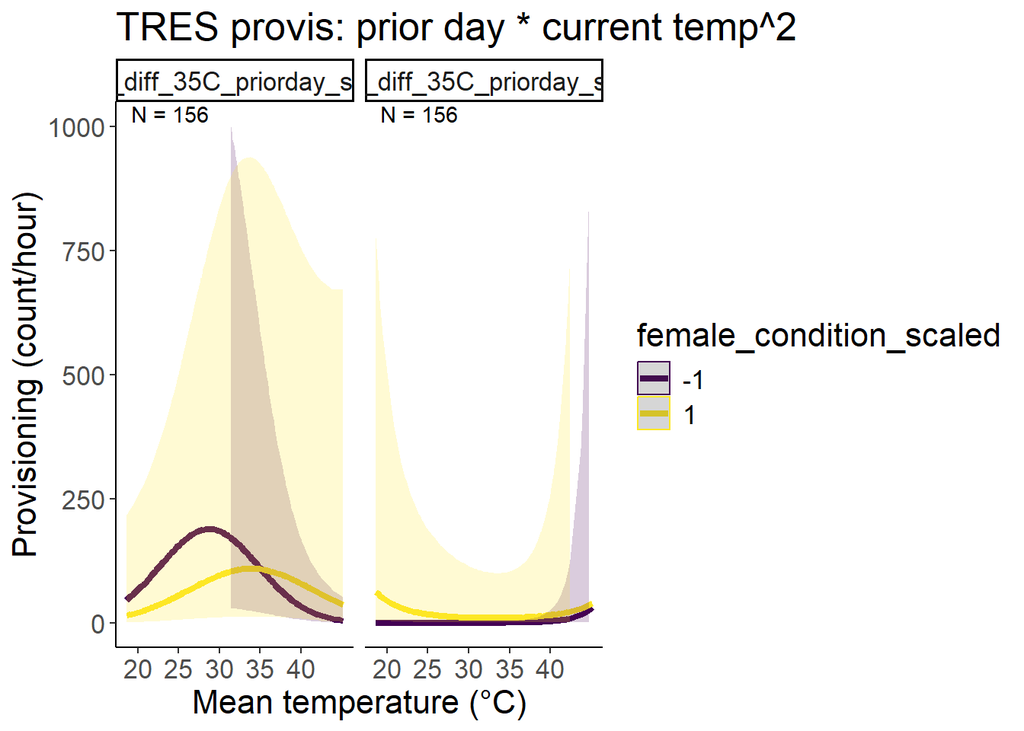

```r
data_tres_q2h2 = dplyr::filter(p,!is.na(mean_temp),
                                  # !is.na(julian_date),
                                  !is.na(mean_nestling_age),
                                  !is.na(deghours_diff_35C_priorday),
                                  !is.na(female_condition),
                                  !is.na(brood_size),
                                  !is.na(tod_h),
                                  !is.na(site),
                                  !is.na(attempt_id),
                                  !is.na(year_fct),
                                  species == "TRES"# ,
                                                # tod >= hms::as.hms('11:00:00', tz = "America/Los_Angeles"),
                                                # tod_end <= hms::as.hms('17:00:00',tz = "America/Los_Angeles"),
                                                # tod_end >= hms::as.hms('11:00:00', tz = "America/Los_Angeles")
                                                ) %>%
                        mutate(across(c(tod_h,mean_temp,deghours_diff_35C_priorday,female_condition,julian_date,mean_nestling_age,brood_size),
                                                    ~ scale(.x)[,1],
                                                    .names = "{.col}_scaled"))


mean_temp_tres_q2h2 <- mean(data_tres_q2h2 %>% pull(mean_temp))
sd_temp_tres_q2h2 <- sd(data_tres_q2h2 %>% pull(mean_temp))


temp_trans_tres_q2h2 <- trans_new("temp_trans_tres_q2h2",
                             transform = function(x){(x * sd_temp_tres_q2h2) + mean_temp_tres_q2h2},
                             inverse = function(x){x})

(figq2h2_tres <- predict_response(m_tres_q2h2,terms = c("mean_temp_scaled [all]","female_condition_scaled [-1,1]","deghours_diff_35C_priorday_scaled [-2,2]")) %>%
    plot(line_size = 1.5,alpha = .2,limit_range = TRUE,colors = "viridis") +
    # scale_color_hue(labels = c("Low","High")) +
    # aes(linetype = .data[["group"]]) +
    theme_classic() +
    # facet_wrap(~ group, ncol = 2) +
    xlab("Mean temperature (\u00b0C)") +
    ylab("Provisioning (count/hour)") +
    # scale_fill_viridis(discrete = TRUE) +
    # scale_color_viridis(discrete = TRUE) +
    theme(text = element_text(size = 16)) +
    labs(title =  "TRES provis: prior day * current temp^2") +
    scale_x_continuous(trans = temp_trans_tres_q2h2,
                       breaks = c((20-mean_temp_tres_q2h2)/sd_temp_tres_q2h2,
                                  (25-mean_temp_tres_q2h2)/sd_temp_tres_q2h2,
                                  (30-mean_temp_tres_q2h2)/sd_temp_tres_q2h2,
                                  (35-mean_temp_tres_q2h2)/sd_temp_tres_q2h2,
                                  (40-mean_temp_tres_q2h2)/sd_temp_tres_q2h2),
                       # breaks = c(20,30,40,50),
                       # labels = c("20","30","40","50"),
                       # limits = c((15-mean(g$meanmaxtempI,na.rm = TRUE))/sd(g$meanmaxtempI,na.rm = TRUE),
                       #            (55-mean(g$meanmaxtempI,na.rm = TRUE))/sd(g$meanmaxtempI,na.rm = TRUE))
                       # limits = c(18,5)
    ) +
    # scale_linetype_manual(values = "solid") +
    ylim(0,1000) +
    geom_text(data = dat_text_tres_q2h2, mapping = aes(x = -Inf, y = Inf,label = label),hjust = -.2, vjust = 1.2,inherit.aes = FALSE) # +
    #theme(legend.position = "none")
)
```

```r
ggsave("../figures/provisbymaxtempxhab_TRES_q2h2.png",plot =  figq2h2_tres, width = 10, height = 6.6)
```

I am a little sketched out by the TRES graph. Just seems too uncertain to trust.

## Q3H1

3. How does heat affect baseline and stress-induced?
1. H1: females that experienced heat over the prior day will be more likely to show elevated baseline corticosterone levels because they may upregulate their HPA axis in response to more challenging heat conditions
2. H2: females that experienced heat over the prior week will be more likely to show elevated stress-induced corticosterone levels because challenging environmental conditions are correlated with elevated stress-induced corticosterone levels.

First step is to make sure that I have the right temp measures for cort

```r
c <- read_rds("../data/cort_manytempmeasures.rds")
```

Now on to the modeling. I’m going to keep replicating the model structure from q1. Now instead of provisioning being the response, cort is the response.

### WEBL

#### Baseline cort (h1)

```r
m_WEBL <- lm(sqrt(mean_s1) ~ poly(maxt_prior_scaled,2) + brood_size_scaled + juliandate_scaled + year_fct + site,
           data = dplyr::filter(c,!is.na(maxt_prior),
                                  # !is.na(julian_date),
                                  !is.na(brood_size),
                                  !is.na(juliandate),
                                  !is.na(site),
                                  !is.na(attempt_id),
                                  !is.na(year),
                                  species == "WEBL"# ,
                                                # tod >= hms::as.hms('11:00:00', tz = "America/Los_Angeles"),
                                                # tod_end <= hms::as.hms('17:00:00',tz = "America/Los_Angeles"),
                                                # tod_end >= hms::as.hms('11:00:00', tz = "America/Los_Angeles")
                                                ) %>%
                        mutate(across(c(maxt_prior,juliandate,brood_size),
                                                    ~ scale(.x)[,1],
                                                    .names = "{.col}_scaled")),
           )



summary(m_WEBL)
```

```
##
## Call:
## lm(formula = sqrt(mean_s1) ~ poly(maxt_prior_scaled, 2) + brood_size_scaled +
##     juliandate_scaled + year_fct + site, data = dplyr::filter(c,
##     !is.na(maxt_prior), !is.na(brood_size), !is.na(juliandate),
##     !is.na(site), !is.na(attempt_id), !is.na(year), species ==
##         "WEBL") %>% mutate(across(c(maxt_prior, juliandate, brood_size),
##     ~scale(.x)[, 1], .names = "{.col}_scaled")))
##
## Residuals:
##      Min       1Q   Median       3Q      Max
## -0.91732 -0.25553 -0.03333  0.25553  0.86415
##
## Coefficients:
##                             Estimate Std. Error t value Pr(>|t|)
## (Intercept)                   1.9809     0.2711   7.308 5.94e-06 ***
## poly(maxt_prior_scaled, 2)1  -0.3192     1.2153  -0.263   0.7969
## poly(maxt_prior_scaled, 2)2   1.2281     0.8250   1.489   0.1604
## brood_size_scaled             0.3247     0.1585   2.049   0.0612 .
## juliandate_scaled             0.1219     0.2397   0.509   0.6195
## year_fct2023                 -0.1794     0.4022  -0.446   0.6628
## sitePG                        0.5972     0.3623   1.648   0.1233
## siteRR                        0.4502     0.5328   0.845   0.4134
## ---
## Signif. codes:  0 '***' 0.001 '**' 0.01 '*' 0.05 '.' 0.1 ' ' 1
##
## Residual standard error: 0.6044 on 13 degrees of freedom
##   (9 observations deleted due to missingness)
## Multiple R-squared:  0.4701, Adjusted R-squared:  0.1848
## F-statistic: 1.648 on 7 and 13 DF,  p-value: 0.2073
```

```r
m_webl_q3h1 <- m_WEBL

(t <- emtrends(m_webl_q3h1, var = c("maxt_prior_scaled"),max.degree = 1) %>% test() %>%
   mutate(across(where(is.numeric), ~ round(.x, digits = 3)),
          df = round(df),
          p.value = if_else(p.value == 0.000,"<0.001",as.character(p.value))) %>%
   rename(`Max temp trend` = "maxt_prior_scaled.trend",Df = "df", `T-ratio` = "t.ratio", P = "p.value") %>%
   #group_by(degree) %>%
   gt())
```

| maxt_prior_scaled | brood_size_scaled | juliandate_scaled | year_fct | site | Max temp trend | SE | Df | T-ratio | P |
| --- | --- | --- | --- | --- | --- | --- | --- | --- | --- |
| -0.165 | -0.126 | 0.05 | 2022 | MB | -0.088 | 0.222 | 13 | -0.394 | 0.7 |
| -0.165 | -0.126 | 0.05 | 2023 | MB | -0.088 | 0.222 | 13 | -0.394 | 0.7 |
| -0.165 | -0.126 | 0.05 | 2022 | PG | -0.088 | 0.222 | 13 | -0.394 | 0.7 |
| -0.165 | -0.126 | 0.05 | 2023 | PG | -0.088 | 0.222 | 13 | -0.394 | 0.7 |
| -0.165 | -0.126 | 0.05 | 2022 | RR | -0.088 | 0.222 | 13 | -0.394 | 0.7 |
| -0.165 | -0.126 | 0.05 | 2023 | RR | -0.088 | 0.222 | 13 | -0.394 | 0.7 |

```r
gtsave(t,"../figures/weblprovistrend_ch3_q3h1.html")

data_webl_q3h1 = dplyr::filter(c,!is.na(maxt_prior),
                                  # !is.na(julian_date),
                                  !is.na(brood_size),
                                  !is.na(juliandate),
                                  !is.na(site),
                                  !is.na(attempt_id),
                                  !is.na(year),
                                  species == "WEBL"# ,
                                                # tod >= hms::as.hms('11:00:00', tz = "America/Los_Angeles"),
                                                # tod_end <= hms::as.hms('17:00:00',tz = "America/Los_Angeles"),
                                                # tod_end >= hms::as.hms('11:00:00', tz = "America/Los_Angeles")
                                                ) %>%
                        mutate(across(c(maxt_prior,juliandate,brood_size),
                                                    ~ scale(.x)[,1],
                                                    .names = "{.col}_scaled"))

ss_year_webl_q3h1 <- data_webl_q3h1 %>%
  group_by(habitat,year_fct) %>%
  summarize(count_ind = n(),count_attempt = n_distinct(attempt_id)) %>%
  rowwise() %>%
  mutate(count = tibble(count_ind,count_attempt)) %>%
  dplyr::select(-c(count_ind, count_attempt)) %>%
  pivot_wider(values_from = count,names_from = year_fct) %>%
  as.tibble() %>% rename(Habitat = 'habitat') %>%
  ungroup() %>%
  # mutate(`2021` = replace_na(`2021`,list(count_ind = 0,count_attempt = 0))) %>%
  mutate(Total = `2022` + `2023`) %>%
  rowwise() %>%
  mutate(`2022` = paste0(`2022`$count_ind,", ",`2022`$count_attempt),
         `2023` = paste0(`2023`$count_ind,", ",`2023`$count_attempt),
         Total = paste0(Total$count_ind,", ",Total$count_attempt)
  )
(t_ss_year_webl_q3h1 <- ss_year_webl_q3h1 %>% gt() %>%
    grand_summary_rows(columns = -c(Habitat),fns = list(id = "Total") ~ {
      t <- str_split(.,", ",simplify = TRUE)
      t[,1] %>% as.numeric() %>% sum(na.rm = TRUE) %>% paste(t[,2] %>% as.numeric() %>% sum(na.rm = TRUE),sep = ", ")
    })
)
```

|  | Habitat | 2022 | 2023 | Total |
| --- | --- | --- | --- | --- |
|  | Forest | 3, 3 | 7, 6 | 10, 9 |
|  | Orchard | 5, 5 | 4, 3 | 9, 8 |
|  | Grassland | 3, 3 | 4, 3 | 7, 6 |
|  | Row crop | 2, 2 | 2, 2 | 4, 4 |
| Total | — | 13, 13 | 17, 14 | 30, 27 |

```r
t_ss_year_webl_q3h1 %>% gtsave("../figures/ss_year_webl_provis_ch3_q3h1.html")

samp <- data_webl_q3h1 %>% summarize(count = n())
samp %>% gt() %>% gtsave("../figures/ss_webl_ch3_q3h1.html")


dat_text_webl_q3h1 <- data.frame(
  label = paste("N =",samp$count),
  group   = factor(c("Forest","Orchard","Grassland","Row crop"))
)

## num nestboxes
data_webl_q3h1 %>% pull(attempt_id) %>% unique() %>% length()
```

```
## [1] 27
```

```
## Model has sqrt-transformed response. Back-transforming predictions to
##   original response scale. Standard errors are still on the transformed
## Data points may overlap. Use the `jitter` argument to add some amount of
##   random variation to the location of data points and avoid overplotting.
```

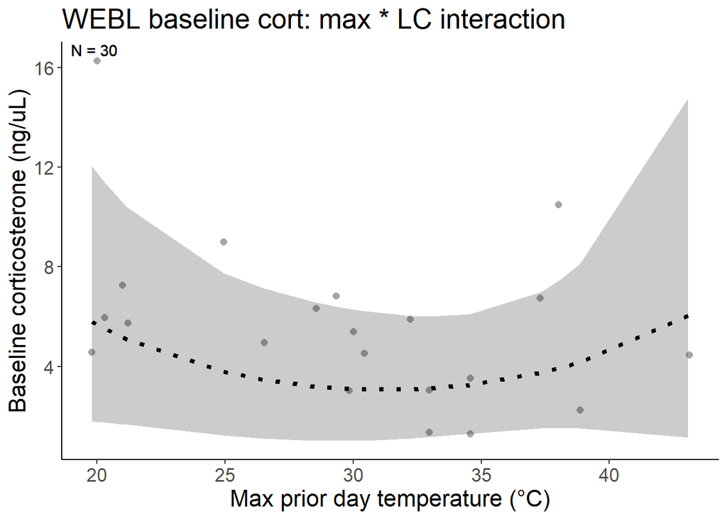

```r
mean_temp_webl_q3h1 <- mean(data_webl_q3h1 %>% pull(maxt_prior))
sd_temp_webl_q3h1 <- sd(data_webl_q3h1 %>% pull(maxt_prior))


temp_trans_webl_q3h1 <- trans_new("temp_trans_webl_q3h1",
                             transform = function(x){(x * sd_temp_webl_q3h1) + mean_temp_webl_q3h1},
                             inverse = function(x){x})

(figq3h1_webl <- predict_response(m_webl_q3h1,terms = c("maxt_prior_scaled [all]")) %>%
    plot(line_size = 1.5,alpha = .2,show_data = TRUE,limit_range = TRUE) +
    aes(linetype = .data[["group"]]) +
    theme_classic() +
    # facet_wrap(~ group, ncol = 2) +
    xlab("Max prior day temperature (\u00b0C)") +
    ylab("Baseline corticosterone (ng/uL)") +
    scale_fill_viridis(discrete = TRUE) +
    scale_color_viridis(discrete = TRUE) +
    theme(text = element_text(size = 16)) +
    labs(title =  "WEBL baseline cort: max * LC interaction") +
    scale_x_continuous(trans = temp_trans_webl_q3h1,
                       breaks = c((20-mean_temp_webl_q3h1)/sd_temp_webl_q3h1,
                                  (25-mean_temp_webl_q3h1)/sd_temp_webl_q3h1,
                                  (30-mean_temp_webl_q3h1)/sd_temp_webl_q3h1,
                                  (35-mean_temp_webl_q3h1)/sd_temp_webl_q3h1,
                                  (40-mean_temp_webl_q3h1)/sd_temp_webl_q3h1),
                       # breaks = c(20,30,40,50),
                       # labels = c("20","30","40","50"),
                       # limits = c((15-mean(g$meanmaxtempI,na.rm = TRUE))/sd(g$meanmaxtempI,na.rm = TRUE),
                       #            (55-mean(g$meanmaxtempI,na.rm = TRUE))/sd(g$meanmaxtempI,na.rm = TRUE))
                       # limits = c(18,5)
    ) +
    scale_linetype_manual(values = "dotted") +
    #ylim(-5,5) +
    geom_text(data = dat_text_webl_q3h1, mapping = aes(x = -Inf, y = Inf,label = label),hjust = -.2, vjust = 1.2,inherit.aes = FALSE) +
    theme(legend.position = "none")
)
```

```r
ggsave("../figures/provisbymaxtempxhab_WEBL_q3h1.png",plot =  figq3h1_webl, width = 10, height = 6.6)
```

#### Stress-induced cort (h2)

```r
m_WEBL <- lm(sqrt(mean_s2) ~ poly(maxt_week_scaled,2) + brood_size_scaled + juliandate_scaled + year_fct + site,
           data = dplyr::filter(c,!is.na(maxt_week),
                                  # !is.na(julian_date),
                                  !is.na(brood_size),
                                  !is.na(juliandate),
                                  !is.na(site),
                                  !is.na(attempt_id),
                                  !is.na(year),
                                  species == "WEBL"# ,
                                                # tod >= hms::as.hms('11:00:00', tz = "America/Los_Angeles"),
                                                # tod_end <= hms::as.hms('17:00:00',tz = "America/Los_Angeles"),
                                                # tod_end >= hms::as.hms('11:00:00', tz = "America/Los_Angeles")
                                                ) %>%
                        mutate(across(c(maxt_week,juliandate,brood_size),
                                                    ~ scale(.x)[,1],
                                                    .names = "{.col}_scaled")),
           )


summary(m_WEBL)
```

```
##
## Call:
## lm(formula = sqrt(mean_s2) ~ poly(maxt_week_scaled, 2) + brood_size_scaled +
##     juliandate_scaled + year_fct + site, data = dplyr::filter(c,
##     !is.na(maxt_week), !is.na(brood_size), !is.na(juliandate),
##     !is.na(site), !is.na(attempt_id), !is.na(year), species ==
##         "WEBL") %>% mutate(across(c(maxt_week, juliandate, brood_size),
##     ~scale(.x)[, 1], .names = "{.col}_scaled")))
##
## Residuals:
##      Min       1Q   Median       3Q      Max
## -2.17537 -0.26452  0.00826  0.54714  2.14982
##
## Coefficients:
##                            Estimate Std. Error t value Pr(>|t|)
## (Intercept)                  5.7369     0.4682  12.253 7.31e-10 ***
## poly(maxt_week_scaled, 2)1  -6.0028     1.5002  -4.001 0.000925 ***
## poly(maxt_week_scaled, 2)2   0.4530     1.3254   0.342 0.736724
## brood_size_scaled           -0.0296     0.2643  -0.112 0.912141
## juliandate_scaled            0.9645     0.3668   2.629 0.017581 *
## year_fct2023                -1.5369     0.5616  -2.736 0.014065 *
## sitePG                       0.2413     0.5449   0.443 0.663434
## siteRR                      -0.7047     0.7760  -0.908 0.376498
## ---
## Signif. codes:  0 '***' 0.001 '**' 0.01 '*' 0.05 '.' 0.1 ' ' 1
##
## Residual standard error: 1.09 on 17 degrees of freedom
##   (5 observations deleted due to missingness)
## Multiple R-squared:  0.6372, Adjusted R-squared:  0.4878
## F-statistic: 4.265 on 7 and 17 DF,  p-value: 0.00686
```

```r
m_webl_q3h2 <- m_WEBL


(t <- emtrends(m_webl_q3h2, var = c("maxt_week_scaled"),max.degree = 1) %>% test() %>%
   mutate(across(where(is.numeric), ~ round(.x, digits = 3)),
          df = round(df),
          p.value = if_else(p.value == 0.000,"<0.001",as.character(p.value))) %>%
   rename(`Max temp trend` = "maxt_week_scaled.trend",Df = "df", `T-ratio` = "t.ratio", P = "p.value") %>%
   #group_by(degree) %>%
   gt())
```

| maxt_week_scaled | brood_size_scaled | juliandate_scaled | year_fct | site | Max temp trend | SE | Df | T-ratio | P |
| --- | --- | --- | --- | --- | --- | --- | --- | --- | --- |
| -0.059 | 0.102 | -0.175 | 2022 | MB | -1.15 | 0.28 | 17 | -4.107 | 0.001 |
| -0.059 | 0.102 | -0.175 | 2023 | MB | -1.15 | 0.28 | 17 | -4.107 | 0.001 |
| -0.059 | 0.102 | -0.175 | 2022 | PG | -1.15 | 0.28 | 17 | -4.107 | 0.001 |
| -0.059 | 0.102 | -0.175 | 2023 | PG | -1.15 | 0.28 | 17 | -4.107 | 0.001 |
| -0.059 | 0.102 | -0.175 | 2022 | RR | -1.15 | 0.28 | 17 | -4.107 | 0.001 |
| -0.059 | 0.102 | -0.175 | 2023 | RR | -1.15 | 0.28 | 17 | -4.107 | 0.001 |

```r
gtsave(t,"../figures/weblprovistrend_ch3_q3h2.html")

data_webl_q3h2 = dplyr::filter(c,!is.na(maxt_week),
                                  # !is.na(julian_date),
                                  !is.na(brood_size),
                                  !is.na(juliandate),
                                  !is.na(site),
                                  !is.na(attempt_id),
                                  !is.na(year),
                                  species == "WEBL"# ,
                                                # tod >= hms::as.hms('11:00:00', tz = "America/Los_Angeles"),
                                                # tod_end <= hms::as.hms('17:00:00',tz = "America/Los_Angeles"),
                                                # tod_end >= hms::as.hms('11:00:00', tz = "America/Los_Angeles")
                                                ) %>%
                        mutate(across(c(maxt_week,juliandate,brood_size),
                                                    ~ scale(.x)[,1],
                                                    .names = "{.col}_scaled"))

ss_year_webl_q3h2 <- data_webl_q3h2 %>%
  group_by(habitat,year_fct) %>%
  summarize(count_ind = n(),count_attempt = n_distinct(attempt_id)) %>%
  rowwise() %>%
  mutate(count = tibble(count_ind,count_attempt)) %>%
  dplyr::select(-c(count_ind, count_attempt)) %>%
  pivot_wider(values_from = count,names_from = year_fct) %>%
  as.tibble() %>% rename(Habitat = 'habitat') %>%
  ungroup() %>%
  # mutate(`2021` = replace_na(`2021`,list(count_ind = 0,count_attempt = 0))) %>%
  mutate(Total = `2022` + `2023`) %>%
  rowwise() %>%
  mutate(`2022` = paste0(`2022`$count_ind,", ",`2022`$count_attempt),
         `2023` = paste0(`2023`$count_ind,", ",`2023`$count_attempt),
         Total = paste0(Total$count_ind,", ",Total$count_attempt)
  )
(t_ss_year_webl_q3h2 <- ss_year_webl_q3h2 %>% gt() %>%
    grand_summary_rows(columns = -c(Habitat),fns = list(id = "Total") ~ {
      t <- str_split(.,", ",simplify = TRUE)
      t[,1] %>% as.numeric() %>% sum(na.rm = TRUE) %>% paste(t[,2] %>% as.numeric() %>% sum(na.rm = TRUE),sep = ", ")
    })
)
```

|  | Habitat | 2022 | 2023 | Total |
| --- | --- | --- | --- | --- |
|  | Forest | 3, 3 | 7, 6 | 10, 9 |
|  | Orchard | 5, 5 | 4, 3 | 9, 8 |
|  | Grassland | 3, 3 | 4, 3 | 7, 6 |
|  | Row crop | 2, 2 | 2, 2 | 4, 4 |
| Total | — | 13, 13 | 17, 14 | 30, 27 |

```r
t_ss_year_webl_q3h2 %>% gtsave("../figures/ss_year_webl_ch3_q3h2.html")

samp <- data_webl_q3h2 %>% summarize(count = n())
samp %>% gt() %>% gtsave("../figures/ss_webl_ch3_q3h2.html")


dat_text_webl_q3h2 <- data.frame(
  label = paste("N =",samp$count),
  group   = factor(c("Forest","Orchard","Grassland","Row crop"))
)

## num nestboxes
data_webl_q3h2 %>% pull(attempt_id) %>% unique() %>% length()
```

```
## [1] 27
```

```
## Model has sqrt-transformed response. Back-transforming predictions to
##   original response scale. Standard errors are still on the transformed
## Data points may overlap. Use the `jitter` argument to add some amount of
##   random variation to the location of data points and avoid overplotting.
```

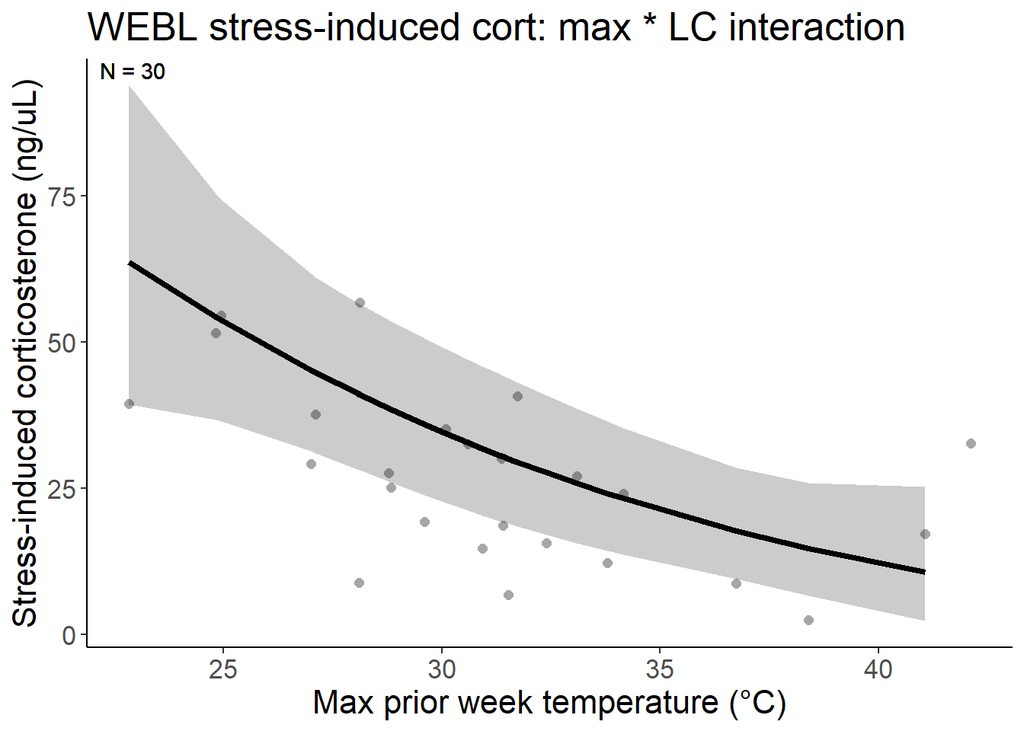

```r
mean_temp_webl_q3h2 <- mean(data_webl_q3h2 %>% pull(maxt_week))
sd_temp_webl_q3h2 <- sd(data_webl_q3h2 %>% pull(maxt_week))


temp_trans_webl_q3h2 <- trans_new("temp_trans_webl_q3h2",
                             transform = function(x){(x * sd_temp_webl_q3h2) + mean_temp_webl_q3h2},
                             inverse = function(x){x})

(figq3h2_webl <- predict_response(m_webl_q3h2,terms = c("maxt_week_scaled [all]")) %>%
    plot(line_size = 1.5,alpha = .2,show_data = TRUE,limit_range = TRUE) +
    aes(linetype = .data[["group"]]) +
    theme_classic() +
    # facet_wrap(~ group, ncol = 2) +
    xlab("Max prior week temperature (\u00b0C)") +
    ylab("Stress-induced corticosterone (ng/uL)") +
    scale_fill_viridis(discrete = TRUE) +
    scale_color_viridis(discrete = TRUE) +
    theme(text = element_text(size = 16)) +
    labs(title =  "WEBL stress-induced cort: max * LC interaction") +
    scale_x_continuous(trans = temp_trans_webl_q3h2,
                       breaks = c((20-mean_temp_webl_q3h2)/sd_temp_webl_q3h2,
                                  (25-mean_temp_webl_q3h2)/sd_temp_webl_q3h2,
                                  (30-mean_temp_webl_q3h2)/sd_temp_webl_q3h2,
                                  (35-mean_temp_webl_q3h2)/sd_temp_webl_q3h2,
                                  (40-mean_temp_webl_q3h2)/sd_temp_webl_q3h2),
                       # breaks = c(20,30,40,50),
                       # labels = c("20","30","40","50"),
                       # limits = c((15-mean(g$meanmaxtempI,na.rm = TRUE))/sd(g$meanmaxtempI,na.rm = TRUE),
                       #            (55-mean(g$meanmaxtempI,na.rm = TRUE))/sd(g$meanmaxtempI,na.rm = TRUE))
                       # limits = c(18,5)
    ) +
    scale_linetype_manual(values = "solid") +
    #ylim(-5,5) +
    geom_text(data = dat_text_webl_q3h2, mapping = aes(x = -Inf, y = Inf,label = label),hjust = -.2, vjust = 1.2,inherit.aes = FALSE) +
    theme(legend.position = "none")
)
```

```r
ggsave("../figures/provisbymaxtempxhab_WEBL_q3h2.png",plot =  figq3h2_webl, width = 10, height = 6.6)
```

### TRES

#### Baseline cort (h1)

```r
m_TRES <- lm(sqrt(mean_s1) ~ poly(maxt_prior_scaled,2) + brood_size_scaled + juliandate_scaled + year_fct + site,
           data = dplyr::filter(c,!is.na(maxt_prior),
                                  # !is.na(julian_date),
                                  !is.na(brood_size),
                                  !is.na(juliandate),
                                  !is.na(site),
                                  !is.na(attempt_id),
                                  !is.na(year),
                                  species == "TRES"# ,
                                                # tod >= hms::as.hms('11:00:00', tz = "America/Los_Angeles"),
                                                # tod_end <= hms::as.hms('17:00:00',tz = "America/Los_Angeles"),
                                                # tod_end >= hms::as.hms('11:00:00', tz = "America/Los_Angeles")
                                                ) %>%
                        mutate(across(c(maxt_prior,juliandate,brood_size),
                                                    ~ scale(.x)[,1],
                                                    .names = "{.col}_scaled")),
           )



summary(m_TRES)
```

```
##
## Call:
## lm(formula = sqrt(mean_s1) ~ poly(maxt_prior_scaled, 2) + brood_size_scaled +
##     juliandate_scaled + year_fct + site, data = dplyr::filter(c,
##     !is.na(maxt_prior), !is.na(brood_size), !is.na(juliandate),
##     !is.na(site), !is.na(attempt_id), !is.na(year), species ==
##         "TRES") %>% mutate(across(c(maxt_prior, juliandate, brood_size),
##     ~scale(.x)[, 1], .names = "{.col}_scaled")))
##
## Residuals:
##        1        2        3        4        5        6        7        8
##  0.39349 -0.41358 -0.25077  0.39647  0.05549 -0.20118 -0.40796  0.16007
##        9       10       11       12       13
## -0.39349 -0.09376  0.37829  0.09078  0.28616
##
## Coefficients:
##                             Estimate Std. Error t value Pr(>|t|)
## (Intercept)                   0.9621     1.0150   0.948    0.387
## poly(maxt_prior_scaled, 2)1  -1.1312     0.6577  -1.720    0.146
## poly(maxt_prior_scaled, 2)2  -0.5608     0.8422  -0.666    0.535
## brood_size_scaled            -0.1815     0.3498  -0.519    0.626
## juliandate_scaled            -0.7679     0.8235  -0.932    0.394
## year_fct2023                  1.2980     1.3780   0.942    0.389
## sitePG                        0.6281     0.4847   1.296    0.252
## siteRR                        0.6235     0.5211   1.197    0.285
##
## Residual standard error: 0.4855 on 5 degrees of freedom
## Multiple R-squared:  0.5519, Adjusted R-squared:  -0.0754
## F-statistic: 0.8798 on 7 and 5 DF,  p-value: 0.5776
```

```r
m_tres_q3h1 <- m_TRES

(t <- emtrends(m_tres_q3h1, var = c("maxt_prior_scaled"),max.degree = 1) %>% test() %>%
   mutate(across(where(is.numeric), ~ round(.x, digits = 3)),
          df = round(df),
          p.value = if_else(p.value == 0.000,"<0.001",as.character(p.value))) %>%
   rename(`Max temp trend` = "maxt_prior_scaled.trend",Df = "df", `T-ratio` = "t.ratio", P = "p.value") %>%
   #group_by(degree) %>%
   gt())
```

| maxt_prior_scaled | brood_size_scaled | juliandate_scaled | year_fct | site | Max temp trend | SE | Df | T-ratio | P |
| --- | --- | --- | --- | --- | --- | --- | --- | --- | --- |
| 0 | 0 | 0 | 2022 | MB | -0.336 | 0.192 | 5 | -1.75 | 0.141 |
| 0 | 0 | 0 | 2023 | MB | -0.336 | 0.192 | 5 | -1.75 | 0.141 |
| 0 | 0 | 0 | 2022 | PG | -0.336 | 0.192 | 5 | -1.75 | 0.141 |
| 0 | 0 | 0 | 2023 | PG | -0.336 | 0.192 | 5 | -1.75 | 0.141 |
| 0 | 0 | 0 | 2022 | RR | -0.336 | 0.192 | 5 | -1.75 | 0.141 |
| 0 | 0 | 0 | 2023 | RR | -0.336 | 0.192 | 5 | -1.75 | 0.141 |

```r
gtsave(t,"../figures/tresprovistrend_ch3_q3h1.html")

data_tres_q3h1 = dplyr::filter(c,!is.na(maxt_prior),
                                  # !is.na(julian_date),
                                  !is.na(brood_size),
                                  !is.na(juliandate),
                                  !is.na(site),
                                  !is.na(attempt_id),
                                  !is.na(year),
                                  species == "TRES"# ,
                                                # tod >= hms::as.hms('11:00:00', tz = "America/Los_Angeles"),
                                                # tod_end <= hms::as.hms('17:00:00',tz = "America/Los_Angeles"),
                                                # tod_end >= hms::as.hms('11:00:00', tz = "America/Los_Angeles")
                                                ) %>%
                        mutate(across(c(maxt_prior,juliandate,brood_size),
                                                    ~ scale(.x)[,1],
                                                    .names = "{.col}_scaled"))

ss_year_tres_q3h1 <- data_tres_q3h1 %>%
  group_by(habitat,year_fct) %>%
  summarize(count_ind = n(),count_attempt = n_distinct(attempt_id)) %>%
  rowwise() %>%
  mutate(count = tibble(count_ind,count_attempt)) %>%
  dplyr::select(-c(count_ind, count_attempt)) %>%
  pivot_wider(values_from = count,names_from = year_fct) %>%
  as.tibble() %>% rename(Habitat = 'habitat') %>%
  ungroup() %>%
  # mutate(`2021` = replace_na(`2021`,list(count_ind = 0,count_attempt = 0))) %>%
  mutate(Total = `2022` + `2023`) %>%
  rowwise() %>%
  mutate(`2022` = paste0(`2022`$count_ind,", ",`2022`$count_attempt),
         `2023` = paste0(`2023`$count_ind,", ",`2023`$count_attempt),
         Total = paste0(Total$count_ind,", ",Total$count_attempt)
  )
(t_ss_year_tres_q3h1 <- ss_year_tres_q3h1 %>% gt() %>%
    grand_summary_rows(columns = -c(Habitat),fns = list(id = "Total") ~ {
      t <- str_split(.,", ",simplify = TRUE)
      t[,1] %>% as.numeric() %>% sum(na.rm = TRUE) %>% paste(t[,2] %>% as.numeric() %>% sum(na.rm = TRUE),sep = ", ")
    })
)
```

|  | Habitat | 2022 | 2023 | Total |
| --- | --- | --- | --- | --- |
|  | Forest | 1, 1 | 2, 2 | 3, 3 |
|  | Orchard | 1, 1 | NA, NA | NA, NA |
|  | Grassland | 2, 2 | 3, 3 | 5, 5 |
|  | Row crop | NA, NA | 4, 4 | NA, NA |
| Total | — | 4, 4 | 9, 9 | 8, 8 |

```r
t_ss_year_tres_q3h1 %>% gtsave("../figures/ss_year_tres_provis_ch3_q3h1.html")
samp <- data_tres_q3h1 %>% summarize(count = n())
samp %>% gt() %>% gtsave("../figures/ss_tres_ch3_q3h1.html")


dat_text_tres_q3h1 <- data.frame(
  label = paste("N =",samp$count),
  group   = factor(c("Forest","Orchard","Grassland","Row crop"))
)

## num nestboxes
data_tres_q3h1 %>% pull(attempt_id) %>% unique() %>% length()
```

```
## [1] 13
```

```
## Model has sqrt-transformed response. Back-transforming predictions to
##   original response scale. Standard errors are still on the transformed
## Data points may overlap. Use the `jitter` argument to add some amount of
##   random variation to the location of data points and avoid overplotting.
```

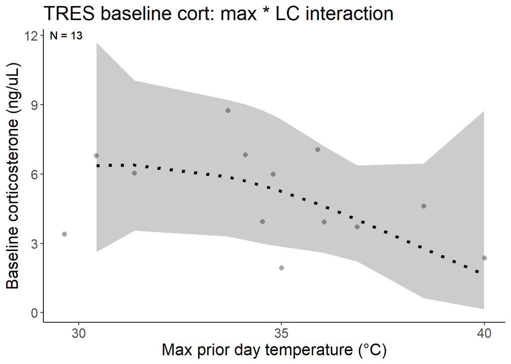

```r
mean_temp_tres_q3h1 <- mean(data_tres_q3h1 %>% pull(maxt_prior))
sd_temp_tres_q3h1 <- sd(data_tres_q3h1 %>% pull(maxt_prior))


temp_trans_tres_q3h1 <- trans_new("temp_trans_tres_q3h1",
                             transform = function(x){(x * sd_temp_tres_q3h1) + mean_temp_tres_q3h1},
                             inverse = function(x){x})

(figq3h1_tres <- predict_response(m_tres_q3h1,terms = c("maxt_prior_scaled [all]"),margin = "empirical") %>%
    plot(line_size = 1.5,alpha = .2,show_data = TRUE,limit_range = TRUE) +
    aes(linetype = .data[["group"]]) +
    theme_classic() +
    # facet_wrap(~ group, ncol = 2) +
    xlab("Max prior day temperature (\u00b0C)") +
    ylab("Baseline corticosterone (ng/uL)") +
    scale_fill_viridis(discrete = TRUE) +
    scale_color_viridis(discrete = TRUE) +
    theme(text = element_text(size = 16)) +
    labs(title =  "TRES baseline cort: max * LC interaction") +
    scale_x_continuous(trans = temp_trans_tres_q3h1,
                       breaks = c((20-mean_temp_tres_q3h1)/sd_temp_tres_q3h1,
                                  (25-mean_temp_tres_q3h1)/sd_temp_tres_q3h1,
                                  (30-mean_temp_tres_q3h1)/sd_temp_tres_q3h1,
                                  (35-mean_temp_tres_q3h1)/sd_temp_tres_q3h1,
                                  (40-mean_temp_tres_q3h1)/sd_temp_tres_q3h1),
                       # breaks = c(20,30,40,50),
                       # labels = c("20","30","40","50"),
                       # limits = c((15-mean(g$meanmaxtempI,na.rm = TRUE))/sd(g$meanmaxtempI,na.rm = TRUE),
                       #            (55-mean(g$meanmaxtempI,na.rm = TRUE))/sd(g$meanmaxtempI,na.rm = TRUE))
                       # limits = c(18,5)
    ) +
    scale_linetype_manual(values = "dotted") +
    #ylim(-5,5) +
    geom_text(data = dat_text_tres_q3h1, mapping = aes(x = -Inf, y = Inf,label = label),hjust = -.2, vjust = 1.2,inherit.aes = FALSE) +
    theme(legend.position = "none")
)
```

```r
ggsave("../figures/provisbymaxtempxhab_TRES_q3h1.png",plot =  figq3h1_tres, width = 10, height = 6.6)
```

wonk

#### Stress-induced cort (h2)

```r
m_TRES <- lm(sqrt(mean_s2) ~ poly(maxt_week_scaled,2) + brood_size_scaled + juliandate_scaled + year_fct + site,
           data = dplyr::filter(c,!is.na(maxt_week),
                                  # !is.na(julian_date),
                                  !is.na(brood_size),
                                  !is.na(juliandate),
                                  !is.na(site),
                                  !is.na(attempt_id),
                                  !is.na(year),
                                  species == "TRES"# ,
                                                # tod >= hms::as.hms('11:00:00', tz = "America/Los_Angeles"),
                                                # tod_end <= hms::as.hms('17:00:00',tz = "America/Los_Angeles"),
                                                # tod_end >= hms::as.hms('11:00:00', tz = "America/Los_Angeles")
                                                ) %>%
                        mutate(across(c(maxt_week,juliandate,brood_size),
                                                    ~ scale(.x)[,1],
                                                    .names = "{.col}_scaled")),
           )


summary(m_TRES)
```

```
##
## Call:
## lm(formula = sqrt(mean_s2) ~ poly(maxt_week_scaled, 2) + brood_size_scaled +
##     juliandate_scaled + year_fct + site, data = dplyr::filter(c,
##     !is.na(maxt_week), !is.na(brood_size), !is.na(juliandate),
##     !is.na(site), !is.na(attempt_id), !is.na(year), species ==
##         "TRES") %>% mutate(across(c(maxt_week, juliandate, brood_size),
##     ~scale(.x)[, 1], .names = "{.col}_scaled")))
##
## Residuals:
##        1        2        3        4        5        6        7        8
## -0.19496 -0.20271 -0.12539  0.09153 -0.11455  0.14842 -0.31932 -0.04801
##        9       10       11       12       13
##  0.19496 -0.20430  0.17035 -0.08219  0.68619
##
## Coefficients:
##                            Estimate Std. Error t value Pr(>|t|)
## (Intercept)                 7.61931    1.04629   7.282 0.000764 ***
## poly(maxt_week_scaled, 2)1  5.15093    1.13101   4.554 0.006089 **
## poly(maxt_week_scaled, 2)2 -3.17345    0.83526  -3.799 0.012637 *
## brood_size_scaled           0.27673    0.28198   0.981 0.371467
## juliandate_scaled           0.61551    0.78936   0.780 0.470813
## year_fct2023               -3.20982    1.26447  -2.538 0.051991 .
## sitePG                     -0.78877    0.45286  -1.742 0.142024
## siteRR                      0.03082    0.56408   0.055 0.958542
## ---
## Signif. codes:  0 '***' 0.001 '**' 0.01 '*' 0.05 '.' 0.1 ' ' 1
##
## Residual standard error: 0.4072 on 5 degrees of freedom
## Multiple R-squared:  0.9295, Adjusted R-squared:  0.8307
## F-statistic: 9.413 on 7 and 5 DF,  p-value: 0.01262
```

```r
m_tres_q3h2 <- m_TRES


(t <- emtrends(m_tres_q3h2, var = c("maxt_week_scaled"),max.degree = 1) %>% test() %>%
   mutate(across(where(is.numeric), ~ round(.x, digits = 3)),
          df = round(df),
          p.value = if_else(p.value == 0.000,"<0.001",as.character(p.value))) %>%
   rename(`Max temp trend` = "maxt_week_scaled.trend",Df = "df", `T-ratio` = "t.ratio", P = "p.value") %>%
   #group_by(degree) %>%
   gt())
```

| maxt_week_scaled | brood_size_scaled | juliandate_scaled | year_fct | site | Max temp trend | SE | Df | T-ratio | P |
| --- | --- | --- | --- | --- | --- | --- | --- | --- | --- |
| 0 | 0 | 0 | 2022 | MB | 1.708 | 0.363 | 5 | 4.705 | 0.005 |
| 0 | 0 | 0 | 2023 | MB | 1.708 | 0.363 | 5 | 4.705 | 0.005 |
| 0 | 0 | 0 | 2022 | PG | 1.708 | 0.363 | 5 | 4.705 | 0.005 |
| 0 | 0 | 0 | 2023 | PG | 1.708 | 0.363 | 5 | 4.705 | 0.005 |
| 0 | 0 | 0 | 2022 | RR | 1.708 | 0.363 | 5 | 4.705 | 0.005 |
| 0 | 0 | 0 | 2023 | RR | 1.708 | 0.363 | 5 | 4.705 | 0.005 |

```r
gtsave(t,"../figures/tresprovistrend_ch3_q3h2.html")

data_tres_q3h2 = dplyr::filter(c,!is.na(maxt_week),
                                  # !is.na(julian_date),
                                  !is.na(brood_size),
                                  !is.na(juliandate),
                                  !is.na(site),
                                  !is.na(attempt_id),
                                  !is.na(year),
                                  species == "TRES"# ,
                                                # tod >= hms::as.hms('11:00:00', tz = "America/Los_Angeles"),
                                                # tod_end <= hms::as.hms('17:00:00',tz = "America/Los_Angeles"),
                                                # tod_end >= hms::as.hms('11:00:00', tz = "America/Los_Angeles")
                                                ) %>%
                        mutate(across(c(maxt_week,juliandate,brood_size),
                                                    ~ scale(.x)[,1],
                                                    .names = "{.col}_scaled"))

ss_year_tres_q3h2 <- data_tres_q3h2 %>%
  group_by(habitat,year_fct) %>%
  summarize(count_ind = n(),count_attempt = n_distinct(attempt_id)) %>%
  rowwise() %>%
  mutate(count = tibble(count_ind,count_attempt)) %>%
  dplyr::select(-c(count_ind, count_attempt)) %>%
  pivot_wider(values_from = count,names_from = year_fct) %>%
  as.tibble() %>% rename(Habitat = 'habitat') %>%
  ungroup() %>%
  # mutate(`2021` = replace_na(`2021`,list(count_ind = 0,count_attempt = 0))) %>%
  mutate(Total = `2022` + `2023`) %>%
  rowwise() %>%
  mutate(`2022` = paste0(`2022`$count_ind,", ",`2022`$count_attempt),
         `2023` = paste0(`2023`$count_ind,", ",`2023`$count_attempt),
         Total = paste0(Total$count_ind,", ",Total$count_attempt)
  )
(t_ss_year_tres_q3h2 <- ss_year_tres_q3h2 %>% gt() %>%
    grand_summary_rows(columns = -c(Habitat),fns = list(id = "Total") ~ {
      t <- str_split(.,", ",simplify = TRUE)
      t[,1] %>% as.numeric() %>% sum(na.rm = TRUE) %>% paste(t[,2] %>% as.numeric() %>% sum(na.rm = TRUE),sep = ", ")
    })
)
```

|  | Habitat | 2022 | 2023 | Total |
| --- | --- | --- | --- | --- |
|  | Forest | 1, 1 | 2, 2 | 3, 3 |
|  | Orchard | 1, 1 | NA, NA | NA, NA |
|  | Grassland | 2, 2 | 3, 3 | 5, 5 |
|  | Row crop | NA, NA | 4, 4 | NA, NA |
| Total | — | 4, 4 | 9, 9 | 8, 8 |

```r
t_ss_year_tres_q3h2 %>% gtsave("../figures/ss_year_tres_ch3_q3h2.html")
samp <- data_tres_q3h2 %>% summarize(count = n())
samp %>% gt() %>% gtsave("../figures/ss_tres_ch3_q3h2.html")


dat_text_tres_q3h2 <- data.frame(
  label = paste("N =",samp$count),
  group   = factor(c("Forest","Orchard","Grassland","Row crop"))
)

## num nestboxes
data_tres_q3h2 %>% pull(attempt_id) %>% unique() %>% length()
```

```
## [1] 13
```

```
## Model has sqrt-transformed response. Back-transforming predictions to
##   original response scale. Standard errors are still on the transformed
## Data points may overlap. Use the `jitter` argument to add some amount of
##   random variation to the location of data points and avoid overplotting.
```

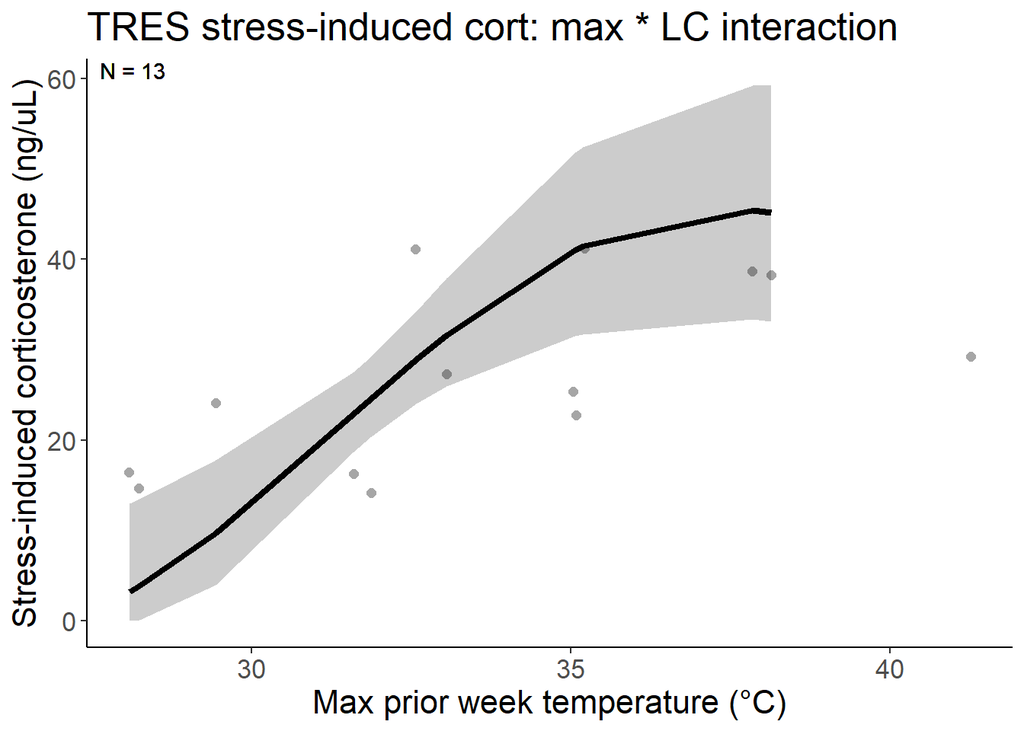

```r
mean_temp_tres_q3h2 <- mean(data_tres_q3h2 %>% pull(maxt_week))
sd_temp_tres_q3h2 <- sd(data_tres_q3h2 %>% pull(maxt_week))


temp_trans_tres_q3h2 <- trans_new("temp_trans_tres_q3h2",
                             transform = function(x){(x * sd_temp_tres_q3h2) + mean_temp_tres_q3h2},
                             inverse = function(x){x})

(figq3h2_tres <- predict_response(m_tres_q3h2,terms = c("maxt_week_scaled [all]"),margin = "empirical") %>%
    plot(line_size = 1.5,alpha = .2,show_data = TRUE,limit_range = TRUE) +
    aes(linetype = .data[["group"]]) +
    theme_classic() +
    # facet_wrap(~ group, ncol = 2) +
    xlab("Max prior week temperature (\u00b0C)") +
    ylab("Stress-induced corticosterone (ng/uL)") +
    scale_fill_viridis(discrete = TRUE) +
    scale_color_viridis(discrete = TRUE) +
    theme(text = element_text(size = 16)) +
    labs(title =  "TRES stress-induced cort: max * LC interaction") +
    scale_x_continuous(trans = temp_trans_tres_q3h2,
                       breaks = c((20-mean_temp_tres_q3h2)/sd_temp_tres_q3h2,
                                  (25-mean_temp_tres_q3h2)/sd_temp_tres_q3h2,
                                  (30-mean_temp_tres_q3h2)/sd_temp_tres_q3h2,
                                  (35-mean_temp_tres_q3h2)/sd_temp_tres_q3h2,
                                  (40-mean_temp_tres_q3h2)/sd_temp_tres_q3h2),
                       # breaks = c(20,30,40,50),
                       # labels = c("20","30","40","50"),
                       # limits = c((15-mean(g$meanmaxtempI,na.rm = TRUE))/sd(g$meanmaxtempI,na.rm = TRUE),
                       #            (55-mean(g$meanmaxtempI,na.rm = TRUE))/sd(g$meanmaxtempI,na.rm = TRUE))
                       # limits = c(18,5)
    ) +
    scale_linetype_manual(values = "solid") +
    #ylim(-5,5) +
    geom_text(data = dat_text_tres_q3h2, mapping = aes(x = -Inf, y = Inf,label = label),hjust = -.2, vjust = 1.2,inherit.aes = FALSE) +
    theme(legend.position = "none")
)
```

```r
ggsave("../figures/provisbymaxtempxhab_TRES_q3h2.png",plot =  figq3h2_tres, width = 10, height = 6.6)
```

## Q4H1

4. Are provisioning rates affected by circulating CORT levels? We hypothesized that
1. (H1) females with elevated baseline corticosterone concentrations after a hot period would be more likely to maintain provisioning delivery to nestlings during following hot periods because they have the capacity to upregulate their HPA axis in response to environmental challenges (Mentesana and Hau 2022).

### WEBL

```r
m_WEBL <- glmmTMB(valid_detections ~ poly(mean_temp_scaled,2) * cort_s1_mother_scaled + poly(tod_h_scaled,2) + mean_nestling_age_scaled + brood_size_scaled + year_fct + (1|site:attempt_id),
           family = nbinom2(),
           ziformula = ~ 1,
           data = dplyr::filter(p,!is.na(mean_temp),
                                !is.na(cort_s1_mother),
                                  # !is.na(julian_date),
                                  !is.na(mean_nestling_age),
                                  !is.na(brood_size),
                                  !is.na(tod_h),
                                  !is.na(site),
                                  !is.na(attempt_id),
                                  !is.na(year),
                                  species == "WEBL"# ,
                                                # tod >= hms::as.hms('11:00:00', tz = "America/Los_Angeles"),
                                                # tod_end <= hms::as.hms('17:00:00',tz = "America/Los_Angeles"),
                                                # tod_end >= hms::as.hms('11:00:00', tz = "America/Los_Angeles")
                                                ) %>%
                        mutate(across(c(tod_h,mean_temp,cort_s1_mother,julian_date,mean_nestling_age,brood_size),
                                                    ~ scale(.x)[,1],
                                                    .names = "{.col}_scaled")),
           )

m_WEBL_linint <- glmmTMB(valid_detections ~ mean_temp_scaled * cort_s1_mother_scaled + poly(mean_temp_scaled,degree = 2) + poly(tod_h_scaled,2) + mean_nestling_age_scaled + brood_size_scaled + year_fct + (1|site:attempt_id),
           family = nbinom2(),
           ziformula = ~ 1,
           data = dplyr::filter(p,!is.na(mean_temp),
                                !is.na(cort_s1_mother),
                                  # !is.na(julian_date),
                                  !is.na(mean_nestling_age),
                                  !is.na(brood_size),
                                  !is.na(tod_h),
                                  !is.na(site),
                                  !is.na(attempt_id),
                                  !is.na(year),
                                  species == "WEBL"# ,
                                                # tod >= hms::as.hms('11:00:00', tz = "America/Los_Angeles"),
                                                # tod_end <= hms::as.hms('17:00:00',tz = "America/Los_Angeles"),
                                                # tod_end >= hms::as.hms('11:00:00', tz = "America/Los_Angeles")
                                                ) %>%
                        mutate(across(c(tod_h,mean_temp,cort_s1_mother,julian_date,mean_nestling_age,brood_size),
                                                    ~ scale(.x)[,1],
                                                    .names = "{.col}_scaled")),
           )
```

```
## dropping columns from rank-deficient conditional model: poly(mean_temp_scaled, degree = 2)1
```

```r
m_WEBL_noint <- glmmTMB(valid_detections ~ cort_s1_mother_scaled + poly(mean_temp_scaled,degree = 2) + poly(tod_h_scaled,2) + mean_nestling_age_scaled + brood_size_scaled + year_fct + (1|site:attempt_id),
           family = nbinom2(),
           ziformula = ~ 1,
           data = dplyr::filter(p,!is.na(mean_temp),
                                !is.na(cort_s1_mother),
                                  # !is.na(julian_date),
                                  !is.na(mean_nestling_age),
                                  !is.na(brood_size),
                                  !is.na(tod_h),
                                  !is.na(site),
                                  !is.na(attempt_id),
                                  !is.na(year),
                                  species == "WEBL"# ,
                                                # tod >= hms::as.hms('11:00:00', tz = "America/Los_Angeles"),
                                                # tod_end <= hms::as.hms('17:00:00',tz = "America/Los_Angeles"),
                                                # tod_end >= hms::as.hms('11:00:00', tz = "America/Los_Angeles")
                                                ) %>%
                        mutate(across(c(tod_h,mean_temp,cort_s1_mother,julian_date,mean_nestling_age,brood_size),
                                                    ~ scale(.x)[,1],
                                                    .names = "{.col}_scaled")),
           )




c <- anova(m_WEBL,m_WEBL_linint,m_WEBL_noint) %>% tibble() %>% mutate(Model = c("No temp * LC interaction","Linear temp * LC interaction","Squared temp * LC interaction"),.before = Df)

(tab <- c %>%
  as.tibble() %>%
  mutate(across(where(is.numeric),~round(.x,digits = 4)),
         P = `Pr(>Chisq)`) %>%
  dplyr::select(Model,AIC,Chisq,P) %>%
  mutate(across(c(AIC,Chisq), ~ round(.x, digits = 2)),
         P = if_else(P < 0.001,"<0.001",as.character(P))) %>% gt())
```

| Model | AIC | Chisq | P |
| --- | --- | --- | --- |
| No temp * LC interaction | 816.04 | NA | NA |
| Linear temp * LC interaction | 815.39 | 2.65 | 0.1033 |
| Squared temp * LC interaction | 808.35 | 9.04 | 0.0026 |

```r
gtsave(tab,"../figures/int_tab_provis_ch3_q4h1_webl.html")

summary(m_WEBL)
```

```
##  Family: nbinom2  ( log )
## Formula:
## valid_detections ~ poly(mean_temp_scaled, 2) * cort_s1_mother_scaled +
##     poly(tod_h_scaled, 2) + mean_nestling_age_scaled + brood_size_scaled +
##     year_fct + (1 | site:attempt_id)
## Zero inflation:                    ~1
## Data:
## dplyr::filter(p, !is.na(mean_temp), !is.na(cort_s1_mother), !is.na(mean_nestling_age),
##     !is.na(brood_size), !is.na(tod_h), !is.na(site), !is.na(attempt_id),
##     !is.na(year), species == "WEBL") %>% mutate(across(c(tod_h,
##     mean_temp, cort_s1_mother, julian_date, mean_nestling_age,
##     brood_size), ~scale(.x)[, 1], .names = "{.col}_scaled"))
##
##      AIC      BIC   logLik deviance df.resid
##    808.3    849.8   -390.2    780.3      129
##
## Random effects:
##
## Conditional model:
##  Groups          Name        Variance Std.Dev.
##  site:attempt_id (Intercept) 0.5203   0.7213
## Number of obs: 143, groups:  site:attempt_id, 12
##
## Dispersion parameter for nbinom2 family (): 6.56
##
## Conditional model:
##                                                  Estimate Std. Error z value
## (Intercept)                                       1.92141    0.37787   5.085
## poly(mean_temp_scaled, 2)1                       -2.54983    1.39333  -1.830
## poly(mean_temp_scaled, 2)2                       -1.71784    1.02001  -1.684
## cort_s1_mother_scaled                             0.13361    0.28048   0.476
## poly(tod_h_scaled, 2)1                           -0.93472    0.57475  -1.626
## poly(tod_h_scaled, 2)2                           -0.38947    0.87024  -0.448
## mean_nestling_age_scaled                          0.07367    0.07381   0.998
## brood_size_scaled                                 0.56040    0.24741   2.265
## year_fct2023                                     -0.72290    0.55492  -1.303
## poly(mean_temp_scaled, 2)1:cort_s1_mother_scaled -0.30889    1.46071  -0.211
## poly(mean_temp_scaled, 2)2:cort_s1_mother_scaled  2.85001    0.93240   3.057
##                                                  Pr(>|z|)
## (Intercept)                                      3.68e-07 ***
## poly(mean_temp_scaled, 2)1                        0.06725 .
## poly(mean_temp_scaled, 2)2                        0.09216 .
## cort_s1_mother_scaled                             0.63382
## poly(tod_h_scaled, 2)1                            0.10388
## poly(tod_h_scaled, 2)2                            0.65448
## mean_nestling_age_scaled                          0.31825
## brood_size_scaled                                 0.02351 *
## year_fct2023                                      0.19268
## poly(mean_temp_scaled, 2)1:cort_s1_mother_scaled  0.83253
## poly(mean_temp_scaled, 2)2:cort_s1_mother_scaled  0.00224 **
## ---
## Signif. codes:  0 '***' 0.001 '**' 0.01 '*' 0.05 '.' 0.1 ' ' 1
##
## Zero-inflation model:
##             Estimate Std. Error z value Pr(>|z|)
## (Intercept)   -20.76    6231.92  -0.003    0.997
```

```r
summary(m_WEBL_noint)
```

```
##  Family: nbinom2  ( log )
## Formula:
## valid_detections ~ cort_s1_mother_scaled + poly(mean_temp_scaled,
##     degree = 2) + poly(tod_h_scaled, 2) + mean_nestling_age_scaled +
##     brood_size_scaled + year_fct + (1 | site:attempt_id)
## Zero inflation:                    ~1
## Data:
## dplyr::filter(p, !is.na(mean_temp), !is.na(cort_s1_mother), !is.na(mean_nestling_age),
##     !is.na(brood_size), !is.na(tod_h), !is.na(site), !is.na(attempt_id),
##     !is.na(year), species == "WEBL") %>% mutate(across(c(tod_h,
##     mean_temp, cort_s1_mother, julian_date, mean_nestling_age,
##     brood_size), ~scale(.x)[, 1], .names = "{.col}_scaled"))
##
##      AIC      BIC   logLik deviance df.resid
##    816.0    851.6   -396.0    792.0      131
##
## Random effects:
##
## Conditional model:
##  Groups          Name        Variance Std.Dev.
##  site:attempt_id (Intercept) 0.5529   0.7436
## Number of obs: 143, groups:  site:attempt_id, 12
##
## Dispersion parameter for nbinom2 family (): 5.51
##
## Conditional model:
##                                     Estimate Std. Error z value Pr(>|z|)
## (Intercept)                          2.01719    0.38317   5.264 1.41e-07 ***
## cort_s1_mother_scaled                0.11356    0.28093   0.404   0.6860
## poly(mean_temp_scaled, degree = 2)1 -5.15668    1.24159  -4.153 3.28e-05 ***
## poly(mean_temp_scaled, degree = 2)2 -0.57101    0.75527  -0.756   0.4496
## poly(tod_h_scaled, 2)1              -1.28785    0.59332  -2.171   0.0300 *
## poly(tod_h_scaled, 2)2              -1.00345    0.87601  -1.145   0.2520
## mean_nestling_age_scaled             0.07654    0.07667   0.998   0.3181
## brood_size_scaled                    0.52247    0.25191   2.074   0.0381 *
## year_fct2023                        -0.86461    0.56819  -1.522   0.1281
## ---
## Signif. codes:  0 '***' 0.001 '**' 0.01 '*' 0.05 '.' 0.1 ' ' 1
##
## Zero-inflation model:
##             Estimate Std. Error z value Pr(>|z|)
## (Intercept)   -19.99    4277.86  -0.005    0.996
```

```r
m_webl_q4h1 <- m_WEBL

check_zeroinflation(m_WEBL)
```

```
## # Check for zero-inflation
##
##    Observed zeros: 16
##   Predicted zeros: 13
##             Ratio: 0.81
```

```
## Model is underfitting zeros (probable zero-inflation) (p = 0.536).
```

```r
(t <- emtrends(m_webl_q4h1,specs = ~ cort_s1_mother_scaled, var = c("mean_temp_scaled"),max.degree = 1) %>% test() %>%
   mutate(across(where(is.numeric), ~ round(.x, digits = 3)),
          df = round(df),
          p.value = if_else(p.value == 0.000,"<0.001",as.character(p.value))) %>%
   rename(`Female condition` = "cort_s1_mother_scaled", `Max temp trend` = "mean_temp_scaled.trend",Df = "df", `Z-ratio` = "z.ratio", P = "p.value") %>%
   #group_by(degree) %>%
   gt())
```

| Female condition | Max temp trend | SE | Df | Z-ratio | P |
| --- | --- | --- | --- | --- | --- |
| 0 | -0.21 | 0.117 | Inf | -1.795 | 0.073 |

```r
joint_tests(m_webl_q4h1)
```

|  | model term | df1 | df2 | F.ratio | Chisq | p.value |
| --- | --- | --- | --- | --- | --- | --- |
| 1 | mean_temp_scaled | 1 | Inf | 3.204 | 3.204 | 0.07345694 |
| 3 | cort_s1_mother_scaled | 1 | Inf | 0.231 | 0.231 | 0.63086484 |
| 4 | tod_h_scaled | 1 | Inf | 2.455 | 2.455 | 0.11716257 |
| 5 | mean_nestling_age_scaled | 1 | Inf | 0.996 | 0.996 | 0.31824600 |
| 6 | brood_size_scaled | 1 | Inf | 5.130 | 5.130 | 0.02351027 |
| 7 | year_fct | 1 | Inf | 1.697 | 1.697 | 0.19267772 |
| 2 | mean_temp_scaled:cort_s1_mother_scaled | 1 | Inf | 0.073 | 0.073 | 0.78718655 |

```r
# gtsave(t,"../figures/weblprovistrend_ch3_q4h1.html")


ss_year_webl_provis <- m_webl_q4h1$frame %>%
  group_by(year_fct) %>%
  summarize(count_ind = n(),count_attempt = n_distinct(attempt_id)) %>%
  rowwise() %>%
  mutate(count = tibble(count_ind,count_attempt)) %>%
  dplyr::select(-c(count_ind, count_attempt)) %>%
  pivot_wider(values_from = count,names_from = year_fct) %>%
  as.tibble() %>%
  ungroup() %>%
  # mutate(`2021` = replace_na(`2021`,list(count_ind = 0,count_attempt = 0))) %>%
  mutate(Total = `2022` + `2023`) %>%
  rowwise() %>%
  mutate(`2022` = paste0(`2022`$count_ind,", ",`2022`$count_attempt),
         `2023` = paste0(`2023`$count_ind,", ",`2023`$count_attempt),
         Total = paste0(Total$count_ind,", ",Total$count_attempt)
  )

(t_ss_year_webl_provis <- ss_year_webl_provis %>% gt() %>%
    grand_summary_rows(fns = list(id = "Total") ~ {
      t <- str_split(.,", ",simplify = TRUE)
      t[,1] %>% as.numeric() %>% sum(na.rm = TRUE) %>% paste(t[,2] %>% as.numeric() %>% sum(na.rm = TRUE),sep = ", ")
    })
)
```

|  | 2022 | 2023 | Total |
| --- | --- | --- | --- |
|  | 88, 5 | 55, 7 | 143, 12 |
| Total | 88, 5 | 55, 7 | 143, 12 |

```r
t_ss_year_webl_provis %>% gtsave("../figures/ss_year_webl_provis_ch3.html")

samp <- m_webl_q4h1$frame %>% summarize(count = n())
samp %>% gt() %>% gtsave("../figures/ss_webl_provis_ch3.html")


dat_text_webl_q4h1 <- data.frame(
  label = paste("N =",samp$count),
  group   = factor(c("Forest","Orchard","Grassland","Row crop"))
)

## num nestboxes
m_webl_q4h1$frame %>% pull(attempt_id) %>% unique() %>% length()
```

```
## [1] 12
```

```
## Data points may overlap. Use the `jitter` argument to add some amount of
##   random variation to the location of data points and avoid overplotting.
```

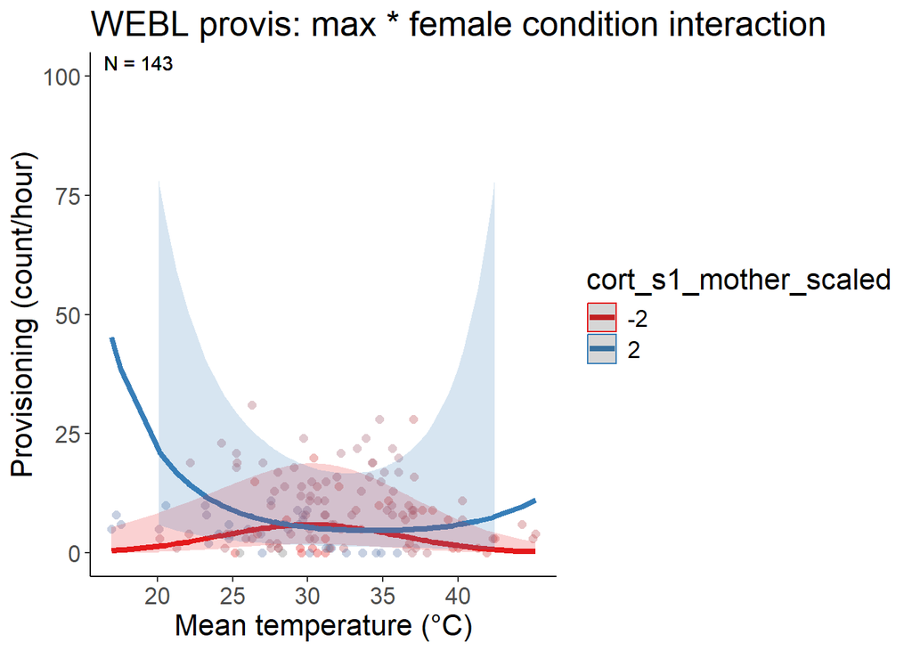

```r
data_webl_q4h1 = dplyr::filter(p,!is.na(mean_temp),
                               !is.na(cort_s1_mother),
                                  # !is.na(julian_date),
                                  !is.na(mean_nestling_age),
                                  !is.na(brood_size),
                                  !is.na(tod_h),
                                  !is.na(site),
                                  !is.na(attempt_id),
                                  !is.na(year),
                                  species == "WEBL"# ,
                                                # tod >= hms::as.hms('11:00:00', tz = "America/Los_Angeles"),
                                                # tod_end <= hms::as.hms('17:00:00',tz = "America/Los_Angeles"),
                                                # tod_end >= hms::as.hms('11:00:00', tz = "America/Los_Angeles")
                                                ) %>%
                        mutate(across(c(tod_h,mean_temp,cort_s1_mother,julian_date,mean_nestling_age,brood_size),
                                                    ~ scale(.x)[,1],
                                                    .names = "{.col}_scaled"))


mean_temp_webl_q4h1 <- mean(data_webl_q4h1 %>% pull(mean_temp))
sd_temp_webl_q4h1 <- sd(data_webl_q4h1 %>% pull(mean_temp))


temp_trans_webl_q4h1 <- trans_new("temp_trans_webl_q4h1",
                             transform = function(x){(x * sd_temp_webl_q4h1) + mean_temp_webl_q4h1},
                             inverse = function(x){x})

(figq4h1_webl <- predict_response(m_webl_q4h1,terms = c("mean_temp_scaled [all]","cort_s1_mother_scaled [-2,2]"),margin = "marginalmeans") %>%
    plot(line_size = 1.5,alpha = .2,show_data = TRUE,limit_range = TRUE) +
    # aes(linetype = .data[["group"]]) +
    theme_classic() +
    # facet_wrap(~ group, ncol = 2) +
    xlab("Mean temperature (\u00b0C)") +
    ylab("Provisioning (count/hour)") +
    # scale_fill_viridis(discrete = TRUE) +
    # scale_color_viridis(discrete = TRUE) +
    theme(text = element_text(size = 16)) +
    labs(title =  "WEBL provis: max * female condition interaction") +
    scale_x_continuous(trans = temp_trans_webl_q4h1,
                       breaks = c((20-mean_temp_webl_q4h1)/sd_temp_webl_q4h1,
                                  (25-mean_temp_webl_q4h1)/sd_temp_webl_q4h1,
                                  (30-mean_temp_webl_q4h1)/sd_temp_webl_q4h1,
                                  (35-mean_temp_webl_q4h1)/sd_temp_webl_q4h1,
                                  (40-mean_temp_webl_q4h1)/sd_temp_webl_q4h1),
                       # breaks = c(20,30,40,50),
                       # labels = c("20","30","40","50"),
                       # limits = c((15-mean(g$meanmaxtempI,na.rm = TRUE))/sd(g$meanmaxtempI,na.rm = TRUE),
                       #            (55-mean(g$meanmaxtempI,na.rm = TRUE))/sd(g$meanmaxtempI,na.rm = TRUE))
                       # limits = c(18,5)
    ) +
    # scale_linetype_manual(values = c("Forest" = "solid","Orchard" = "dashed","Grassland" = "solid","Row crop" = "dotted")) +
    ylim(0,100) +
    geom_text(data = dat_text_webl_q4h1, mapping = aes(x = -Inf, y = Inf,label = label),hjust = -.2, vjust = 1.2,inherit.aes = FALSE)# +
    # theme(legend.position = "none")
)
```

```r
ggsave("../figures/provisbymaxtempxhab_WEBL_q4h1.png",plot =  figq4h1_webl, width = 10, height = 6.6)
```

Females with lower cort are “peakier” (more responsive to temp) than females with higher baseline cort

### TRES

```r
m_TRES <- glmmTMB(valid_detections ~ poly(mean_temp_scaled,2) * cort_s1_mother_scaled + poly(tod_h_scaled,2) + mean_nestling_age_scaled + brood_size_scaled + year_fct + (1|site:attempt_id),
           family = nbinom2(),
           ziformula = ~ 1,
           data = dplyr::filter(p,!is.na(mean_temp),
                                !is.na(cort_s1_mother),
                                  # !is.na(julian_date),
                                  !is.na(mean_nestling_age),
                                  !is.na(brood_size),
                                  !is.na(tod_h),
                                  !is.na(site),
                                  !is.na(attempt_id),
                                  !is.na(year),
                                  species == "TRES"# ,
                                                # tod >= hms::as.hms('11:00:00', tz = "America/Los_Angeles"),
                                                # tod_end <= hms::as.hms('17:00:00',tz = "America/Los_Angeles"),
                                                # tod_end >= hms::as.hms('11:00:00', tz = "America/Los_Angeles")
                                                ) %>%
                        mutate(across(c(tod_h,mean_temp,cort_s1_mother,julian_date,mean_nestling_age,brood_size),
                                                    ~ scale(.x)[,1],
                                                    .names = "{.col}_scaled")),
           )

m_TRES_linint <- glmmTMB(valid_detections ~ mean_temp_scaled * cort_s1_mother_scaled + poly(mean_temp_scaled,degree = 2) + poly(tod_h_scaled,2) + mean_nestling_age_scaled + brood_size_scaled + year_fct + (1|site:attempt_id),
           family = nbinom2(),
           ziformula = ~ 1,
           data = dplyr::filter(p,!is.na(mean_temp),
                                !is.na(cort_s1_mother),
                                  # !is.na(julian_date),
                                  !is.na(mean_nestling_age),
                                  !is.na(brood_size),
                                  !is.na(tod_h),
                                  !is.na(site),
                                  !is.na(attempt_id),
                                  !is.na(year),
                                  species == "TRES"# ,
                                                # tod >= hms::as.hms('11:00:00', tz = "America/Los_Angeles"),
                                                # tod_end <= hms::as.hms('17:00:00',tz = "America/Los_Angeles"),
                                                # tod_end >= hms::as.hms('11:00:00', tz = "America/Los_Angeles")
                                                ) %>%
                        mutate(across(c(tod_h,mean_temp,cort_s1_mother,julian_date,mean_nestling_age,brood_size),
                                                    ~ scale(.x)[,1],
                                                    .names = "{.col}_scaled")),
           )
```

```
## dropping columns from rank-deficient conditional model: poly(mean_temp_scaled, degree = 2)1
```

```r
m_TRES_noint <- glmmTMB(valid_detections ~ cort_s1_mother_scaled + poly(mean_temp_scaled,degree = 2) + poly(tod_h_scaled,2) + mean_nestling_age_scaled + brood_size_scaled + year_fct + (1|site:attempt_id),
           family = nbinom2(),
           ziformula = ~ 1,
           data = dplyr::filter(p,!is.na(mean_temp),
                                !is.na(cort_s1_mother),
                                  # !is.na(julian_date),
                                  !is.na(mean_nestling_age),
                                  !is.na(brood_size),
                                  !is.na(tod_h),
                                  !is.na(site),
                                  !is.na(attempt_id),
                                  !is.na(year),
                                  species == "TRES"# ,
                                                # tod >= hms::as.hms('11:00:00', tz = "America/Los_Angeles"),
                                                # tod_end <= hms::as.hms('17:00:00',tz = "America/Los_Angeles"),
                                                # tod_end >= hms::as.hms('11:00:00', tz = "America/Los_Angeles")
                                                ) %>%
                        mutate(across(c(tod_h,mean_temp,cort_s1_mother,julian_date,mean_nestling_age,brood_size),
                                                    ~ scale(.x)[,1],
                                                    .names = "{.col}_scaled")),
           )




c <- anova(m_TRES,m_TRES_linint,m_TRES_noint) %>% tibble() %>% mutate(Model = c("No temp * LC interaction","Linear temp * LC interaction","Squared temp * LC interaction"),.before = Df)

(tab <- c %>%
  as.tibble() %>%
  mutate(across(where(is.numeric),~round(.x,digits = 4)),
         P = `Pr(>Chisq)`) %>%
  dplyr::select(Model,AIC,Chisq,P) %>%
  mutate(across(c(AIC,Chisq), ~ round(.x, digits = 2)),
         P = if_else(P < 0.001,"<0.001",as.character(P))) %>% gt())
```

| Model | AIC | Chisq | P |
| --- | --- | --- | --- |
| No temp * LC interaction | 983.92 | NA | NA |
| Linear temp * LC interaction | 985.92 | 0.00 | 0.9526 |
| Squared temp * LC interaction | 985.38 | 2.53 | 0.1115 |

```r
gtsave(tab,"../figures/int_tab_provis_ch3_q4h1_tres.html")

summary(m_TRES_linint)
```

```
##  Family: nbinom2  ( log )
## Formula:
## valid_detections ~ mean_temp_scaled * cort_s1_mother_scaled +
##     poly(mean_temp_scaled, degree = 2) + poly(tod_h_scaled, 2) +
##     mean_nestling_age_scaled + brood_size_scaled + year_fct +
##     (1 | site:attempt_id)
## Zero inflation:                    ~1
## Data:
## dplyr::filter(p, !is.na(mean_temp), !is.na(cort_s1_mother), !is.na(mean_nestling_age),
##     !is.na(brood_size), !is.na(tod_h), !is.na(site), !is.na(attempt_id),
##     !is.na(year), species == "TRES") %>% mutate(across(c(tod_h,
##     mean_temp, cort_s1_mother, julian_date, mean_nestling_age,
##     brood_size), ~scale(.x)[, 1], .names = "{.col}_scaled"))
##
##      AIC      BIC   logLik deviance df.resid
##    985.9   1024.8   -480.0    959.9      134
##
## Random effects:
##
## Conditional model:
##  Groups          Name        Variance Std.Dev.
##  site:attempt_id (Intercept) 0.6425   0.8016
## Number of obs: 147, groups:  site:attempt_id, 13
##
## Dispersion parameter for nbinom2 family (): 2.81
##
## Conditional model:
##                                         Estimate Std. Error z value Pr(>|z|)
## (Intercept)                             2.206000   0.395169   5.582 2.37e-08
## mean_temp_scaled                        0.507554   0.187792   2.703  0.00688
## cort_s1_mother_scaled                  -0.808373   0.291494  -2.773  0.00555
## poly(mean_temp_scaled, degree = 2)1           NA         NA      NA       NA
## poly(mean_temp_scaled, degree = 2)2    -0.340622   1.068655  -0.319  0.74992
## poly(tod_h_scaled, 2)1                 -0.872169   0.887263  -0.983  0.32561
## poly(tod_h_scaled, 2)2                  3.455995   1.507866   2.292  0.02191
## mean_nestling_age_scaled                0.035264   0.108087   0.326  0.74423
## brood_size_scaled                       0.390533   0.318146   1.228  0.21962
## year_fct2023                            0.019125   0.594236   0.032  0.97432
## mean_temp_scaled:cort_s1_mother_scaled  0.007425   0.125067   0.059  0.95266
##
## (Intercept)                            ***
## mean_temp_scaled                       **
## cort_s1_mother_scaled                  **
## poly(mean_temp_scaled, degree = 2)1
## poly(mean_temp_scaled, degree = 2)2
## poly(tod_h_scaled, 2)1
## poly(tod_h_scaled, 2)2                 *
## mean_nestling_age_scaled
## brood_size_scaled
## year_fct2023
## mean_temp_scaled:cort_s1_mother_scaled
## ---
## Signif. codes:  0 '***' 0.001 '**' 0.01 '*' 0.05 '.' 0.1 ' ' 1
##
## Zero-inflation model:
##             Estimate Std. Error z value Pr(>|z|)
## (Intercept)  -2.0408     0.3106   -6.57 5.04e-11 ***
## ---
## Signif. codes:  0 '***' 0.001 '**' 0.01 '*' 0.05 '.' 0.1 ' ' 1
```

```r
summary(m_TRES_noint)
```

```
##  Family: nbinom2  ( log )
## Formula:
## valid_detections ~ cort_s1_mother_scaled + poly(mean_temp_scaled,
##     degree = 2) + poly(tod_h_scaled, 2) + mean_nestling_age_scaled +
##     brood_size_scaled + year_fct + (1 | site:attempt_id)
## Zero inflation:                    ~1
## Data:
## dplyr::filter(p, !is.na(mean_temp), !is.na(cort_s1_mother), !is.na(mean_nestling_age),
##     !is.na(brood_size), !is.na(tod_h), !is.na(site), !is.na(attempt_id),
##     !is.na(year), species == "TRES") %>% mutate(across(c(tod_h,
##     mean_temp, cort_s1_mother, julian_date, mean_nestling_age,
##     brood_size), ~scale(.x)[, 1], .names = "{.col}_scaled"))
##
##      AIC      BIC   logLik deviance df.resid
##    983.9   1019.8   -480.0    959.9      135
##
## Random effects:
##
## Conditional model:
##  Groups          Name        Variance Std.Dev.
##  site:attempt_id (Intercept) 0.6436   0.8022
## Number of obs: 147, groups:  site:attempt_id, 13
##
## Dispersion parameter for nbinom2 family (): 2.81
##
## Conditional model:
##                                     Estimate Std. Error z value Pr(>|z|)
## (Intercept)                          2.20376    0.39350   5.600 2.14e-08 ***
## cort_s1_mother_scaled               -0.81092    0.28850  -2.811  0.00494 **
## poly(mean_temp_scaled, degree = 2)1  6.13266    2.26814   2.704  0.00685 **
## poly(mean_temp_scaled, degree = 2)2 -0.36200    1.00554  -0.360  0.71885
## poly(tod_h_scaled, 2)1              -0.86643    0.88182  -0.983  0.32583
## poly(tod_h_scaled, 2)2               3.47050    1.48774   2.333  0.01966 *
## mean_nestling_age_scaled             0.03415    0.10644   0.321  0.74837
## brood_size_scaled                    0.39065    0.31835   1.227  0.21978
## year_fct2023                         0.02036    0.59410   0.034  0.97267
## ---
## Signif. codes:  0 '***' 0.001 '**' 0.01 '*' 0.05 '.' 0.1 ' ' 1
##
## Zero-inflation model:
##             Estimate Std. Error z value Pr(>|z|)
## (Intercept)  -2.0410     0.3104  -6.575 4.85e-11 ***
## ---
## Signif. codes:  0 '***' 0.001 '**' 0.01 '*' 0.05 '.' 0.1 ' ' 1
```

```r
m_tres_q4h1 <- m_TRES_noint

check_zeroinflation(m_TRES_noint)
```

```
## # Check for zero-inflation
##
##    Observed zeros: 29
##   Predicted zeros: 27
##             Ratio: 0.93
```

```
## Model seems ok, ratio of observed and predicted zeros is within the
##   tolerance range (p = 0.776).
```

```r
(t <- emtrends(m_tres_q4h1,specs = ~ cort_s1_mother_scaled, var = c("mean_temp_scaled"),max.degree = 1) %>% test() %>%
   mutate(across(where(is.numeric), ~ round(.x, digits = 3)),
          df = round(df),
          p.value = if_else(p.value == 0.000,"<0.001",as.character(p.value))) %>%
   rename(`Female condition` = "cort_s1_mother_scaled", `Max temp trend` = "mean_temp_scaled.trend",Df = "df", `Z-ratio` = "z.ratio", P = "p.value") %>%
   #group_by(degree) %>%
   gt())
```

| Female condition | Max temp trend | SE | Df | Z-ratio | P |
| --- | --- | --- | --- | --- | --- |
| 0 | 0.503 | 0.185 | Inf | 2.719 | 0.007 |

```r
joint_tests(m_tres_q4h1)
```

|  | model term | df1 | df2 | F.ratio | Chisq | p.value |
| --- | --- | --- | --- | --- | --- | --- |
| 1 | cort_s1_mother_scaled | 1 | Inf | 7.901 | 7.901 | 0.004941718 |
| 2 | mean_temp_scaled | 1 | Inf | 7.392 | 7.392 | 0.006550488 |
| 3 | tod_h_scaled | 1 | Inf | 2.006 | 2.006 | 0.156714511 |
| 4 | mean_nestling_age_scaled | 1 | Inf | 0.103 | 0.103 | 0.748373099 |
| 5 | brood_size_scaled | 1 | Inf | 1.506 | 1.506 | 0.219780853 |
| 6 | year_fct | 1 | Inf | 0.001 | 0.001 | 0.972666287 |

```r
# gtsave(t,"../figures/tresprovistrend_ch3_q4h1.html")


ss_year_tres_provis <- m_tres_q4h1$frame %>%
  group_by(year_fct) %>%
  summarize(count_ind = n(),count_attempt = n_distinct(attempt_id)) %>%
  rowwise() %>%
  mutate(count = tibble(count_ind,count_attempt)) %>%
  dplyr::select(-c(count_ind, count_attempt)) %>%
  pivot_wider(values_from = count,names_from = year_fct) %>%
  as.tibble() %>%
  ungroup() %>%
  # mutate(`2021` = replace_na(`2021`,list(count_ind = 0,count_attempt = 0))) %>%
  mutate(Total = `2022` + `2023`) %>%
  rowwise() %>%
  mutate(`2022` = paste0(`2022`$count_ind,", ",`2022`$count_attempt),
         `2023` = paste0(`2023`$count_ind,", ",`2023`$count_attempt),
         Total = paste0(Total$count_ind,", ",Total$count_attempt)
  )

(t_ss_year_tres_provis <- ss_year_tres_provis %>% gt() %>%
    grand_summary_rows(fns = list(id = "Total") ~ {
      t <- str_split(.,", ",simplify = TRUE)
      t[,1] %>% as.numeric() %>% sum(na.rm = TRUE) %>% paste(t[,2] %>% as.numeric() %>% sum(na.rm = TRUE),sep = ", ")
    })
)
```

|  | 2022 | 2023 | Total |
| --- | --- | --- | --- |
|  | 68, 6 | 79, 7 | 147, 13 |
| Total | 68, 6 | 79, 7 | 147, 13 |

```r
t_ss_year_tres_provis %>% gtsave("../figures/ss_year_tres_provis_ch3_q4h1.html")

samp <- m_tres_q4h1$frame %>% summarize(count = n())
samp %>% gt() %>% gtsave("../figures/ss_tres_provis_ch_q4h1.html")


dat_text_tres_q4h1 <- data.frame(
  label = paste("N =",samp$count),
  group   = factor(c("Forest","Orchard","Grassland","Row crop"))
)

## num nestboxes
m_tres_q4h1$frame %>% pull(attempt_id) %>% unique() %>% length()
```

```
## [1] 13
```

```
## Data points may overlap. Use the `jitter` argument to add some amount of
##   random variation to the location of data points and avoid overplotting.
```

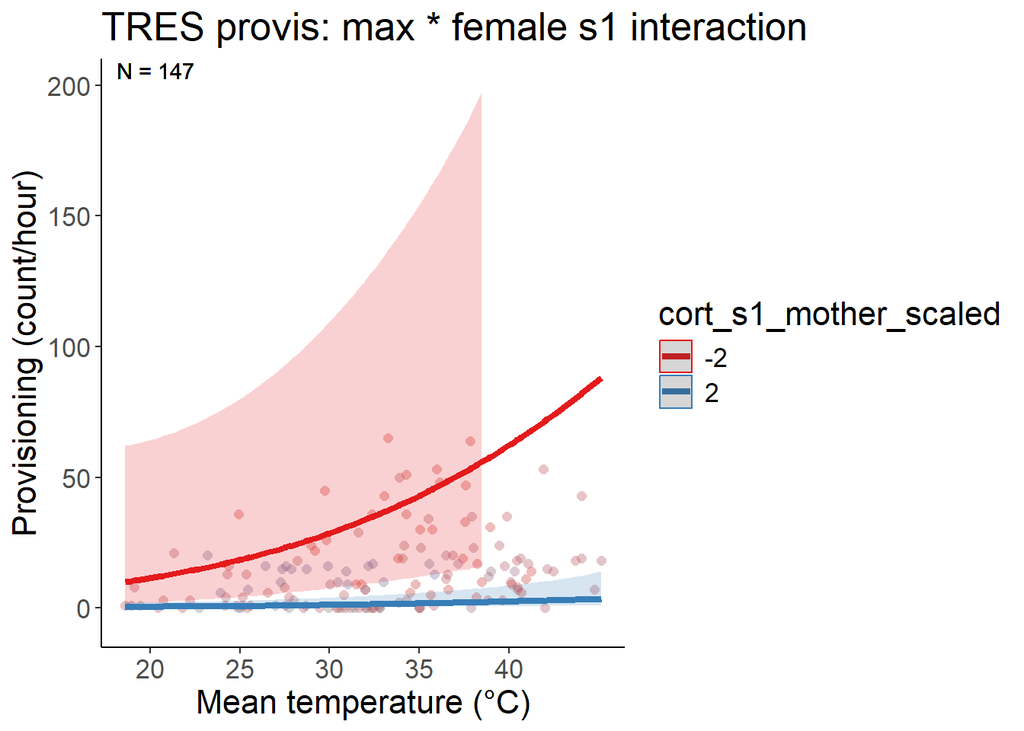

```r
data_tres_q4h1 = dplyr::filter(p,!is.na(mean_temp),
                               !is.na(cort_s1_mother),
                                  # !is.na(julian_date),
                                  !is.na(mean_nestling_age),
                                  !is.na(brood_size),
                                  !is.na(tod_h),
                                  !is.na(site),
                                  !is.na(attempt_id),
                                  !is.na(year),
                                  species == "TRES"# ,
                                                # tod >= hms::as.hms('11:00:00', tz = "America/Los_Angeles"),
                                                # tod_end <= hms::as.hms('17:00:00',tz = "America/Los_Angeles"),
                                                # tod_end >= hms::as.hms('11:00:00', tz = "America/Los_Angeles")
                                                ) %>%
                        mutate(across(c(tod_h,mean_temp,cort_s1_mother,julian_date,mean_nestling_age,brood_size),
                                                    ~ scale(.x)[,1],
                                                    .names = "{.col}_scaled"))


mean_temp_tres_q4h1 <- mean(data_tres_q4h1 %>% pull(mean_temp))
sd_temp_tres_q4h1 <- sd(data_tres_q4h1 %>% pull(mean_temp))


temp_trans_tres_q4h1 <- trans_new("temp_trans_tres_q4h1",
                             transform = function(x){(x * sd_temp_tres_q4h1) + mean_temp_tres_q4h1},
                             inverse = function(x){x})

(figq4h1_tres <- predict_response(m_tres_q4h1,terms = c("mean_temp_scaled [all]","cort_s1_mother_scaled [-2,2]"),margin = "marginalmeans") %>%
    plot(line_size = 1.5,alpha = .2,show_data = TRUE,limit_range = TRUE) +
    # aes(linetype = .data[["group"]]) +
    theme_classic() +
    # facet_wrap(~ group, ncol = 2) +
    xlab("Mean temperature (\u00b0C)") +
    ylab("Provisioning (count/hour)") +
    # scale_fill_viridis(discrete = TRUE) +
    # scale_color_viridis(discrete = TRUE) +
    theme(text = element_text(size = 16)) +
    labs(title =  "TRES provis: max * female s1 interaction") +
    scale_x_continuous(trans = temp_trans_tres_q4h1,
                       breaks = c((20-mean_temp_tres_q4h1)/sd_temp_tres_q4h1,
                                  (25-mean_temp_tres_q4h1)/sd_temp_tres_q4h1,
                                  (30-mean_temp_tres_q4h1)/sd_temp_tres_q4h1,
                                  (35-mean_temp_tres_q4h1)/sd_temp_tres_q4h1,
                                  (40-mean_temp_tres_q4h1)/sd_temp_tres_q4h1),
                       # breaks = c(20,30,40,50),
                       # labels = c("20","30","40","50"),
                       # limits = c((15-mean(g$meanmaxtempI,na.rm = TRUE))/sd(g$meanmaxtempI,na.rm = TRUE),
                       #            (55-mean(g$meanmaxtempI,na.rm = TRUE))/sd(g$meanmaxtempI,na.rm = TRUE))
                       # limits = c(18,5)
    ) +
    # scale_linetype_manual(values = c("Forest" = "solid","Orchard" = "dashed","Grassland" = "solid","Row crop" = "dotted")) +
    ylim(-5,200) +
    geom_text(data = dat_text_tres_q4h1, mapping = aes(x = -Inf, y = Inf,label = label),hjust = -.2, vjust = 1.2,inherit.aes = FALSE)# +
    #theme(legend.position = "none")
)
```

```r
ggsave("../figures/provisbymaxtempxhab_TRES_q4h1.png",plot =  figq4h1_tres, width = 10, height = 6.6)
```

Females with lower cort provision more overall, but the interaction is not significant.

## Q4H2

4. How does baseline and stress-induced cort mediate provisioning? We hypothesized that
1. (H1) females with elevated baseline corticosterone concentrations would be more likely to maintain provisioning delivery to nestlings during hot periods because they have the capacity to upregulate their HPA axis in response to environmental challenges (Mentesana and Hau 2022). Look at this paper: https://besjournals.onlinelibrary.wiley.com/doi/full/10.1111/1365-2656.12843
2. (H2) Females with elevated stress-induced corticosterone concentrations would be less likely to maintain provisioning delivery to nestlings during hot periods because elevated stress-induced corticosterone may be a sign that females are experiencing their environment as challenging.

### WEBL

```r
m_WEBL <- glmmTMB(valid_detections ~ poly(mean_temp_scaled,2) * cort_s2_mother_scaled + poly(tod_h_scaled,2) + mean_nestling_age_scaled + brood_size_scaled + year_fct + (1|site/attempt_id),
           family = nbinom2(),
           ziformula = ~ 1,
           data = dplyr::filter(p,!is.na(mean_temp),
                                !is.na(cort_s2_mother),
                                  # !is.na(julian_date),
                                  !is.na(mean_nestling_age),
                                  !is.na(brood_size),
                                  !is.na(tod_h),
                                  !is.na(site),
                                  !is.na(attempt_id),
                                  !is.na(year),
                                  species == "WEBL"# ,
                                                # tod >= hms::as.hms('11:00:00', tz = "America/Los_Angeles"),
                                                # tod_end <= hms::as.hms('17:00:00',tz = "America/Los_Angeles"),
                                                # tod_end >= hms::as.hms('11:00:00', tz = "America/Los_Angeles")
                                                ) %>%
                        mutate(across(c(tod_h,mean_temp,cort_s2_mother,julian_date,mean_nestling_age,brood_size),
                                                    ~ scale(.x)[,1],
                                                    .names = "{.col}_scaled")),
           )

m_WEBL_linint <- glmmTMB(valid_detections ~ mean_temp_scaled * cort_s2_mother_scaled + poly(mean_temp_scaled,degree = 2) + poly(tod_h_scaled,2) + mean_nestling_age_scaled + brood_size_scaled + year_fct + (1|site/attempt_id),
           family = nbinom2(),
           ziformula = ~ 1,
           data = dplyr::filter(p,!is.na(mean_temp),
                                !is.na(cort_s2_mother),
                                  # !is.na(julian_date),
                                  !is.na(mean_nestling_age),
                                  !is.na(brood_size),
                                  !is.na(tod_h),
                                  !is.na(site),
                                  !is.na(attempt_id),
                                  !is.na(year),
                                  species == "WEBL"# ,
                                                # tod >= hms::as.hms('11:00:00', tz = "America/Los_Angeles"),
                                                # tod_end <= hms::as.hms('17:00:00',tz = "America/Los_Angeles"),
                                                # tod_end >= hms::as.hms('11:00:00', tz = "America/Los_Angeles")
                                                ) %>%
                        mutate(across(c(tod_h,mean_temp,cort_s2_mother,julian_date,mean_nestling_age,brood_size),
                                                    ~ scale(.x)[,1],
                                                    .names = "{.col}_scaled")),
           )
```

```
## dropping columns from rank-deficient conditional model: poly(mean_temp_scaled, degree = 2)1
```

```r
m_WEBL_noint <- glmmTMB(valid_detections ~ cort_s2_mother_scaled + poly(mean_temp_scaled,degree = 2) + poly(tod_h_scaled,2) + mean_nestling_age_scaled + brood_size_scaled + year_fct + (1|site/attempt_id),
           family = nbinom2(),
           ziformula = ~ 1,
           data = dplyr::filter(p,!is.na(mean_temp),
                                !is.na(cort_s2_mother),
                                  # !is.na(julian_date),
                                  !is.na(mean_nestling_age),
                                  !is.na(brood_size),
                                  !is.na(tod_h),
                                  !is.na(site),
                                  !is.na(attempt_id),
                                  !is.na(year),
                                  species == "WEBL"# ,
                                                # tod >= hms::as.hms('11:00:00', tz = "America/Los_Angeles"),
                                                # tod_end <= hms::as.hms('17:00:00',tz = "America/Los_Angeles"),
                                                # tod_end >= hms::as.hms('11:00:00', tz = "America/Los_Angeles")
                                                ) %>%
                        mutate(across(c(tod_h,mean_temp,cort_s2_mother,julian_date,mean_nestling_age,brood_size),
                                                    ~ scale(.x)[,1],
                                                    .names = "{.col}_scaled")),
           )
c <- anova(m_WEBL,m_WEBL_linint,m_WEBL_noint) %>% tibble() %>% mutate(Model = c("No temp * LC interaction","Linear temp * LC interaction","Squared temp * LC interaction"),.before = Df)

(tab <- c %>%
  as.tibble() %>%
  mutate(across(where(is.numeric),~round(.x,digits = 4)),
         P = `Pr(>Chisq)`) %>%
  dplyr::select(Model,AIC,Chisq,P) %>%
  mutate(across(c(AIC,Chisq), ~ round(.x, digits = 2)),
         P = if_else(P < 0.001,"<0.001",as.character(P))) %>% gt())
```

| Model | AIC | Chisq | P |
| --- | --- | --- | --- |
| No temp * LC interaction | NA | NA | NA |
| Linear temp * LC interaction | 866.20 | NA | NA |
| Squared temp * LC interaction | 865.77 | 2.43 | 0.1188 |

```r
gtsave(tab,"../figures/int_tab_provis_ch3_q4h2_webl.html")

summary(m_WEBL)
```

```
##  Family: nbinom2  ( log )
## Formula:
## valid_detections ~ poly(mean_temp_scaled, 2) * cort_s2_mother_scaled +
##     poly(tod_h_scaled, 2) + mean_nestling_age_scaled + brood_size_scaled +
##     year_fct + (1 | site/attempt_id)
## Zero inflation:                    ~1
## Data:
## dplyr::filter(p, !is.na(mean_temp), !is.na(cort_s2_mother), !is.na(mean_nestling_age),
##     !is.na(brood_size), !is.na(tod_h), !is.na(site), !is.na(attempt_id),
##     !is.na(year), species == "WEBL") %>% mutate(across(c(tod_h,
##     mean_temp, cort_s2_mother, julian_date, mean_nestling_age,
##     brood_size), ~scale(.x)[, 1], .names = "{.col}_scaled"))
##
##      AIC      BIC   logLik deviance df.resid
##    865.8    911.0   -417.9    835.8      136
##
## Random effects:
##
## Conditional model:
##  Groups          Name        Variance  Std.Dev.
##  attempt_id:site (Intercept) 5.681e-01 7.537e-01
##  site            (Intercept) 3.564e-17 5.970e-09
## Number of obs: 151, groups:  attempt_id:site, 12; site, 3
##
## Dispersion parameter for nbinom2 family (): 5.97
##
## Conditional model:
##                                                  Estimate Std. Error z value
## (Intercept)                                       2.07263    0.35405   5.854
## poly(mean_temp_scaled, 2)1                       -5.58154    1.23210  -4.530
## poly(mean_temp_scaled, 2)2                       -0.02609    0.75915  -0.034
## cort_s2_mother_scaled                            -0.10078    0.24395  -0.413
## poly(tod_h_scaled, 2)1                           -1.41720    0.57871  -2.449
## poly(tod_h_scaled, 2)2                           -1.25612    0.89141  -1.409
## mean_nestling_age_scaled                          0.10375    0.07168   1.447
## brood_size_scaled                                 0.28100    0.17890   1.571
## year_fct2023                                     -0.75057    0.49606  -1.513
## poly(mean_temp_scaled, 2)1:cort_s2_mother_scaled  2.47564    1.11047   2.229
## poly(mean_temp_scaled, 2)2:cort_s2_mother_scaled  2.28785    1.46284   1.564
##                                                  Pr(>|z|)
## (Intercept)                                       4.8e-09 ***
## poly(mean_temp_scaled, 2)1                        5.9e-06 ***
## poly(mean_temp_scaled, 2)2                         0.9726
## cort_s2_mother_scaled                              0.6795
## poly(tod_h_scaled, 2)1                             0.0143 *
## poly(tod_h_scaled, 2)2                             0.1588
## mean_nestling_age_scaled                           0.1478
## brood_size_scaled                                  0.1162
## year_fct2023                                       0.1303
## poly(mean_temp_scaled, 2)1:cort_s2_mother_scaled   0.0258 *
## poly(mean_temp_scaled, 2)2:cort_s2_mother_scaled   0.1178
## ---
## Signif. codes:  0 '***' 0.001 '**' 0.01 '*' 0.05 '.' 0.1 ' ' 1
##
## Zero-inflation model:
##             Estimate Std. Error z value Pr(>|z|)
## (Intercept)    -19.1     4218.2  -0.005    0.996
```

```r
summary(m_WEBL_noint)
```

```
##  Family: nbinom2  ( log )
## Formula:
## valid_detections ~ cort_s2_mother_scaled + poly(mean_temp_scaled,
##     degree = 2) + poly(tod_h_scaled, 2) + mean_nestling_age_scaled +
##     brood_size_scaled + year_fct + (1 | site/attempt_id)
## Zero inflation:                    ~1
## Data:
## dplyr::filter(p, !is.na(mean_temp), !is.na(cort_s2_mother), !is.na(mean_nestling_age),
##     !is.na(brood_size), !is.na(tod_h), !is.na(site), !is.na(attempt_id),
##     !is.na(year), species == "WEBL") %>% mutate(across(c(tod_h,
##     mean_temp, cort_s2_mother, julian_date, mean_nestling_age,
##     brood_size), ~scale(.x)[, 1], .names = "{.col}_scaled"))
##
##      AIC      BIC   logLik deviance df.resid
##       NA       NA       NA       NA      138
##
## Random effects:
##
## Conditional model:
##  Groups          Name        Variance  Std.Dev.
##  attempt_id:site (Intercept) 5.308e-01 7.285e-01
##  site            (Intercept) 2.779e-19 5.271e-10
## Number of obs: 151, groups:  attempt_id:site, 12; site, 3
##
## Dispersion parameter for nbinom2 family (): 5.64
##
## Conditional model:
##                                     Estimate Std. Error z value Pr(>|z|)
## (Intercept)                          2.04201    0.34291   5.955 2.60e-09 ***
## cort_s2_mother_scaled               -0.20792    0.23273  -0.893   0.3716
## poly(mean_temp_scaled, degree = 2)1 -5.68468    1.24822  -4.554 5.26e-06 ***
## poly(mean_temp_scaled, degree = 2)2 -0.40461    0.75019  -0.539   0.5896
## poly(tod_h_scaled, 2)1              -1.38908    0.58472  -2.376   0.0175 *
## poly(tod_h_scaled, 2)2              -0.98715    0.88681  -1.113   0.2656
## mean_nestling_age_scaled             0.09989    0.07269   1.374   0.1694
## brood_size_scaled                    0.27297    0.17451   1.564   0.1178
## year_fct2023                        -0.77109    0.48257  -1.598   0.1101
## ---
## Signif. codes:  0 '***' 0.001 '**' 0.01 '*' 0.05 '.' 0.1 ' ' 1
##
## Zero-inflation model:
##             Estimate Std. Error z value Pr(>|z|)
## (Intercept)   -19.19    4188.66  -0.005    0.996
```

```r
m_webl_q4h2 <- m_WEBL_noint

check_zeroinflation(m_WEBL_noint)
```

```
## # Check for zero-inflation
##
##    Observed zeros: 15
##   Predicted zeros: 10
##             Ratio: 0.66
```

```
## Model is underfitting zeros (probable zero-inflation) (p = 0.320).
```

```r
(t <- emtrends(m_webl_q4h2,specs = ~ cort_s2_mother_scaled, var = c("mean_temp_scaled"),max.degree = 1) %>% test() %>%
   mutate(across(where(is.numeric), ~ round(.x, digits = 3)),
          df = round(df),
          p.value = if_else(p.value == 0.000,"<0.001",as.character(p.value))) %>%
   rename(`Female condition` = "cort_s2_mother_scaled", `Max temp trend` = "mean_temp_scaled.trend",Df = "df", `Z-ratio` = "z.ratio", P = "p.value") %>%
   #group_by(degree) %>%
   gt())
```

| Female condition | Max temp trend | SE | Df | Z-ratio | P |
| --- | --- | --- | --- | --- | --- |
| 0 | -0.464 | 0.102 | Inf | -4.556 | <0.001 |

```r
joint_tests(m_webl_q4h2)
```

|  | model term | df1 | df2 | F.ratio | Chisq | p.value |
| --- | --- | --- | --- | --- | --- | --- |
| 1 | cort_s2_mother_scaled | 1 | Inf | 0.798 | 0.798 | 3.716302e-01 |
| 2 | mean_temp_scaled | 1 | Inf | 20.750 | 20.750 | 5.233672e-06 |
| 3 | tod_h_scaled | 1 | Inf | 5.229 | 5.229 | 2.221760e-02 |
| 4 | mean_nestling_age_scaled | 1 | Inf | 1.888 | 1.888 | 1.693731e-01 |
| 5 | brood_size_scaled | 1 | Inf | 2.447 | 2.447 | 1.177775e-01 |
| 6 | year_fct | 1 | Inf | 2.553 | 2.553 | 1.100707e-01 |

```r
# gtsave(t,"../figures/weblprovistrend_ch3_q4h2.html")

data_webl_q4h2 <- dplyr::filter(p,!is.na(mean_temp),
                                !is.na(cort_s2_mother),
                                  # !is.na(julian_date),
                                  !is.na(mean_nestling_age),
                                  !is.na(brood_size),
                                  !is.na(tod_h),
                                  !is.na(site),
                                  !is.na(attempt_id),
                                  !is.na(year),
                                  species == "WEBL"# ,
                                                # tod >= hms::as.hms('11:00:00', tz = "America/Los_Angeles"),
                                                # tod_end <= hms::as.hms('17:00:00',tz = "America/Los_Angeles"),
                                                # tod_end >= hms::as.hms('11:00:00', tz = "America/Los_Angeles")
                                                ) %>%
                        mutate(across(c(tod_h,mean_temp,cort_s2_mother,julian_date,mean_nestling_age,brood_size),
                                                    ~ scale(.x)[,1],
                                                    .names = "{.col}_scaled"))

ss_year_webl_provis <- data_webl_q4h2 %>%
  group_by(year_fct) %>%
  summarize(count_ind = n(),count_attempt = n_distinct(attempt_id)) %>%
  rowwise() %>%
  mutate(count = tibble(count_ind,count_attempt)) %>%
  dplyr::select(-c(count_ind, count_attempt)) %>%
  pivot_wider(values_from = count,names_from = year_fct) %>%
  as.tibble() %>%
  ungroup() %>%
  # mutate(`2021` = replace_na(`2021`,list(count_ind = 0,count_attempt = 0))) %>%
  mutate(Total = `2022` + `2023`) %>%
  rowwise() %>%
  mutate(`2022` = paste0(`2022`$count_ind,", ",`2022`$count_attempt),
         `2023` = paste0(`2023`$count_ind,", ",`2023`$count_attempt),
         Total = paste0(Total$count_ind,", ",Total$count_attempt)
  )

(t_ss_year_webl_provis <- ss_year_webl_provis %>% gt() %>%
    grand_summary_rows(fns = list(id = "Total") ~ {
      t <- str_split(.,", ",simplify = TRUE)
      t[,1] %>% as.numeric() %>% sum(na.rm = TRUE) %>% paste(t[,2] %>% as.numeric() %>% sum(na.rm = TRUE),sep = ", ")
    })
)
```

|  | 2022 | 2023 | Total |
| --- | --- | --- | --- |
|  | 88, 5 | 63, 7 | 151, 12 |
| Total | 88, 5 | 63, 7 | 151, 12 |

```r
t_ss_year_webl_provis %>% gtsave("../figures/ss_year_webl_provis_ch3_q4h2.html")

samp <- m_webl_q4h2$frame %>% summarize(count = n())
samp %>% gt() %>% gtsave("../figures/ss_webl_provis_ch3_q4h2.html")


dat_text_webl_q4h2 <- data.frame(
  label = paste("N =",samp$count),
  group   = factor(c("Forest","Orchard","Grassland","Row crop"))
)

## num nestboxes
data_webl_q4h2 %>% pull(attempt_id) %>% unique() %>% length()
```

```
## [1] 12
```

```
## Data points may overlap. Use the `jitter` argument to add some amount of
##   random variation to the location of data points and avoid overplotting.
```

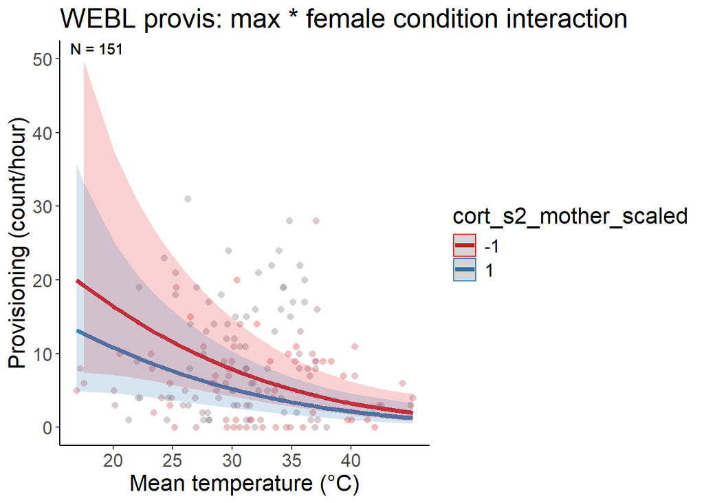

```r
mean_temp_webl_q4h2 <- mean(data_webl_q4h2 %>% pull(mean_temp))
sd_temp_webl_q4h2 <- sd(data_webl_q4h2 %>% pull(mean_temp))


temp_trans_webl_q4h2 <- trans_new("temp_trans_webl_q4h2",
                             transform = function(x){(x * sd_temp_webl_q4h2) + mean_temp_webl_q4h2},
                             inverse = function(x){x})

(figq4h2_webl <- predict_response(m_webl_q4h2,terms = c("mean_temp_scaled [all]","cort_s2_mother_scaled [-1,1]"),margin = "marginalmeans") %>%
    plot(line_size = 1.5,alpha = .2,show_data = TRUE,limit_range = TRUE) +
    # aes(linetype = .data[["group"]]) +
    theme_classic() +
    # facet_wrap(~ group, ncol = 2) +
    xlab("Mean temperature (\u00b0C)") +
    ylab("Provisioning (count/hour)") +
    # scale_fill_viridis(discrete = TRUE) +
    # scale_color_viridis(discrete = TRUE) +
    theme(text = element_text(size = 16)) +
    labs(title =  "WEBL provis: max * female condition interaction") +
    scale_x_continuous(trans = temp_trans_webl_q4h2,
                       breaks = c((20-mean_temp_webl_q4h2)/sd_temp_webl_q4h2,
                                  (25-mean_temp_webl_q4h2)/sd_temp_webl_q4h2,
                                  (30-mean_temp_webl_q4h2)/sd_temp_webl_q4h2,
                                  (35-mean_temp_webl_q4h2)/sd_temp_webl_q4h2,
                                  (40-mean_temp_webl_q4h2)/sd_temp_webl_q4h2),
                       # breaks = c(20,30,40,50),
                       # labels = c("20","30","40","50"),
                       # limits = c((15-mean(g$meanmaxtempI,na.rm = TRUE))/sd(g$meanmaxtempI,na.rm = TRUE),
                       #            (55-mean(g$meanmaxtempI,na.rm = TRUE))/sd(g$meanmaxtempI,na.rm = TRUE))
                       # limits = c(18,5)
    ) +
    # scale_linetype_manual(values = c("Forest" = "solid","Orchard" = "dashed","Grassland" = "solid","Row crop" = "dotted")) +
    ylim(0,50) +
    geom_text(data = dat_text_webl_q4h2, mapping = aes(x = -Inf, y = Inf,label = label),hjust = -.2, vjust = 1.2,inherit.aes = FALSE) #+
    # theme(legend.position = "none")
)
```

```r
ggsave("../figures/provisbymaxtempxhab_WEBL_q4h2.png",plot =  figq4h2_webl, width = 10, height = 6.6)
```

Females with higher s2 provision less in general, but the interaction is not significant.

### TRES

```r
m_TRES <- glmmTMB(valid_detections ~ poly(mean_temp_scaled,2) * cort_s2_mother_scaled + poly(tod_h_scaled,2) + mean_nestling_age_scaled + brood_size_scaled + year_fct + (1|site/attempt_id),
           family = nbinom2(),
           #ziformula = ~ 1,
           data = dplyr::filter(p,!is.na(mean_temp),
                                !is.na(cort_s2_mother),
                                  # !is.na(julian_date),
                                  !is.na(mean_nestling_age),
                                  !is.na(brood_size),
                                  !is.na(tod_h),
                                  !is.na(site),
                                  !is.na(attempt_id),
                                  !is.na(year),
                                  species == "TRES"# ,
                                                # tod >= hms::as.hms('11:00:00', tz = "America/Los_Angeles"),
                                                # tod_end <= hms::as.hms('17:00:00',tz = "America/Los_Angeles"),
                                                # tod_end >= hms::as.hms('11:00:00', tz = "America/Los_Angeles")
                                                ) %>%
                        mutate(across(c(tod_h,mean_temp,cort_s2_mother,julian_date,mean_nestling_age,brood_size),
                                                    ~ scale(.x)[,1],
                                                    .names = "{.col}_scaled")),
           )

m_TRES_linint <- glmmTMB(valid_detections ~ mean_temp_scaled * cort_s2_mother_scaled + poly(mean_temp_scaled,degree = 2) + poly(tod_h_scaled,2) + mean_nestling_age_scaled + brood_size_scaled + year_fct + (1|site/attempt_id),
           family = nbinom2(),
           #ziformula = ~ 1,
           data = dplyr::filter(p,!is.na(mean_temp),
                                !is.na(cort_s2_mother),
                                  # !is.na(julian_date),
                                  !is.na(mean_nestling_age),
                                  !is.na(brood_size),
                                  !is.na(tod_h),
                                  !is.na(site),
                                  !is.na(attempt_id),
                                  !is.na(year),
                                  species == "TRES"# ,
                                                # tod >= hms::as.hms('11:00:00', tz = "America/Los_Angeles"),
                                                # tod_end <= hms::as.hms('17:00:00',tz = "America/Los_Angeles"),
                                                # tod_end >= hms::as.hms('11:00:00', tz = "America/Los_Angeles")
                                                ) %>%
                        mutate(across(c(tod_h,mean_temp,cort_s2_mother,julian_date,mean_nestling_age,brood_size),
                                                    ~ scale(.x)[,1],
                                                    .names = "{.col}_scaled")),
           )
```

```
## dropping columns from rank-deficient conditional model: poly(mean_temp_scaled, degree = 2)1
```

```r
m_TRES_noint <- glmmTMB(valid_detections ~ cort_s2_mother_scaled + poly(mean_temp_scaled,degree = 2) + poly(tod_h_scaled,2) + mean_nestling_age_scaled + brood_size_scaled + year_fct + (1|site/attempt_id),
           family = nbinom2(),
           #ziformula = ~ 1,
           data = dplyr::filter(p,!is.na(mean_temp),
                                !is.na(cort_s2_mother),
                                  # !is.na(julian_date),
                                  !is.na(mean_nestling_age),
                                  !is.na(brood_size),
                                  !is.na(tod_h),
                                  !is.na(site),
                                  !is.na(attempt_id),
                                  !is.na(year),
                                  species == "TRES"# ,
                                                # tod >= hms::as.hms('11:00:00', tz = "America/Los_Angeles"),
                                                # tod_end <= hms::as.hms('17:00:00',tz = "America/Los_Angeles"),
                                                # tod_end >= hms::as.hms('11:00:00', tz = "America/Los_Angeles")
                                                ) %>%
                        mutate(across(c(tod_h,mean_temp,cort_s2_mother,julian_date,mean_nestling_age,brood_size),
                                                    ~ scale(.x)[,1],
                                                    .names = "{.col}_scaled")),
           )




c <- anova(m_TRES,m_TRES_linint,m_TRES_noint) %>% tibble() %>% mutate(Model = c("No temp * LC interaction","Linear temp * LC interaction","Squared temp * LC interaction"),.before = Df)

(tab <- c %>%
  as.tibble() %>%
  mutate(across(where(is.numeric),~round(.x,digits = 4)),
         P = `Pr(>Chisq)`) %>%
  dplyr::select(Model,AIC,Chisq,P) %>%
  mutate(across(c(AIC,Chisq), ~ round(.x, digits = 2)),
         P = if_else(P < 0.001,"<0.001",as.character(P))) %>% gt())
```

| Model | AIC | Chisq | P |
| --- | --- | --- | --- |
| No temp * LC interaction | 647.18 | NA | NA |
| Linear temp * LC interaction | 648.25 | 0.93 | 0.3358 |
| Squared temp * LC interaction | 649.30 | 0.95 | 0.3295 |

```r
gtsave(tab,"../figures/int_tab_provis_ch3_q4h2_tres.html")


summary(m_TRES_noint)
```

```
##  Family: nbinom2  ( log )
## Formula:
## valid_detections ~ cort_s2_mother_scaled + poly(mean_temp_scaled,
##     degree = 2) + poly(tod_h_scaled, 2) + mean_nestling_age_scaled +
##     brood_size_scaled + year_fct + (1 | site/attempt_id)
## Data:
## dplyr::filter(p, !is.na(mean_temp), !is.na(cort_s2_mother), !is.na(mean_nestling_age),
##     !is.na(brood_size), !is.na(tod_h), !is.na(site), !is.na(attempt_id),
##     !is.na(year), species == "TRES") %>% mutate(across(c(tod_h,
##     mean_temp, cort_s2_mother, julian_date, mean_nestling_age,
##     brood_size), ~scale(.x)[, 1], .names = "{.col}_scaled"))
##
##      AIC      BIC   logLik deviance df.resid
##    647.2    679.0   -311.6    623.2       93
##
## Random effects:
##
## Conditional model:
##  Groups          Name        Variance  Std.Dev.
##  attempt_id:site (Intercept) 1.929e+00 1.3888826
##  site            (Intercept) 1.983e-08 0.0001408
## Number of obs: 105, groups:  attempt_id:site, 10; site, 4
##
## Dispersion parameter for nbinom2 family (): 2.84
##
## Conditional model:
##                                     Estimate Std. Error z value Pr(>|z|)
## (Intercept)                          2.08939    0.80352   2.600  0.00931 **
## cort_s2_mother_scaled               -0.10962    0.77441  -0.142  0.88743
## poly(mean_temp_scaled, degree = 2)1  0.89874    2.64086   0.340  0.73362
## poly(mean_temp_scaled, degree = 2)2 -1.54721    0.99503  -1.555  0.11996
## poly(tod_h_scaled, 2)1               0.03818    0.99817   0.038  0.96949
## poly(tod_h_scaled, 2)2               0.95456    1.38340   0.690  0.49019
## mean_nestling_age_scaled            -0.21680    0.10342  -2.096  0.03606 *
## brood_size_scaled                    0.18205    0.69258   0.263  0.79266
## year_fct2023                        -1.03655    1.18307  -0.876  0.38095
## ---
## Signif. codes:  0 '***' 0.001 '**' 0.01 '*' 0.05 '.' 0.1 ' ' 1
```

```r
m_tres_q4h2 <- m_TRES_noint

check_zeroinflation(m_TRES_noint)
```

```
## # Check for zero-inflation
##
##    Observed zeros: 18
##   Predicted zeros: 18
##             Ratio: 1.01
```

```
## Model seems ok, ratio of observed and predicted zeros is within the
##   tolerance range (p = 0.984).
```

```r
(t <- emtrends(m_tres_q4h2,specs = ~ cort_s2_mother_scaled, var = c("mean_temp_scaled"),max.degree = 1) %>% test() %>%
   mutate(across(where(is.numeric), ~ round(.x, digits = 3)),
          df = round(df),
          p.value = if_else(p.value == 0.000,"<0.001",as.character(p.value))) %>%
   rename(`Female condition` = "cort_s2_mother_scaled", `Max temp trend` = "mean_temp_scaled.trend",Df = "df", `Z-ratio` = "z.ratio", P = "p.value") %>%
   #group_by(degree) %>%
   gt())
```

| Female condition | Max temp trend | SE | Df | Z-ratio | P |
| --- | --- | --- | --- | --- | --- |
| 0 | 0.082 | 0.258 | Inf | 0.319 | 0.75 |

```r
joint_tests(m_tres_q4h2)
```

|  | model term | df1 | df2 | F.ratio | Chisq | p.value |
| --- | --- | --- | --- | --- | --- | --- |
| 1 | cort_s2_mother_scaled | 1 | Inf | 0.020 | 0.020 | 0.88743399 |
| 2 | mean_temp_scaled | 1 | Inf | 0.103 | 0.103 | 0.74842820 |
| 3 | tod_h_scaled | 1 | Inf | 0.005 | 0.005 | 0.94451380 |
| 4 | mean_nestling_age_scaled | 1 | Inf | 4.394 | 4.394 | 0.03605505 |
| 5 | brood_size_scaled | 1 | Inf | 0.069 | 0.069 | 0.79265920 |
| 6 | year_fct | 1 | Inf | 0.768 | 0.768 | 0.38094883 |

```r
# gtsave(t,"../figures/tresprovistrend_ch3_q4h2.html")


ss_year_tres_provis <- m_tres_q4h2$frame %>%
  group_by(year_fct) %>%
  summarize(count_ind = n(),count_attempt = n_distinct(attempt_id)) %>%
  rowwise() %>%
  mutate(count = tibble(count_ind,count_attempt)) %>%
  dplyr::select(-c(count_ind, count_attempt)) %>%
  pivot_wider(values_from = count,names_from = year_fct) %>%
  as.tibble() %>%
  ungroup() %>%
  # mutate(`2021` = replace_na(`2021`,list(count_ind = 0,count_attempt = 0))) %>%
  mutate(Total = `2022` + `2023`) %>%
  rowwise() %>%
  mutate(`2022` = paste0(`2022`$count_ind,", ",`2022`$count_attempt),
         `2023` = paste0(`2023`$count_ind,", ",`2023`$count_attempt),
         Total = paste0(Total$count_ind,", ",Total$count_attempt)
  )

(t_ss_year_tres_provis <- ss_year_tres_provis %>% gt() %>%
    grand_summary_rows(fns = list(id = "Total") ~ {
      t <- str_split(.,", ",simplify = TRUE)
      t[,1] %>% as.numeric() %>% sum(na.rm = TRUE) %>% paste(t[,2] %>% as.numeric() %>% sum(na.rm = TRUE),sep = ", ")
    })
)
```

|  | 2022 | 2023 | Total |
| --- | --- | --- | --- |
|  | 45, 4 | 60, 6 | 105, 10 |
| Total | 45, 4 | 60, 6 | 105, 10 |

```r
t_ss_year_tres_provis %>% gtsave("../figures/ss_year_tres_provis_ch3.html")

samp <- m_tres_q4h2$frame %>% summarize(count = n())
samp %>% gt() %>% gtsave("../figures/ss_tres_provis_ch3.html")


dat_text_tres_q4h2 <- data.frame(
  label = paste("N =",samp$count),
  group   = factor(c("Forest","Orchard","Grassland","Row crop"))
)

## num nestboxes
m_tres_q4h2$frame %>% pull(attempt_id) %>% unique() %>% length()
```

```
## [1] 10
```

```
## Data points may overlap. Use the `jitter` argument to add some amount of
##   random variation to the location of data points and avoid overplotting.
```

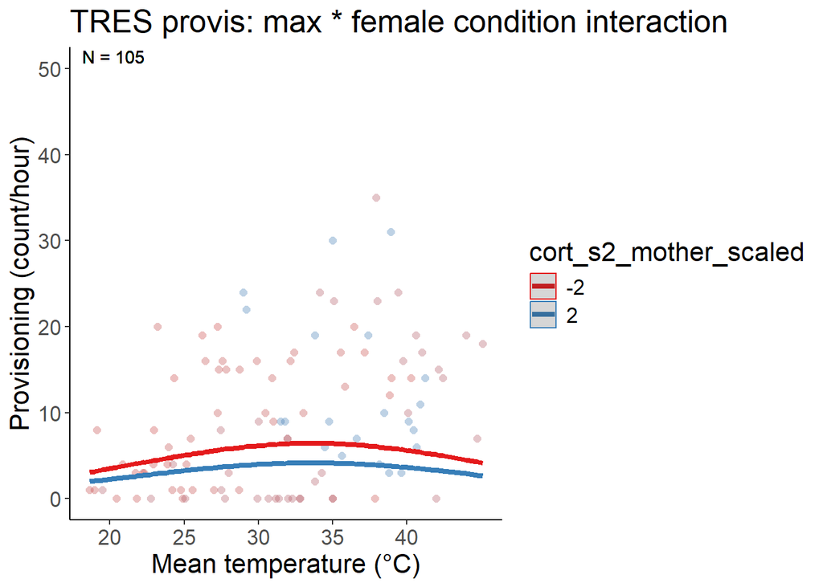

```r
data_tres_q4h2 = dplyr::filter(p,!is.na(mean_temp),
                               !is.na(cort_s2_mother),
                                  # !is.na(julian_date),
                                  !is.na(mean_nestling_age),
                                  !is.na(brood_size),
                                  !is.na(tod_h),
                                  !is.na(site),
                                  !is.na(attempt_id),
                                  !is.na(year),
                                  species == "TRES"# ,
                                                # tod >= hms::as.hms('11:00:00', tz = "America/Los_Angeles"),
                                                # tod_end <= hms::as.hms('17:00:00',tz = "America/Los_Angeles"),
                                                # tod_end >= hms::as.hms('11:00:00', tz = "America/Los_Angeles")
                                                ) %>%
                        mutate(across(c(tod_h,mean_temp,cort_s2_mother,julian_date,mean_nestling_age,brood_size),
                                                    ~ scale(.x)[,1],
                                                    .names = "{.col}_scaled"))


mean_temp_tres_q4h2 <- mean(data_tres_q4h2 %>% pull(mean_temp))
sd_temp_tres_q4h2 <- sd(data_tres_q4h2 %>% pull(mean_temp))


temp_trans_tres_q4h2 <- trans_new("temp_trans_tres_q4h2",
                             transform = function(x){(x * sd_temp_tres_q4h2) + mean_temp_tres_q4h2},
                             inverse = function(x){x})

(figq4h2_tres <- predict_response(m_tres_q4h2,terms = c("mean_temp_scaled [all]","cort_s2_mother_scaled [-2,2]"),margin = "marginalmeans") %>%
    plot(line_size = 1.5,alpha = .2,show_data = TRUE,limit_range = TRUE) +
    # aes(linetype = .data[["group"]]) +
    theme_classic() +
    # facet_wrap(~ group, ncol = 2) +
    xlab("Mean temperature (\u00b0C)") +
    ylab("Provisioning (count/hour)") +
    # scale_fill_viridis(discrete = TRUE) +
    # scale_color_viridis(discrete = TRUE) +
    theme(text = element_text(size = 16)) +
    labs(title =  "TRES provis: max * female condition interaction") +
    scale_x_continuous(trans = temp_trans_tres_q4h2,
                       breaks = c((20-mean_temp_tres_q4h2)/sd_temp_tres_q4h2,
                                  (25-mean_temp_tres_q4h2)/sd_temp_tres_q4h2,
                                  (30-mean_temp_tres_q4h2)/sd_temp_tres_q4h2,
                                  (35-mean_temp_tres_q4h2)/sd_temp_tres_q4h2,
                                  (40-mean_temp_tres_q4h2)/sd_temp_tres_q4h2),
                       # breaks = c(20,30,40,50),
                       # labels = c("20","30","40","50"),
                       # limits = c((15-mean(g$meanmaxtempI,na.rm = TRUE))/sd(g$meanmaxtempI,na.rm = TRUE),
                       #            (55-mean(g$meanmaxtempI,na.rm = TRUE))/sd(g$meanmaxtempI,na.rm = TRUE))
                       # limits = c(18,5)
    ) +
    # scale_linetype_manual(values = c("Forest" = "solid","Orchard" = "dashed","Grassland" = "solid","Row crop" = "dotted")) +
    ylim(0,50) +
    geom_text(data = dat_text_tres_q4h2, mapping = aes(x = -Inf, y = Inf,label = label),hjust = -.2, vjust = 1.2,inherit.aes = FALSE)# +
    #theme(legend.position = "none")
)
```

```r
ggsave("../figures/provisbymaxtempxhab_TRES_q4h2.png",plot =  figq4h2_tres, width = 10, height = 6.6)
```

Provis seems indifferent to cort s2 for TRES, though provis does peak at intermediate temps.

## Q4H3

3. (H3) females with elevated baseline corticosterone concentrations would be more likely to maintain provisioning delivery to nestlings during hot periods after experiencing heat because they have the capacity to upregulate their HPA axis in response to environmental challenges (Mentesana and Hau 2022). Prediction: negative cort * heat now2 * heat term, because expectation is less “peaky” than lower-cort females? Look at this paper: https://besjournals.onlinelibrary.wiley.com/doi/full/10.1111/1365-2656.12843
4. (H4) Females with elevated stress-induced corticosterone concentrations would be less likely to maintain provisioning delivery to nestlings during hot periods after experiencing heat because elevated stress-induced corticosterone may be a sign that females are experiencing their environment as challenging. Prediction: positive cort * heat now2 * heat before term, because expectation is more “peaky” than lower-cort females

### WEBL

```r
m_WEBL <- glmmTMB(valid_detections ~ poly(mean_temp_scaled,2) * deghours_diff_35C_priorday_scaled * cort_s1_mother_scaled + mean_nestling_age_scaled + brood_size_scaled + year_fct +  (1|site:attempt_id),
           family = nbinom2(),
           ziformula = ~ 1,
           data = dplyr::filter(p,!is.na(mean_temp),
                                  # !is.na(julian_date),
                                  !is.na(mean_nestling_age),
                                  !is.na(deghours_diff_35C_priorday),
                                  !is.na(cort_s1_mother),
                                  !is.na(brood_size),
                                  !is.na(tod_h),
                                  !is.na(site),
                                  !is.na(attempt_id),
                                  !is.na(year_fct),
                                  species == "WEBL"# ,
                                                # tod >= hms::as.hms('11:00:00', tz = "America/Los_Angeles"),
                                                # tod_end <= hms::as.hms('17:00:00',tz = "America/Los_Angeles"),
                                                # tod_end >= hms::as.hms('11:00:00', tz = "America/Los_Angeles")
                                                ) %>%
                        mutate(across(c(tod_h,mean_temp,deghours_diff_35C_priorday,cort_s1_mother,julian_date,mean_nestling_age,brood_size),
                                                    ~ scale(.x)[,1],
                                                    .names = "{.col}_scaled")),
           )

m_WEBL_alldoubles <- glmmTMB(valid_detections ~ poly(mean_temp_scaled,2) * deghours_diff_35C_priorday_scaled + poly(mean_temp_scaled,2) * cort_s1_mother_scaled + deghours_diff_35C_priorday_scaled * cort_s1_mother_scaled + mean_nestling_age_scaled + brood_size_scaled + year_fct +  (1|site:attempt_id),
           family = nbinom2(),
           ziformula = ~ 1,
           data = dplyr::filter(p,!is.na(mean_temp),
                                  # !is.na(julian_date),
                                  !is.na(mean_nestling_age),
                                  !is.na(deghours_diff_35C_priorday),
                                  !is.na(cort_s1_mother),
                                  !is.na(brood_size),
                                  !is.na(tod_h),
                                  !is.na(site),
                                  !is.na(attempt_id),
                                  !is.na(year_fct),
                                  species == "WEBL"# ,
                                                # tod >= hms::as.hms('11:00:00', tz = "America/Los_Angeles"),
                                                # tod_end <= hms::as.hms('17:00:00',tz = "America/Los_Angeles"),
                                                # tod_end >= hms::as.hms('11:00:00', tz = "America/Los_Angeles")
                                                ) %>%
                        mutate(across(c(tod_h,mean_temp,deghours_diff_35C_priorday,cort_s1_mother,julian_date,mean_nestling_age,brood_size),
                                                    ~ scale(.x)[,1],
                                                    .names = "{.col}_scaled")),
           )

m_WEBL_deghxfc <- glmmTMB(valid_detections ~ poly(mean_temp_scaled,2) + deghours_diff_35C_priorday_scaled * cort_s1_mother_scaled + mean_nestling_age_scaled + brood_size_scaled + year_fct +  (1|site:attempt_id),
           family = nbinom2(),
           ziformula = ~ 1,
           data = dplyr::filter(p,!is.na(mean_temp),
                                  # !is.na(julian_date),
                                  !is.na(mean_nestling_age),
                                  !is.na(deghours_diff_35C_priorday),
                                  !is.na(cort_s1_mother),
                                  !is.na(brood_size),
                                  !is.na(tod_h),
                                  !is.na(site),
                                  !is.na(attempt_id),
                                  !is.na(year_fct),
                                  species == "WEBL"# ,
                                                # tod >= hms::as.hms('11:00:00', tz = "America/Los_Angeles"),
                                                # tod_end <= hms::as.hms('17:00:00',tz = "America/Los_Angeles"),
                                                # tod_end >= hms::as.hms('11:00:00', tz = "America/Los_Angeles")
                                                ) %>%
                        mutate(across(c(tod_h,mean_temp,deghours_diff_35C_priorday,cort_s1_mother,julian_date,mean_nestling_age,brood_size),
                                                    ~ scale(.x)[,1],
                                                    .names = "{.col}_scaled")),
           )

m_WEBL_mtxdegh <- glmmTMB(valid_detections ~ poly(mean_temp_scaled,2) * deghours_diff_35C_priorday_scaled + cort_s1_mother_scaled + mean_nestling_age_scaled + brood_size_scaled + year_fct +  (1|site:attempt_id),
           family = nbinom2(),
           ziformula = ~ 1,
           data = dplyr::filter(p,!is.na(mean_temp),
                                  # !is.na(julian_date),
                                  !is.na(mean_nestling_age),
                                  !is.na(deghours_diff_35C_priorday),
                                  !is.na(cort_s1_mother),
                                  !is.na(brood_size),
                                  !is.na(tod_h),
                                  !is.na(site),
                                  !is.na(attempt_id),
                                  !is.na(year_fct),
                                  species == "WEBL"# ,
                                                # tod >= hms::as.hms('11:00:00', tz = "America/Los_Angeles"),
                                                # tod_end <= hms::as.hms('17:00:00',tz = "America/Los_Angeles"),
                                                # tod_end >= hms::as.hms('11:00:00', tz = "America/Los_Angeles")
                                                ) %>%
                        mutate(across(c(tod_h,mean_temp,deghours_diff_35C_priorday,cort_s1_mother,julian_date,mean_nestling_age,brood_size),
                                                    ~ scale(.x)[,1],
                                                    .names = "{.col}_scaled")),
           )

m_WEBL_mtxfc <- glmmTMB(valid_detections ~ poly(mean_temp_scaled,2) * cort_s1_mother_scaled + deghours_diff_35C_priorday_scaled + mean_nestling_age_scaled + brood_size_scaled + year_fct +  (1|site:attempt_id),
           family = nbinom2(),
           ziformula = ~ 1,
           data = dplyr::filter(p,!is.na(mean_temp),
                                  # !is.na(julian_date),
                                  !is.na(mean_nestling_age),
                                  !is.na(deghours_diff_35C_priorday),
                                  !is.na(cort_s1_mother),
                                  !is.na(brood_size),
                                  !is.na(tod_h),
                                  !is.na(site),
                                  !is.na(attempt_id),
                                  !is.na(year_fct),
                                  species == "WEBL"# ,
                                                # tod >= hms::as.hms('11:00:00', tz = "America/Los_Angeles"),
                                                # tod_end <= hms::as.hms('17:00:00',tz = "America/Los_Angeles"),
                                                # tod_end >= hms::as.hms('11:00:00', tz = "America/Los_Angeles")
                                                ) %>%
                        mutate(across(c(tod_h,mean_temp,deghours_diff_35C_priorday,cort_s1_mother,julian_date,mean_nestling_age,brood_size),
                                                    ~ scale(.x)[,1],
                                                    .names = "{.col}_scaled")),
           )

m_WEBL_noint <- glmmTMB(valid_detections ~ poly(mean_temp_scaled,2) + deghours_diff_35C_priorday_scaled + cort_s1_mother_scaled + mean_nestling_age_scaled + brood_size_scaled + year_fct +  (1|site:attempt_id),
           family = nbinom2(),
           ziformula = ~ 1,
           data = dplyr::filter(p,!is.na(mean_temp),
                                  # !is.na(julian_date),
                                  !is.na(mean_nestling_age),
                                  !is.na(deghours_diff_35C_priorday),
                                  !is.na(cort_s1_mother),
                                  !is.na(brood_size),
                                  !is.na(tod_h),
                                  !is.na(site),
                                  !is.na(attempt_id),
                                  !is.na(year_fct),
                                  species == "WEBL"# ,
                                                # tod >= hms::as.hms('11:00:00', tz = "America/Los_Angeles"),
                                                # tod_end <= hms::as.hms('17:00:00',tz = "America/Los_Angeles"),
                                                # tod_end >= hms::as.hms('11:00:00', tz = "America/Los_Angeles")
                                                ) %>%
                        mutate(across(c(tod_h,mean_temp,deghours_diff_35C_priorday,cort_s1_mother,julian_date,mean_nestling_age,brood_size),
                                                    ~ scale(.x)[,1],
                                                    .names = "{.col}_scaled")),
           )

c <- anova(m_WEBL,m_WEBL_alldoubles,m_WEBL_mtxdegh,m_WEBL_deghxfc,m_WEBL_mtxfc) %>% tibble() %>% mutate(Model = c("Degree-hour * female condition","Mean temp * Degree-hour","Mean temp * female condition","All double interactions","Triple interaction"),.before = Df)

(tab <- c %>%
  as.tibble() %>%
  mutate(across(where(is.numeric),~round(.x,digits = 4)),
         P = `Pr(>Chisq)`) %>%
  dplyr::select(Model,AIC,Chisq,P) %>%
  mutate(across(c(AIC,Chisq), ~ round(.x, digits = 2)),
         P = if_else(P < 0.001,"<0.001",as.character(P))) %>% gt())
```

| Model | AIC | Chisq | P |
| --- | --- | --- | --- |
| Degree-hour * female condition | 810.12 | NA | NA |
| Mean temp * Degree-hour | 814.95 | 0.00 | 1 |
| Mean temp * female condition | 808.64 | 6.30 | <0.001 |
| All double interactions | 794.56 | 20.08 | <0.001 |
| Triple interaction | 795.50 | 3.07 | 0.216 |

```r
gtsave(tab,"../figures/int_tab_provis_ch3_q4h3_webl_1.html")

c <- anova(m_WEBL_alldoubles,m_WEBL_mtxfc) %>% tibble() %>% mutate(Model = c("Mean temp * Degree-hour","All double interactions"),.before = Df)

(tab <- c %>%
  as.tibble() %>%
  mutate(across(where(is.numeric),~round(.x,digits = 4)),
         P = `Pr(>Chisq)`) %>%
  dplyr::select(Model,AIC,Chisq,P) %>%
  mutate(across(c(AIC,Chisq), ~ round(.x, digits = 2)),
         P = if_else(P < 0.001,"<0.001",as.character(P))) %>% gt())
```

[output not shown]